# STA 141 A Project

# 3 Part 1: Exploratory Data Analysis and Data Integration

First, I wanted to get a sense of the data structures in the file.

```r
getwd()
```

```
## [1] "/Users/davisavantika/Downloads"
```

```r
setwd("/Users/davisavantika")
session=list()
for(i in 1:18){
  session[[i]]=readRDS(paste("~/Code/STA141AProject/Data/session",i,'.rds',sep=''))
   #print(session[[i]]$mouse_name)
   #print(session[[i]]$date_exp)
}

 # ls(session[[1]])

n.session=length(session) # 18

meta <- tibble(
  mouse_name = rep('name', n.session),
  date_exp = rep('dt', n.session),
  number_brain_areas = rep(0,n.session),
  number_neurons = rep(0,n.session),
  number_trials = rep(0,n.session),
  success_rate = rep(0,n.session)
)

for(i in 1:n.session){
  tmp = session[[i]];
  meta[i,1]=tmp$mouse_name;
  meta[i,2]=tmp$date_exp;
  meta[i,3]=length(unique(tmp$brain_area)); # find number of unique values --> unique brain areas
  meta[i,4]=dim(tmp$spks[[1]])[1];
  meta[i,5]=length(tmp$feedback_type);
  meta[i,6]=mean(tmp$feedback_type+1)/2; # success rate


}

meta.df <- as.data.frame(meta)

colnames(meta.df) <- c('Mouse Name', 'Experiment Date', "Number of Brain Areas", "Number of Neurons", "Number of Trials", "Success Rate")

kable(meta.df, format = "html", table.attr = "class='table table-striped'", digits=2, align = 'c') %>%
 kableExtra::kable_styling(position = "center")
```

| Mouse Name | Experiment Date | Number of Brain Areas | Number of Neurons | Number of Trials | Success Rate |
| --- | --- | --- | --- | --- | --- |
| Cori | 2016-12-14 | 8 | 734 | 114 | 0.61 |
| Cori | 2016-12-17 | 5 | 1070 | 251 | 0.63 |
| Cori | 2016-12-18 | 11 | 619 | 228 | 0.66 |
| Forssmann | 2017-11-01 | 11 | 1769 | 249 | 0.67 |
| Forssmann | 2017-11-02 | 10 | 1077 | 254 | 0.66 |
| Forssmann | 2017-11-04 | 5 | 1169 | 290 | 0.74 |
| Forssmann | 2017-11-05 | 8 | 584 | 252 | 0.67 |
| Hench | 2017-06-15 | 15 | 1157 | 250 | 0.64 |
| Hench | 2017-06-16 | 12 | 788 | 372 | 0.69 |
| Hench | 2017-06-17 | 13 | 1172 | 447 | 0.62 |
| Hench | 2017-06-18 | 6 | 857 | 342 | 0.80 |
| Lederberg | 2017-12-05 | 12 | 698 | 340 | 0.74 |
| Lederberg | 2017-12-06 | 15 | 983 | 300 | 0.80 |
| Lederberg | 2017-12-07 | 10 | 756 | 268 | 0.69 |
| Lederberg | 2017-12-08 | 8 | 743 | 404 | 0.76 |
| Lederberg | 2017-12-09 | 6 | 474 | 280 | 0.72 |
| Lederberg | 2017-12-10 | 6 | 565 | 224 | 0.83 |
| Lederberg | 2017-12-11 | 10 | 1090 | 216 | 0.81 |

This dataset contains 18 sessions. Each session contains within it the data of several variables: mouse name, date of experiment, left contrast, right contrast, feedback type, brain area, spikes, and time.

The left contrast, right contrast, feedback type, time, and spikes variables have the same length. This indicates that for a given contrast combination, the feedback type and the neural spike activity vs time was recorded.

Looking closer at the spike data, each contrast combination resulted in the spike activity being documented over the number of neurons analyzed and over time. The number of neurons matches the length of the brain area data, as each neuron is classified by its brain area.

This table also demonstrates that different sessions of the same mouse have different numbers of brain areas and neurons fired. This is an interesting finding, as one would assume that the same replicated experiment would fire the same number of neurons and the same brain areas would be activated in the same mouse.

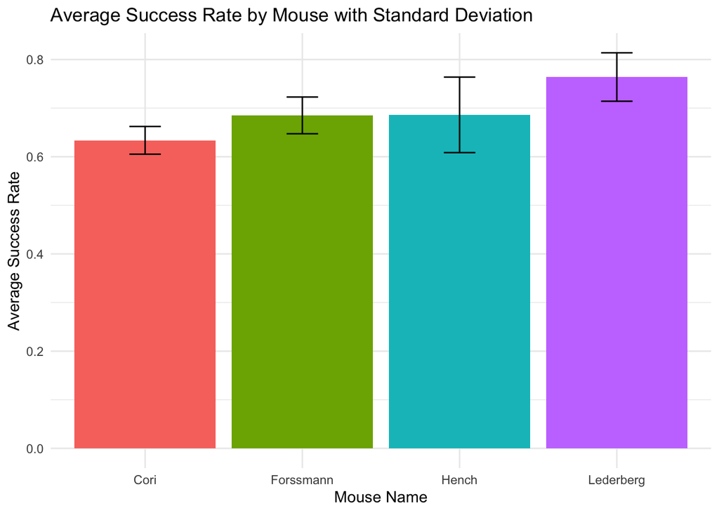

```r
# Calculate mean and standard deviation for each mouse
mouse_stats <- aggregate(success_rate ~ mouse_name, data = meta,
                        FUN = function(x) c(mean = mean(x), sd = sd(x)))
mouse_stats <- do.call(data.frame, mouse_stats)

# Create a bar plot with error bars
ggplot(mouse_stats, aes(x = mouse_name, y = success_rate.mean, fill = mouse_name)) +
  geom_bar(stat = "identity") +
  geom_errorbar(aes(ymin = success_rate.mean - success_rate.sd,
                   ymax = success_rate.mean + success_rate.sd),
                width = 0.2) +
  labs(title = "Average Success Rate by Mouse with Standard Deviation",
       x = "Mouse Name",
       y = "Average Success Rate") +
  theme_minimal() +
  theme(legend.position = "none")
```

We see that the average success rate in this experiment differs by mouse. Lederberg has the highest average success and Cori has the lowest average success. However, it is important to note that the sessions are not equally distributed by mouse. Cori only has 3 sessions worth of data, while Lederberg has 7 sessions worth of data.

## 3.1 Patterns in one session data

I first wanted to look at one session’s data to explore how the different variables’ data seems to correlate with feedback score.

### 3.1.1 Average Spike Count

One problem that immediately jumps out is that we are given the spike data for each neuron in a given trial across 40 time points. This makes it difficult to draw trends and associations from this two dimensional data. Instead, I wanted to use a summary statistic to condense all of the spike data over time into one value. I chose to use average spike count across time as this summary statistic.

Next, I wanted to see if average spike count was correlated in any way with feedback score. I chose to plot this over brain areas.

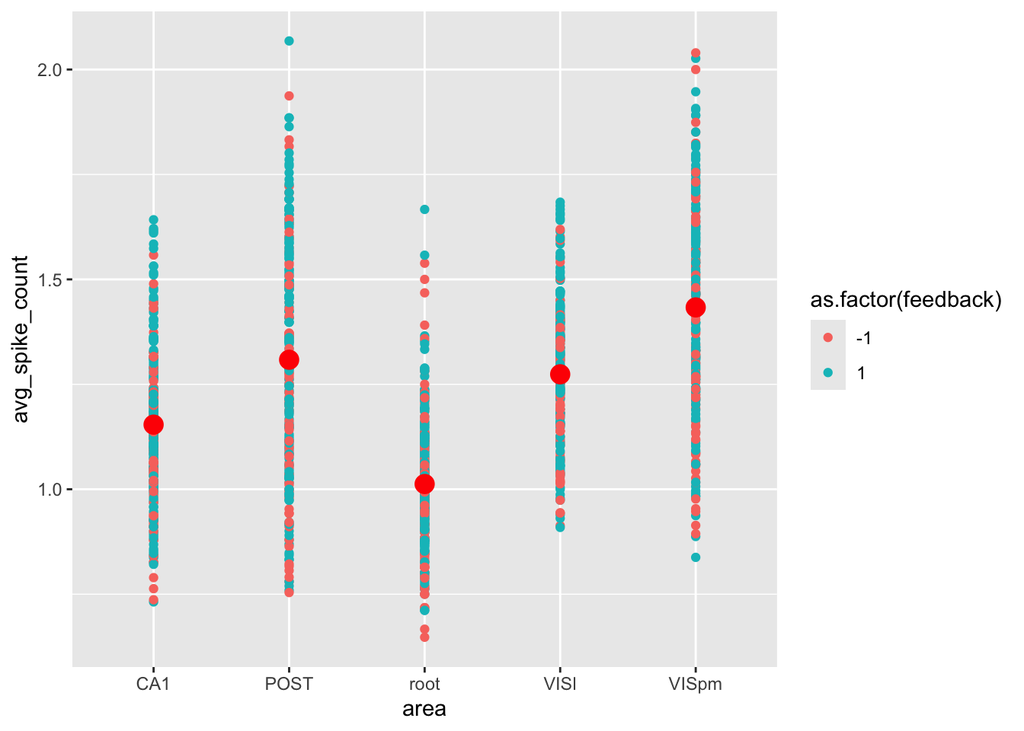

```r
average_spike_area<-function(i.t, this_session){

  spk.trial = this_session$spks[[i.t]]
  area = this_session$brain_area
  spk.count = apply(spk.trial,1,sum)  # sum up num of spikes by rows in the matrix
  spk.average.tapply = tapply(spk.count, area, mean)  # average of spks across neurons in that same area
  return(spk.average.tapply)

}

i.s = 2
  n.trial=length(session[[i.s]]$feedback_type)
  n.area=length(unique(session[[i.s]]$brain_area ))
  trial.summary = matrix(nrow=n.trial,ncol= n.area+1+2+1)

  for(i.t in 1:n.trial){
    trial.summary[i.t,]=c(average_spike_area(i.t,this_session = session[[i.s]]),
                            session[[i.s]]$feedback_type[i.t],
                          session[[i.s]]$contrast_left[i.t],
                          session[[i.s]]$contrast_right[i.t],
                          # session[[i.s]]$spks[i.t],
                          i.t)
  }

colnames(trial.summary)=c(names(average_spike_area(i.t,this_session = session[[i.s]])), 'feedback', 'left_contrast','right_contrast', 'id' )

trial.summary <- as.data.frame(as_tibble(na.omit(trial.summary)))

# Pivot the data to create data tables we can use for visualization
trial.summary.stacked = trial.summary %>% pivot_longer(!c("feedback", "left_contrast", "right_contrast", "id"), names_to = "area", values_to = "avg_spike_count")

ggplot(trial.summary.stacked, aes(x = area,
                       y = avg_spike_count,
                       color = as.factor(feedback))) +
                      geom_point() +
                      stat_summary(fun = mean,
                                   geom = "point",
                                   size = 4,
                                   color = "red")
```

This data frame demonstrates the average spike count in each brain region and in each trial of session 2. The graph shows us that there there is a difference between spike count and brain area.

### 3.1.2 Contrast Level

I wanted to look at the intersection between contrast level and average spike count across the trials of one session.

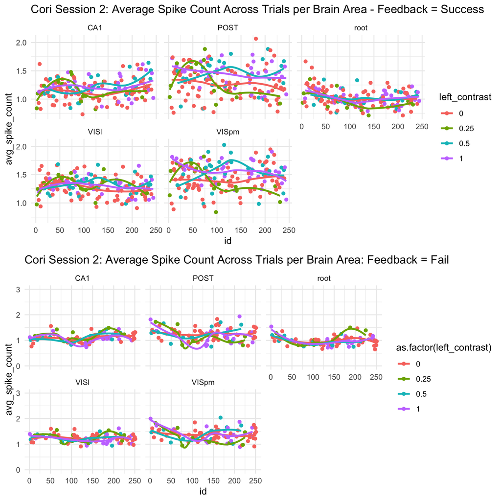

```r
# MAKE THIS BETTER, ADD IN RIGHT CONTRAST

trial.summary.stacked.success <- trial.summary.stacked %>% filter(feedback == '1')

trial.summary.stacked.fail <- trial.summary.stacked %>% filter(feedback == '-1')

trial.summary.stacked.success$left_contrast <-   as.factor(trial.summary.stacked.success$left_contrast)
trial.summary.stacked.success$right_contrast <-   as.factor(trial.summary.stacked.success$right_contrast)

trial.summary.stacked.fail$left_contrast <- as.factor(trial.summary.stacked.fail$left_contrast)
trial.summary.stacked.fail$right_contrast <-   as.factor(trial.summary.stacked.fail$right_contrast)
# Create the graphs

# trial.summary.stacked.success.scatter <- ggplot(trial.summary.stacked.success, aes(x = id, y = avg_spike_count)) +
#                                            geom_point() +
#                                            geom_smooth()+
#                                            labs(title = "Cori Session 2: Average Spike Count Across Trials per Brain Area - Feedback = Success",
#                                                 fill = "Left Contrast level") +
#                                            facet_wrap(~ area)
#
# trial.summary.stacked.fail.scatter <- ggplot(trial.summary.stacked.fail, aes(x = id, y = avg_spike_count)) +
#                                            geom_point() +
#                                            geom_smooth()+
#                                            labs(title = "Cori Session 2: Average Spike Count Across Trials per Brain Area - Feedback = Fail",
#                                                 fill = "Left Contrast level")+
#                                            facet_wrap(~ area)



trial.summary.stacked.success.scatter.by.left.contrast <- ggplot(trial.summary.stacked.success, aes(x = id, y = avg_spike_count, color = left_contrast)) +
                                           geom_point() +
                                           geom_smooth(se=F)+
                                           labs(title = "Cori Session 2: Average Spike Count Across Trials per Brain Area - Feedback = Success",
                                                fill = "Left Contrast level") +
                                           facet_wrap(~ area) +
                                            theme_minimal()

trial.summary.stacked.fail.scatter.by.left.contrast <- ggplot(trial.summary.stacked.fail, aes(x = id, y = avg_spike_count, color = as.factor(left_contrast))) +
                                           geom_point() +
                                           geom_smooth(se=F)+
                                           labs(title = "Cori Session 2: Average Spike Count Across Trials per Brain Area: Feedback = Fail",
                                                fill = "Left Contrast level")+
                                           facet_wrap(~ area) +
                                            ylim(0,3) +
                                            theme_minimal()

# grid.arrange(trial.summary.stacked.success.scatter, trial.summary.stacked.fail.scatter)

suppressWarnings(suppressMessages(grid.arrange(trial.summary.stacked.success.scatter.by.left.contrast, trial.summary.stacked.fail.scatter.by.left.contrast)))
```

```r
#
# trial.summary.stacked %>%
#   ggplot() +
#   geom_point(
#     aes(x = id, y = avg_spike_count, color = left_contrast),
#     filter(trial.summary.stacked, feedback == "1"))+
#   scale_color_manual(values=c("blue", "lightblue", "purple", "cyan")) +
#   geom_smooth(se=F)+
#   labs(colour = "Left Contrast") +
#   new_scale_colour() +
#   geom_point(
#     aes(x = id, y = avg_spike_count, color = as.factor(right_contrast)),
#     filter(trial.summary.stacked, name=="1"))+
#   scale_color_manual(values = c("green", "lightgreen", "darkgreen", "darkolivegreen")) +
#   labs(colour = "Right Contrast")
```

## 3.2 Patterns in the aggergate data

### 3.2.1 Average Spike Count

I wanted to further investigate the average spike count data in the aggeragte data.

```r
cori_start = 1
forssmann_start = 4
hench_start = 8
lederberg_start = 12
next_guy = 0

for(i in 1:18){

  if (i >= cori_start & i < forssmann_start){
    name = "cori"
    start_index = 1
    second_index = start_index + 1
    next_guy = 4
    final_index = next_guy - 1
    }

  if (i >= forssmann_start & i < hench_start){
    name = "forssmann"
    start_index = 4
    second_index = start_index + 1
    next_guy = 8
    final_index = next_guy - 1


    }

  if (i >= hench_start & i < lederberg_start){
    name = "hench"
    start_index = 8
    second_index = start_index + 1
    next_guy = 12
    final_index = next_guy - 1

    }

  if (i >= lederberg_start){
    name = "lederberg"
    start_index = 12
    second_index = start_index + 1
    next_guy = 19
    final_index = next_guy - 1

    }

  for(i.s in (start_index):final_index){

    n.trial=length(session[[i.s]]$feedback_type)
    n.area=length(unique(session[[i.s]]$brain_area ))
    trial.summary = matrix(nrow=n.trial,ncol= n.area+1+2+1)

      for(i.t in 1:n.trial){
        trial.summary[i.t,]=c(average_spike_area(i.t,this_session = session[[i.s]]),
                              session[[i.s]]$feedback_type[i.t],
                            session[[i.s]]$contrast_left[i.t],
                            session[[i.s]]$contrast_right[i.t],

                            i.t
                          )
        }



      colnames(trial.summary)=c(names(average_spike_area(i.t , this_session = session[[i.s]])),
                                        'feedback', 'leftcontrast','rightcontrast','trial' )

      dynamic.trial.summary <- as.data.frame(as_tibble(na.omit(trial.summary)))


      dynamic.df <- dynamic.trial.summary %>% pivot_longer(!c("feedback", 'leftcontrast','rightcontrast','trial'), names_to = "brain_area", values_to = "avg_spike_count")

      dynamic.df$session <- i.s
      dynamic.df$name <- name

      assign(paste(name, i.s, "trial_summary_long", sep = "_"), dynamic.df)

      # trial.summary.long(name, i.s, dynamic.trial.summary)
        # merge.trials <- as.data.frame(matrix(0, nrow = n.trials, ncol = (4 + n.area))
        # merge.trials <- merge(dynamic.trial.summary, merge.trials, by = "Var1", all = TRUE)
      assign(paste(name, "trial_summary_session", i.s, sep = "_"), dynamic.trial.summary)



  }

    i = i + 1

}

cori_merged <- bind_rows(cori_1_trial_summary_long, cori_2_trial_summary_long, cori_3_trial_summary_long)

forssmann_merged <- bind_rows(forssmann_4_trial_summary_long, forssmann_5_trial_summary_long, forssmann_6_trial_summary_long, forssmann_7_trial_summary_long)

hench_merged <- bind_rows(hench_8_trial_summary_long, hench_9_trial_summary_long, hench_10_trial_summary_long, hench_11_trial_summary_long)

lederberg_merged <- bind_rows(lederberg_12_trial_summary_long, lederberg_13_trial_summary_long, lederberg_14_trial_summary_long, lederberg_15_trial_summary_long, lederberg_16_trial_summary_long, lederberg_17_trial_summary_long, lederberg_18_trial_summary_long)

results_df_allsessions <- bind_rows(cori_merged, hench_merged, lederberg_merged, forssmann_merged)

results_df_allsessions$contrastdiff <- (results_df_allsessions$rightcontrast - results_df_allsessions$leftcontrast)

head(results_df_allsessions)
```

```
## # A tibble: 6 × 9
##   feedback leftcontrast rightcontrast trial brain_area avg_spike_count session
##      <dbl>        <dbl>         <dbl> <dbl> <chr>                <dbl>   <int>
## 1        1            0           0.5     1 ACA                  1.27        1
## 2        1            0           0.5     1 CA3                  1.53        1
## 3        1            0           0.5     1 DG                   2.32        1
## 4        1            0           0.5     1 LS                   1.94        1
## 5        1            0           0.5     1 MOs                  0.938       1
## 6        1            0           0.5     1 root                 0.5         1
## # ℹ 2 more variables: name <chr>, contrastdiff <dbl>
```

I combined all of the trials of the entire dataset into a new dataframe called results_df_allsessions.

I then wanted to see if there was a correlation between average spike count and the other variables, such as feedback score.

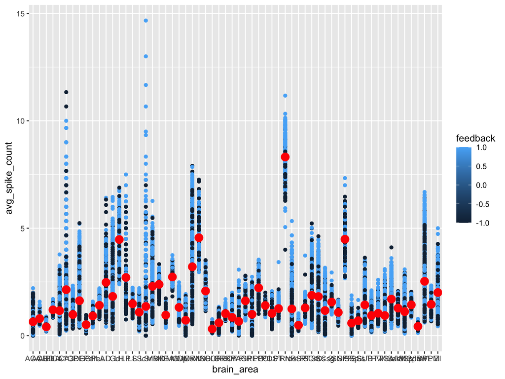

```r
#FINISH Make this look better
ggplot(results_df_allsessions, aes(x = brain_area,
                       y = avg_spike_count,
                       color = feedback)) +
                  geom_point() +
                  stat_summary(fun = mean, geom = "point", size = 4, color = "red")
```

This graph collects the results across all sessions to identify the spike rate of different brain areas. The aggregate data also demonstrates certain brain areas with higher spike counts than other areas.

Using this data, I will do further investigation to understand whether higher average spike rates in these brain areas have any correlation with response success. I hypothesize currently that higher spike rates may lead to increased response success.

### 3.2.2 Average Spike Count vs Feedback Score

Before looking at how to integrate brain area, I also wanted to look at how average spike count might be influenced by feedback.

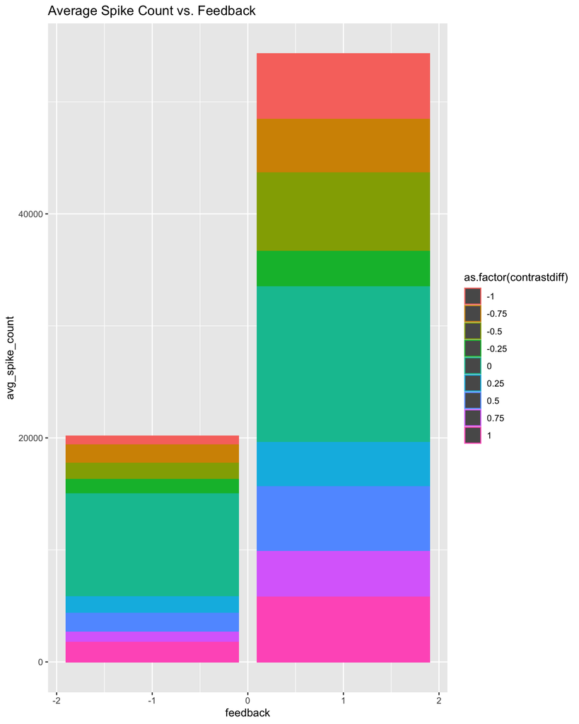

```r
avg_spike_count_vs_feedback <- ggplot(results_df_allsessions, aes(x = feedback,
                                   y = avg_spike_count,
                              color = as.factor(contrastdiff)))+
                              geom_bar(stat = "identity") +
                             labs(title = "Average Spike Count vs. Feedback",
                                 xlab = "Feedback: Success = 1 Fail = -1",
                                fill = "Contrast Difference")

print(avg_spike_count_vs_feedback)
```

### 3.2.3 T-test for Spike Count vs Feedback Score

I next wanted to conduct a statistical test to validate this hypothesized correlation of average spike count and feedback:

```r
# Compute mean feedback per brain area
feedback_summary <- results_df_allsessions %>%
  group_by(brain_area, feedback) %>%
  summarize(mean_spike = mean(avg_spike_count, na.rm = TRUE), .groups = "drop") %>%
  spread(feedback, mean_spike)  # Convert feedback categories into separate columns

# Compute difference between max and min feedback means
feedback_summary <- feedback_summary %>%
  mutate(feedback_diff = apply(dplyr::select(., -brain_area), 1, function(x) max(x, na.rm = TRUE) - min(x, na.rm = TRUE))) %>% arrange(desc(by = feedback_diff))

# Find the brain area with the largest difference
largest_diff_brain_area <- feedback_summary %>%
  arrange(desc(feedback_diff)) %>%
  head(1)

# Perform paired t-test
result <- t.test(feedback_summary$`-1`, feedback_summary$`1`, paired = TRUE)

# Print the result
print(result)
```

```
##
##  Paired t-test
##
## data:  feedback_summary$`-1` and feedback_summary$`1`
## t = -6.6408, df = 61, p-value = 9.564e-09
## alternative hypothesis: true mean difference is not equal to 0
## 95 percent confidence interval:
##  -0.16080352 -0.08637526
## sample estimates:
## mean difference
##      -0.1235894
```

```r
# If you want to see the p-value specifically
print(paste("p-value:", result$p.value))
```

```
## [1] "p-value: 9.56354427391337e-09"
```

I conducted a paired t-test to see if there was a statistically significant difference in average spike count between successful and unsuccessful trials across all brain areas recorded in this dataset. The paired t-test yielded a p-value of 9.564e-09. If we set a threshold of 0.05, we see that the p-value is significant. This indicates that there is a statistically significant difference in average spike count between successful and unsuccessful trials. This tells us that average spike count is an indicator of success/failure, and should be included in our prediction model.

### 3.2.4 Contrast Difference

*Proportion of Contrast Combinations Within Data*

I became curious about the distributions of contrast combinations within the data.

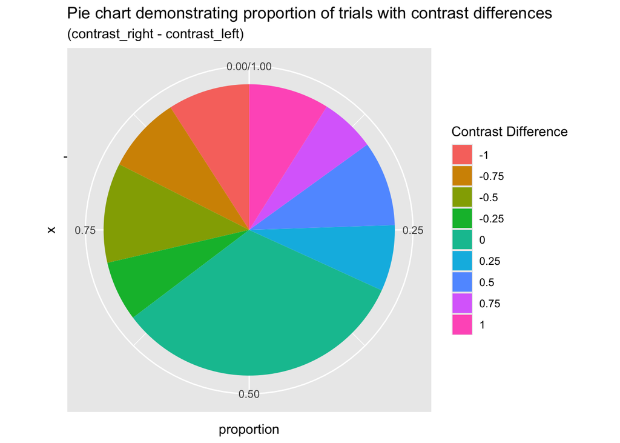

```r
contrastdiff_counts <- results_df_allsessions %>%
  ungroup() %>%
  mutate(contrastdiff = as.numeric(as.character(contrastdiff))) %>%
  count(contrastdiff) %>%
  mutate(proportion = n / sum(n))



contrastdiff_counts$sign <- ifelse(contrastdiff_counts$contrastdiff < 0, "negative",
                       ifelse(contrastdiff_counts$contrastdiff > 0, "positive", "zero"))


ggplot(contrastdiff_counts, mapping=aes(x = "", y = proportion, fill = factor(contrastdiff))) + geom_bar(stat = "identity", width = 1) +
  coord_polar(theta = "y") + labs(title = "Pie chart demonstrating proportion of trials with contrast differences", subtitle= "(contrast_right - contrast_left)", fill="Contrast Difference")
```

A contrast_diff value of 0 can come from two methods. One scenario is when both left and right contrasts are 0. Another scenario is when left and right contrasts are equal, but non-zero.

The constrast_diff value of 0 is particularly important for me to consider in regards to prediction power in further steps of this assignment. Given that the mouse’s actions in the second case do not have a bearing on the success of the trial, it stands out as different compared to other trials. Thus, including this data may be problematic to overall predictions.

“When left and right contrasts are equal but non-zero, left or right will be randomly chosen (50%) as the correct choice.”

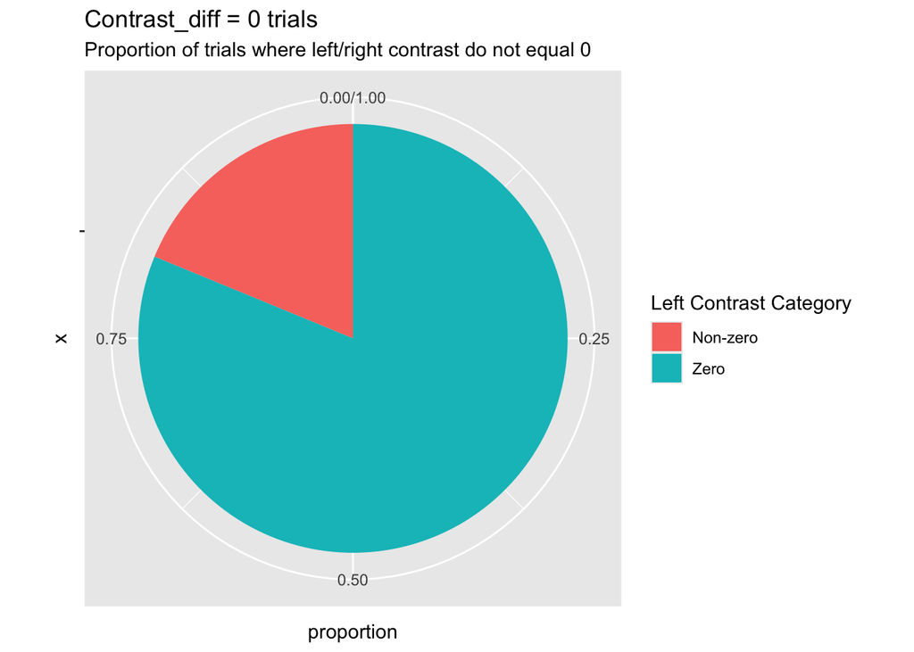

```r
zero_contrast_diff <- results_df_allsessions %>%
  filter(contrastdiff == 0) %>%
  ungroup %>%
  mutate(left_contrast_category = ifelse(leftcontrast != 0, "Non-zero", "Zero")) %>%
  count(left_contrast_category) %>%
  mutate(proportion = n / sum(n))

ggplot(zero_contrast_diff, mapping=aes(x = "", y = proportion, fill = factor(left_contrast_category))) + geom_bar(stat = "identity", width = 1) +
  coord_polar(theta = "y") + labs(title = "Contrast_diff = 0 trials", subtitle= "Proportion of trials where left/right contrast do not equal 0", fill="Left Contrast Category")
```

I chose to investigate the trials where contrast_diff = 0 in more detail, in order to understand how many of these trials involve both left contrast and right contrast being 0 versus the left contrast and right contrast having equivalent but non-zero values. In the second case, if right contrast and left contrast are equal but non-zero, their difference (contrast_diff) will equal 0. I chose to look at the left contrast values, comparing the instances where left contrast = 0 versus instances where left contrast did not equal 0.

As I mentioned previously, this distinction is important because the mouse’s behavior in the first scenario truly yields a success/failure based on the mouse’s decision, while the second scenario yields a success/failure randomly. Therefore, I wanted to see what proportion of trials where contrast_diff = 0 came from each scenario.

The analysis demonstrates that around 80% of trials where contrast_diff = 0 come from the first scenario, where the left and right contrasts were both 0, and the mouse either successfully held the wheel still or incorrectly moved the wheel.

20% of trials were instances of the left and right contrasts being equal but non-zero. This means that 0.32896102 * 0.1877473 = 0.06176154 (6.17%) of all trials had feedbacks that were randomly assigned, rather than being correlated with the mouse’s behavior. This is a relatively small proportion of the total data, but is important to note when I build my prediction model.

### 3.2.5 Chi Square test on Contrast Difference vs Feedback Score

*Chi-Square Test: Contrast Difference vs. Feedback Score*

I wanted to more rigorously explore the possible influences of contrast difference on feedback score independent of brain area. So I conducted a chi-square test to determind if contrast difference had an effect on feedback score.

I considered feedback and contrast scores to be categorical variables since they fall into distinct bins. Since I was comparing two categorical variables I used a chi-square test to determine if there was a significant association betwen the contrast and the feedback score.

Null Hypothesis (H0): There is not a significant association between the variable and the feedback score.

Alternative Hypothesis (H1): There is a significant association between the variable and the feedback score.

```r
# https://www.datacamp.com/tutorial/chi-square-test-r #FINISH add to works ited
# https://discourse.gohugo.io/t/centre-align-r-markdown-kable-table/25810


# Select the columns of interest
selected_data <- results_df_allsessions %>% dplyr::select(feedback, avg_spike_count, rightcontrast, leftcontrast, brain_area, contrastdiff)

# Create a contingency table for Highest educational level and Anemia level
contingency_table_area <- table(selected_data$feedback, selected_data$brain_area)

contingency_table_right_contrast <- table(selected_data$feedback, selected_data$rightcontrast)
contingency_table_left_contrast <- table(selected_data$feedback, selected_data$leftcontrast)
contingency_table_average_spike_counts <- table(selected_data$feedback, selected_data$avg_spike_count)
contingency_table_contrast_difference <- table(selected_data$feedback, selected_data$contrastdiff)

# Perform chi-square test
chi_square_test_area <- chisq.test(contingency_table_area)
# chi_square_test_average_spike_counts <- chisq.test(contingency_table_right_contrast)
chi_square_test_left_contrast <- chisq.test(contingency_table_left_contrast)
chi_square_test_right_contrast <- chisq.test(contingency_table_average_spike_counts)
chi_square_test_contrast_difference <- chisq.test(contingency_table_contrast_difference)

# View the results

# print(chi_square_test_area)
# print(chi_square_test_average_spike_counts) #add to an actual table

chi.square.contrast.table <- as.data.frame(matrix(0, nrow = 3, ncol = 3))
colnames(chi.square.contrast.table) <- c('X-squared', 'p-value', 'Degrees of Freedom')
rownames(chi.square.contrast.table) <- c('Left Contrast', 'Right Contrast', 'Constrast Difference')

# print(chi_square_test_contrast_difference)

chi.square.contrast.table[1,1] <- chi_square_test_left_contrast$statistic
chi.square.contrast.table[2,1] <- chi_square_test_right_contrast$statistic
chi.square.contrast.table[3,1] <- chi_square_test_contrast_difference$statistic

chi.square.contrast.table[1,2] <- chi_square_test_left_contrast$p.value
chi.square.contrast.table[2,2] <- chi_square_test_right_contrast$p.value
chi.square.contrast.table[3,2] <- chi_square_test_contrast_difference$p.value

chi.square.contrast.table[1,3] <- chi_square_test_left_contrast$parameter
chi.square.contrast.table[2,3] <- chi_square_test_right_contrast$parameter
chi.square.contrast.table[3,3] <- chi_square_test_contrast_difference$parameter

kable(chi.square.contrast.table, format = "html", table.attr = "class='table table-striped'",caption = "Chi-Square Test: Contrast vs. Feedback", digits = 30, align = 'c') %>%
 kableExtra::kable_styling(position = "center")
```

Chi-Square Test: Contrast vs. Feedback

|  | X-squared | p-value | Degrees of Freedom |
| --- | --- | --- | --- |
| Left Contrast | 129.9106 | 5.650000e-28 | 3 |
| Right Contrast | 10334.7490 | 1.122402e-07 | 9600 |
| Constrast Difference | 1338.6604 | 0.000000e+00 | 8 |

I also realized that the contrastdiff variable I made did not distinguish between a combination of right contrast = 1 and left contrast = 0.5, versus another trial where right contrast = 0.5 and left contrast = 0. I wanted to make this distinction by using an interaction variable instead. I then conducted a chi-square test to see whether this new interaction variable of right_contrast x left_contrast had a significant correlation with feedback score.

### 3.2.6 Interaction Between Left and Right Contrasts and Chi-Square Test between Contrast Level Interaction vs. Feedback Score

```r
#CITE https://www.google.com/search?q=color+by+two+columns+geom+point&oq=color+by+two+columns+geom+point&gs_lcrp=EgRlZGdlKgYIABBFGDkyBggAEEUYOTIKCAEQABiiBBiJBTIHCAIQABjvBTIHCAMQABjvBTIKCAQQABiABBiiBNIBCDY0MDlqMWo0qAIAsAIA&sourceid=chrome&ie=UTF-8

results_df_allsessions$contrastinteraction <- interaction(results_df_allsessions$rightcontrast, results_df_allsessions$leftcontrast, sep = '_')
```

*Chi-Square Test: Contrast Level Interaction vs. Feedback Score*

Null Hypothesis (H0): There is not a significant association between the contrast level interaction and the feedback score.

Alternative Hypothesis (H1): There is a significant association between the contrast level interaction and the feedback score.

```r
# Select the columns of interest
selected_data <- results_df_allsessions %>% dplyr::select(feedback, contrastinteraction)

# Create a contingency table for Highest educational level and Anemia level
contingency_table_contrastinteraction <- table(selected_data$feedback, selected_data$contrastinteraction)

# Perform chi-square test
chi_square_test_contrastinteraction <- chisq.test(contingency_table_contrast_difference)

# View the results

chi.square.interaction.table <- as.data.frame(matrix(0, nrow = 1, ncol = 3))
colnames(chi.square.interaction.table) <- c('X-squared', 'p-value', 'Degrees of Freedom')
rownames(chi.square.interaction.table) <- c('Interaction')

# print(chi_square_test_contrast_difference)

chi.square.interaction.table[1,1] <- chi_square_test_contrastinteraction$statistic
chi.square.interaction.table[1,2] <- chi_square_test_contrastinteraction$p.value
chi.square.interaction.table[1,3] <- chi_square_test_contrastinteraction$parameter

kable(chi.square.interaction.table, format = "html", table.attr = "class='table table-striped'",caption = "Chi-Square Test: Contrast vs. Feedback", digits = 40, align = 'c') %>%
 kableExtra::kable_styling(position = "center")
```

Chi-Square Test: Contrast vs. Feedback

|  | X-squared | p-value | Degrees of Freedom |
| --- | --- | --- | --- |
| Interaction | 1338.66 | 0 | 8 |

## 3.3 PCA on Neuron Spikes

### 3.3.1 PCA on Raw Spike Data

I now want to conduct PCA on the average spike data for each session. I want to do this in order to reduce the number of dimensions needed to account for brain area spike count data into my prediction model, as the EDA section illustrated that spike count seems to be correlated with feedback score. Since the brain areas are not common across all sessions, I wanted to use PCA to uncover hidden patterns in the data while reducing the complexity of the neuron data set.

```r
results_df_allsessions <- results_df_allsessions %>% ungroup()
colnames(results_df_allsessions)[colnames(results_df_allsessions) == "name"] <- "mousename"
#
#
# First check if spks has elements
if (length(session[[1]]$spks) == 0) {
  cat("The spks list is empty\n")
} else {
  # Check if any elements have length > 0
  element_lengths <- sapply(session[[1]]$spks, length)

  if (all(element_lengths == 0)) {
    cat("All elements in spks are empty\n")
  } else {
    cat("Found non-empty elements in spks. Continuing with matrix creation...\n")


# Proceed with the original code
    n_trials <- length(session[[1]]$spks)
    max_length <- max(element_lengths)

    cat("Number of trials:", n_trials, "\n")
    cat("Max length of spike vectors:", max_length, "\n")

    spike_matrix <- matrix(0, nrow = n_trials, ncol = max_length)

    # Fill the matrix with spike data - more robustly
    for (i in 1:n_trials) {
      if (length(session[[1]]$spks[[i]]) > 0) {
        spk_data <- session[[1]]$spks[[i]]
        spike_matrix[i, 1:length(spk_data)] <- spk_data
      }
    }

    # Check if the matrix has any non-zero values
    if (all(spike_matrix == 0)) {
      cat("Warning: Spike matrix contains only zeros\n")
    } else {
      # Check column variances
      col_vars <- apply(spike_matrix, 2, var)
      non_zero_vars <- sum(col_vars > 0)
#
      cat("Columns with non-zero variance:", non_zero_vars, "out of", ncol(spike_matrix), "\n")

      if (non_zero_vars >= 2) {
        # Keep only columns with variance
        spike_matrix_filtered <- spike_matrix[, col_vars > 0, drop = FALSE]
        cat("Running PCA on filtered matrix with dimensions:", dim(spike_matrix_filtered), "\n")

        # Run PCA
        pca_result <- prcomp(spike_matrix_filtered, scale = TRUE)
        print(summary(pca_result))
      } else {
        cat("Not enough columns with variance for PCA\n")
      }
    }
  }
}
```

```
## Found non-empty elements in spks. Continuing with matrix creation...
## Number of trials: 114
## Max length of spike vectors: 29360
## Columns with non-zero variance: 20245 out of 29360
## Running PCA on filtered matrix with dimensions: 114 20245
## Importance of components:
##                            PC1     PC2     PC3      PC4      PC5      PC6
## Standard deviation     18.9829 17.3668 16.5939 16.20672 15.71244 15.56907
## Proportion of Variance  0.0178  0.0149  0.0136  0.01297  0.01219  0.01197
## Cumulative Proportion   0.0178  0.0327  0.0463  0.05927  0.07147  0.08344
##                             PC7      PC8      PC9    PC10     PC11     PC12
## Standard deviation     15.51296 15.39542 15.30814 15.2609 15.19649 15.13565
## Proportion of Variance  0.01189  0.01171  0.01158  0.0115  0.01141  0.01132
## Cumulative Proportion   0.09533  0.10703  0.11861  0.1301  0.14152  0.15284
##                            PC13     PC14    PC15     PC16     PC17     PC18
## Standard deviation     15.10102 15.02430 14.9937 14.95911 14.79660 14.76213
## Proportion of Variance  0.01126  0.01115  0.0111  0.01105  0.01081  0.01076
## Cumulative Proportion   0.16410  0.17525  0.1864  0.19741  0.20822  0.21899
##                            PC19     PC20     PC21     PC22     PC23     PC24
## Standard deviation     14.74497 14.70776 14.66871 14.49767 14.43400 14.40012
## Proportion of Variance  0.01074  0.01069  0.01063  0.01038  0.01029  0.01024
## Cumulative Proportion   0.22973  0.24041  0.25104  0.26142  0.27171  0.28196
##                            PC25     PC26     PC27     PC28    PC29     PC30
## Standard deviation     14.30496 14.28694 14.19765 14.12797 14.0885 14.02462
## Proportion of Variance  0.01011  0.01008  0.00996  0.00986  0.0098  0.00972
## Cumulative Proportion   0.29206  0.30215  0.31210  0.32196  0.3318  0.34148
##                            PC31     PC32     PC33    PC34     PC35     PC36
## Standard deviation     13.97285 13.94823 13.92183 13.8677 13.84153 13.78790
## Proportion of Variance  0.00964  0.00961  0.00957  0.0095  0.00946  0.00939
## Cumulative Proportion   0.35112  0.36073  0.37031  0.3798  0.38927  0.39866
##                            PC37     PC38     PC39     PC40     PC41    PC42
## Standard deviation     13.76733 13.74590 13.74001 13.71132 13.67009 13.6444
## Proportion of Variance  0.00936  0.00933  0.00933  0.00929  0.00923  0.0092
## Cumulative Proportion   0.40802  0.41736  0.42668  0.43597  0.44520  0.4544
##                            PC43     PC44     PC45     PC46     PC47     PC48
## Standard deviation     13.58826 13.55600 13.51164 13.44545 13.41550 13.37795
## Proportion of Variance  0.00912  0.00908  0.00902  0.00893  0.00889  0.00884
## Cumulative Proportion   0.46351  0.47259  0.48161  0.49054  0.49943  0.50827
##                            PC49    PC50     PC51     PC52     PC53     PC54
## Standard deviation     13.37137 13.3466 13.31865 13.28993 13.23209 13.20354
```

[output cut: 27 more lines]

```
## Standard deviation     12.14648 12.10215 12.0759 12.04877 11.94895 11.91851
## Proportion of Variance  0.00729  0.00723  0.0072  0.00717  0.00705  0.00702
## Cumulative Proportion   0.85412  0.86135  0.8686  0.87572  0.88278  0.88979
##                            PC97     PC98     PC99    PC100    PC101   PC102
## Standard deviation     11.85597 11.79582 11.78677 11.74240 11.66023 11.6454
## Proportion of Variance  0.00694  0.00687  0.00686  0.00681  0.00672  0.0067
## Cumulative Proportion   0.89674  0.90361  0.91047  0.91728  0.92400  0.9307
##                           PC103    PC104   PC105    PC106    PC107    PC108
## Standard deviation     11.58044 11.54290 11.4729 11.41892 11.36460 11.28782
## Proportion of Variance  0.00662  0.00658  0.0065  0.00644  0.00638  0.00629
## Cumulative Proportion   0.93732  0.94390  0.9504  0.95684  0.96322  0.96952
##                           PC109    PC110    PC111    PC112    PC113     PC114
## Standard deviation     11.24446 11.17072 11.13746 11.04443 10.94857 6.501e-13
## Proportion of Variance  0.00625  0.00616  0.00613  0.00603  0.00592 0.000e+00
## Cumulative Proportion   0.97576  0.98193  0.98805  0.99408  1.00000 1.000e+00
```

```r
# Create a function to analyze a single session
analyze_session_pca <- function(session_data, session_id) {
  # First check if spks has elements
  if (length(session_data$spks) == 0) {
    cat("Session", session_id, ": The spks list is empty\n")
    return(list(success = FALSE, message = "The spks list is empty"))
  }

  # Check if any elements have length > 0
  element_lengths <- sapply(session_data$spks, length)

  if (all(element_lengths == 0)) {
    cat("Session", session_id, ": All elements in spks are empty\n")
    return(list(success = FALSE, message = "All elements in spks are empty"))
  }

  cat("Session", session_id, ": Found non-empty elements in spks. Continuing with matrix creation...\n")

  # Proceed with the original code
  n_trials <- length(session_data$spks)
  max_length <- max(element_lengths)

  cat("  Number of trials:", n_trials, "\n")
  cat("  Max length of spike vectors:", max_length, "\n")

  spike_matrix <- matrix(0, nrow = n_trials, ncol = max_length)

  # Fill the matrix with spike data - more robustly
  for (i in 1:n_trials) {
    if (length(session_data$spks[[i]]) > 0) {
      spk_data <- session_data$spks[[i]]
      spike_matrix[i, 1:length(spk_data)] <- spk_data
    }
  }

  # Check if the matrix has any non-zero values
  if (all(spike_matrix == 0)) {
    cat("  Warning: Spike matrix contains only zeros\n")
    return(list(success = FALSE, message = "Spike matrix contains only zeros"))
  }

  # Check column variances
  col_vars <- apply(spike_matrix, 2, var)
  non_zero_vars <- sum(col_vars > 0)

  cat("  Columns with non-zero variance:", non_zero_vars, "out of", ncol(spike_matrix), "\n")

  if (non_zero_vars >= 2) {
    # Keep only columns with variance
    spike_matrix_filtered <- spike_matrix[, col_vars > 0, drop = FALSE]
    cat("  Running PCA on filtered matrix with dimensions:", dim(spike_matrix_filtered), "\n")

    # Run PCA
    tryCatch({
      pca_result <- prcomp(spike_matrix_filtered, scale = TRUE)

      # Calculate variance explained
      var_explained <- pca_result$sdev^2 / sum(pca_result$sdev^2)
      cumulative_var <- cumsum(var_explained)

      # Number of PCs for different thresholds
      pcs_90 <- min(which(cumulative_var >= 0.9))
      if (is.infinite(pcs_90)) pcs_90 <- length(var_explained)

      pcs_95 <- min(which(cumulative_var >= 0.95))
      if (is.infinite(pcs_95)) pcs_95 <- length(var_explained)

      pcs_99 <- min(which(cumulative_var >= 0.99))
      if (is.infinite(pcs_99)) pcs_99 <- length(var_explained)

      pcs_100 <- length(var_explained)

      cat("  PCs for 90% variance:", pcs_90, "\n")
      cat("  PCs for 95% variance:", pcs_95, "\n")
      cat("  PCs for 99% variance:", pcs_99, "\n")
      cat("  PCs for 100% variance:", pcs_100, "\n")

      return(list(
        success = TRUE,
        session_id = session_id,
        n_trials = n_trials,
        n_features = non_zero_vars,
        pcs_90 = pcs_90,
        pcs_95 = pcs_95,
        pcs_99 = pcs_99,
        pcs_100 = pcs_100,
        var_explained = var_explained
      ))
    }, error = function(e) {
      cat("  Error in PCA:", e$message, "\n")
      return(list(success = FALSE, message = paste("Error in PCA:", e$message)))
    })
  } else {
    cat("  Not enough columns with variance for PCA\n")
    return(list(success = FALSE, message = "Not enough columns with variance for PCA"))
  }
}

# Process all 18 sessions
results <- list()
for (i in 1:18) {
  cat("\nAnalyzing session", i, "\n")

  # Check if session exists
  if (exists(paste0("session", i)) || exists("session") && length(session) >= i) {
    # Get the correct session data
    if (exists(paste0("session", i))) {
      session_data <- get(paste0("session", i))
    } else {
      session_data <- session[[i]]
    }

    # Analyze the session
    result <- analyze_session_pca(session_data, i)
    results[[as.character(i)]] <- result
  } else {
    cat("Session", i, "data not found\n")
    results[[as.character(i)]] <- list(success = FALSE, message = "Session data not found")
  }
}
```

```
##
## Analyzing session 1
## Session 1 : Found non-empty elements in spks. Continuing with matrix creation...
##   Number of trials: 114
##   Max length of spike vectors: 29360
##   Columns with non-zero variance: 20245 out of 29360
##   Running PCA on filtered matrix with dimensions: 114 20245
##   PCs for 90% variance: 98
##   PCs for 95% variance: 105
##   PCs for 99% variance: 112
##   PCs for 100% variance: 114
##
## Analyzing session 2
## Session 2 : Found non-empty elements in spks. Continuing with matrix creation...
##   Number of trials: 251
##   Max length of spike vectors: 42800
##   Columns with non-zero variance: 34213 out of 42800
##   Running PCA on filtered matrix with dimensions: 251 34213
##   PCs for 90% variance: 217
##   PCs for 95% variance: 233
##   PCs for 99% variance: 247
##   PCs for 100% variance: 251
##
## Analyzing session 3
## Session 3 : Found non-empty elements in spks. Continuing with matrix creation...
##   Number of trials: 228
##   Max length of spike vectors: 24760
##   Columns with non-zero variance: 18166 out of 24760
##   Running PCA on filtered matrix with dimensions: 228 18166
##   PCs for 90% variance: 197
##   PCs for 95% variance: 211
##   PCs for 99% variance: 224
##   PCs for 100% variance: 228
##
## Analyzing session 4
## Session 4 : Found non-empty elements in spks. Continuing with matrix creation...
##   Number of trials: 249
##   Max length of spike vectors: 70760
##   Columns with non-zero variance: 51893 out of 70760
##   Running PCA on filtered matrix with dimensions: 249 51893
```

[output cut: 143 more lines]

```
##   PCs for 90% variance: 192
##   PCs for 95% variance: 207
##   PCs for 99% variance: 220
##   PCs for 100% variance: 224
##
## Analyzing session 18
## Session 18 : Found non-empty elements in spks. Continuing with matrix creation...
##   Number of trials: 216
##   Max length of spike vectors: 43600
##   Columns with non-zero variance: 29147 out of 43600
##   Running PCA on filtered matrix with dimensions: 216 29147
##   PCs for 90% variance: 185
##   PCs for 95% variance: 199
##   PCs for 99% variance: 212
##   PCs for 100% variance: 216
```

```r
# Create summary table
summary_table <- data.frame(
  Session = integer(),
  NumTrials = integer(),
  NumFeatures = integer(),
  PCs_90_percent = integer(),
  PCs_95_percent = integer(),
  PCs_99_percent = integer(),
  PCs_100_percent = integer()
)

for (session_id in names(results)) {
  result <- results[[session_id]]
  if (result$success) {
    summary_table <- rbind(summary_table, data.frame(
      Session = as.integer(session_id),
      NumTrials = result$n_trials,
      NumFeatures = result$n_features,
      PCs_90_percent = result$pcs_90,
      PCs_95_percent = result$pcs_95,
      PCs_99_percent = result$pcs_99,
      PCs_100_percent = result$pcs_100
    ))
  } else {
    # Add a row with NA values for failed sessions
    summary_table <- rbind(summary_table, data.frame(
      Session = as.integer(session_id),
      NumTrials = NA,
      NumFeatures = NA,
      PCs_90_percent = NA,
      PCs_95_percent = NA,
      PCs_99_percent = NA,
      PCs_100_percent = NA
    ))
  }
}

# Sort by session and print
summary_table <- summary_table[order(summary_table$Session), ]

# Calculate percentage of features needed
summary_table$Percent_PCs_90 <- (summary_table$PCs_90_percent / summary_table$NumFeatures) * 100
summary_table$Percent_PCs_95 <- (summary_table$PCs_95_percent / summary_table$NumFeatures) * 100
summary_table$Percent_PCs_99 <- (summary_table$PCs_99_percent / summary_table$NumFeatures) * 100
summary_table$Percent_PCs_100 <- (summary_table$PCs_100_percent / summary_table$NumFeatures) * 100


kable(summary_table, format = "html", table.attr = "class='table table-striped'", digits=2, align = 'c') %>%
 kableExtra::kable_styling(position = "center")
```

| Session | NumTrials | NumFeatures | PCs_90_percent | PCs_95_percent | PCs_99_percent | PCs_100_percent | Percent_PCs_90 | Percent_PCs_95 | Percent_PCs_99 | Percent_PCs_100 |
| --- | --- | --- | --- | --- | --- | --- | --- | --- | --- | --- |
| 1 | 114 | 20245 | 98 | 105 | 112 | 114 | 0.48 | 0.52 | 0.55 | 0.56 |
| 2 | 251 | 34213 | 217 | 233 | 247 | 251 | 0.63 | 0.68 | 0.72 | 0.73 |
| 3 | 228 | 18166 | 197 | 211 | 224 | 228 | 1.08 | 1.16 | 1.23 | 1.26 |
| 4 | 249 | 51893 | 213 | 230 | 245 | 249 | 0.41 | 0.44 | 0.47 | 0.48 |
| 5 | 254 | 31168 | 214 | 233 | 249 | 254 | 0.69 | 0.75 | 0.80 | 0.81 |
| 6 | 290 | 33859 | 247 | 267 | 285 | 290 | 0.73 | 0.79 | 0.84 | 0.86 |
| 7 | 252 | 17903 | 213 | 231 | 247 | 252 | 1.19 | 1.29 | 1.38 | 1.41 |
| 8 | 250 | 36220 | 215 | 231 | 245 | 250 | 0.59 | 0.64 | 0.68 | 0.69 |
| 9 | 372 | 24657 | 321 | 345 | 366 | 372 | 1.30 | 1.40 | 1.48 | 1.51 |
| 10 | 447 | 36139 | 376 | 408 | 438 | 447 | 1.04 | 1.13 | 1.21 | 1.24 |
| 11 | 342 | 23445 | 277 | 306 | 333 | 342 | 1.18 | 1.31 | 1.42 | 1.46 |
| 12 | 340 | 21601 | 293 | 315 | 334 | 340 | 1.36 | 1.46 | 1.55 | 1.57 |
| 13 | 300 | 33427 | 259 | 279 | 295 | 300 | 0.77 | 0.83 | 0.88 | 0.90 |
| 14 | 268 | 20364 | 231 | 249 | 263 | 268 | 1.13 | 1.22 | 1.29 | 1.32 |
| 15 | 404 | 24410 | 348 | 375 | 397 | 404 | 1.43 | 1.54 | 1.63 | 1.66 |
| 16 | 280 | 14062 | 239 | 258 | 275 | 280 | 1.70 | 1.83 | 1.96 | 1.99 |
| 17 | 224 | 16438 | 192 | 207 | 220 | 224 | 1.17 | 1.26 | 1.34 | 1.36 |
| 18 | 216 | 29147 | 185 | 199 | 212 | 216 | 0.63 | 0.68 | 0.73 | 0.74 |

The session with the smallest number of trials recorded is session 1, with 114 trials. If given the total dataset for session 1, this may not have been the case. However, continuing with the dataset given, another method I thought to deal with the problem of a varying number of PCs per session is to randomly select 114 trials of each session in order to standardize the number of PCs per session. This theoretically should encompass the variability within each session as long as the sample size of 114 is large enough.

### 3.3.2 PCA with Random Sampling

The session with the smallest number of trials recorded is session 1, with 114 trials. If given the total dataset for session 1, this may not have been the case. However, continuing with the dataset given, another method I thought to deal with the problem of a varying number of PCs per session is to randomly select 114 trials of each session in order to standardize the number of PCs per session. This theoretically should encompass the variability within each session as long as the sample size of 114 is large enough.

I randomly sampled 114 trials of each session, conducted PCA on the raw spike data of these trials, and then appended all 114 resulting PCs to my overall dataframe.

```r
# Create a function to analyze a single session with random sampling
analyze_session_pca <- function(session_data, session_id, sample_size = 114) {
  # First check if spks has elements
  if (length(session_data$spks) == 0) {
    cat("Session", session_id, ": The spks list is empty\n")
    return(list(success = FALSE, message = "The spks list is empty"))
  }

  # Check if any elements have length > 0
  element_lengths <- sapply(session_data$spks, length)

  if (all(element_lengths == 0)) {
    cat("Session", session_id, ": All elements in spks are empty\n")
    return(list(success = FALSE, message = "All elements in spks are empty"))
  }

  # Check if we have enough trials for sampling
  n_trials <- length(session_data$spks)
  if (n_trials < sample_size) {
    cat("Session", session_id, ": Not enough trials for sampling (", n_trials, " < ", sample_size, ")\n")
    return(list(success = FALSE, message = paste("Not enough trials for sampling:", n_trials, "<", sample_size)))
  }

  cat("Session", session_id, ": Found non-empty elements in spks. Continuing with matrix creation...\n")

  # Randomly sample trials
  set.seed(42 + session_id)  # Set seed for reproducibility, different for each session
  sampled_indices <- sample(1:n_trials, sample_size)

  cat("  Randomly sampled", sample_size, "trials from", n_trials, "total trials\n")

  # Get element lengths for sampled trials
  sampled_element_lengths <- element_lengths[sampled_indices]
  max_length <- max(sampled_element_lengths)

  cat("  Max length of spike vectors in sample:", max_length, "\n")

  spike_matrix <- matrix(0, nrow = sample_size, ncol = max_length)

  # Fill the matrix with spike data - more robustly
  for (i in 1:sample_size) {
    original_idx <- sampled_indices[i]
    if (length(session_data$spks[[original_idx]]) > 0) {
      spk_data <- session_data$spks[[original_idx]]
      spike_matrix[i, 1:length(spk_data)] <- spk_data
    }
  }

  # Check if the matrix has any non-zero values
  if (all(spike_matrix == 0)) {
    cat("  Warning: Spike matrix contains only zeros\n")
    return(list(success = FALSE, message = "Spike matrix contains only zeros"))
  }

  # Check column variances
  col_vars <- apply(spike_matrix, 2, var)
  non_zero_vars <- sum(col_vars > 0)

  cat("  Columns with non-zero variance:", non_zero_vars, "out of", ncol(spike_matrix), "\n")

  if (non_zero_vars >= 2) {
    # Keep only columns with variance
    spike_matrix_filtered <- spike_matrix[, col_vars > 0, drop = FALSE]
    cat("  Running PCA on filtered matrix with dimensions:", dim(spike_matrix_filtered), "\n")

    # Run PCA
    tryCatch({
      pca_result <- prcomp(spike_matrix_filtered, scale = TRUE)

      # Calculate variance explained
      var_explained <- pca_result$sdev^2 / sum(pca_result$sdev^2)
      cumulative_var <- cumsum(var_explained)

      # Number of PCs for different thresholds
      pcs_90 <- min(which(cumulative_var >= 0.9))
      if (is.infinite(pcs_90)) pcs_90 <- length(var_explained)

      pcs_95 <- min(which(cumulative_var >= 0.95))
      if (is.infinite(pcs_95)) pcs_95 <- length(var_explained)

      pcs_99 <- min(which(cumulative_var >= 0.99))
      if (is.infinite(pcs_99)) pcs_99 <- length(var_explained)

      pcs_100 <- length(var_explained)

      cat("  PCs for 90% variance:", pcs_90, "\n")
      cat("  PCs for 95% variance:", pcs_95, "\n")
      cat("  PCs for 99% variance:", pcs_99, "\n")
      cat("  PCs for 100% variance:", pcs_100, "\n")

      # Extract variance explained by PC1 to PC10 (or as many as available)
      var_pc1_10 <- numeric(10)
      max_pcs <- min(10, length(var_explained))
      var_pc1_10[1:max_pcs] <- var_explained[1:max_pcs] * 100  # Convert to percentage

      return(list(
        success = TRUE,
        session_id = session_id,
        n_trials = sample_size,
        original_n_trials = n_trials,
        n_features = non_zero_vars,
        pcs_90 = pcs_90,
        pcs_95 = pcs_95,
        pcs_99 = pcs_99,
        pcs_100 = pcs_100,
        var_explained = var_explained,
        var_pc1_10 = var_pc1_10
      ))
    }, error = function(e) {
      cat("  Error in PCA:", e$message, "\n")
      return(list(success = FALSE, message = paste("Error in PCA:", e$message)))
    })
  } else {
    cat("  Not enough columns with variance for PCA\n")
    return(list(success = FALSE, message = "Not enough columns with variance for PCA"))
  }
}

# Process all 18 sessions
results <- list()
for (i in 1:18) {
  cat("\nAnalyzing session", i, "\n")

  # Check if session exists
  if (exists(paste0("session", i)) || exists("session") && length(session) >= i) {
    # Get the correct session data
    if (exists(paste0("session", i))) {
      session_data <- get(paste0("session", i))
    } else {
      session_data <- session[[i]]
    }

    # Analyze the session with 114 sampled trials
    result <- analyze_session_pca(session_data, i, sample_size = 114)
    results[[as.character(i)]] <- result
  } else {
    cat("Session", i, "data not found\n")
    results[[as.character(i)]] <- list(success = FALSE, message = "Session data not found")
  }
}
```

```
##
## Analyzing session 1
## Session 1 : Found non-empty elements in spks. Continuing with matrix creation...
##   Randomly sampled 114 trials from 114 total trials
##   Max length of spike vectors in sample: 29360
##   Columns with non-zero variance: 20245 out of 29360
##   Running PCA on filtered matrix with dimensions: 114 20245
##   PCs for 90% variance: 98
##   PCs for 95% variance: 105
##   PCs for 99% variance: 112
##   PCs for 100% variance: 114
##
## Analyzing session 2
## Session 2 : Found non-empty elements in spks. Continuing with matrix creation...
##   Randomly sampled 114 trials from 251 total trials
##   Max length of spike vectors in sample: 42800
##   Columns with non-zero variance: 29052 out of 42800
##   Running PCA on filtered matrix with dimensions: 114 29052
##   PCs for 90% variance: 99
##   PCs for 95% variance: 106
##   PCs for 99% variance: 112
##   PCs for 100% variance: 114
##
## Analyzing session 3
## Session 3 : Found non-empty elements in spks. Continuing with matrix creation...
##   Randomly sampled 114 trials from 228 total trials
##   Max length of spike vectors in sample: 24760
##   Columns with non-zero variance: 16260 out of 24760
##   Running PCA on filtered matrix with dimensions: 114 16260
##   PCs for 90% variance: 99
##   PCs for 95% variance: 106
##   PCs for 99% variance: 112
##   PCs for 100% variance: 114
##
## Analyzing session 4
## Session 4 : Found non-empty elements in spks. Continuing with matrix creation...
##   Randomly sampled 114 trials from 249 total trials
##   Max length of spike vectors in sample: 70760
##   Columns with non-zero variance: 42655 out of 70760
##   Running PCA on filtered matrix with dimensions: 114 42655
```

[output cut: 143 more lines]

```
##   PCs for 90% variance: 98
##   PCs for 95% variance: 105
##   PCs for 99% variance: 112
##   PCs for 100% variance: 114
##
## Analyzing session 18
## Session 18 : Found non-empty elements in spks. Continuing with matrix creation...
##   Randomly sampled 114 trials from 216 total trials
##   Max length of spike vectors in sample: 43600
##   Columns with non-zero variance: 24880 out of 43600
##   Running PCA on filtered matrix with dimensions: 114 24880
##   PCs for 90% variance: 98
##   PCs for 95% variance: 105
##   PCs for 99% variance: 112
##   PCs for 100% variance: 114
```

```r
# Create summary table
summary_table <- data.frame(
  Session = integer(),
  NumTrials = integer(),
  OriginalNumTrials = integer(),
  NumFeatures = integer(),
  PCs_90_percent = integer(),
  PCs_95_percent = integer(),
  PCs_99_percent = integer(),
  PCs_100_percent = integer(),
  # Add columns for variance explained by PC1-PC10
  PC1_var = numeric(),
  PC2_var = numeric(),
  PC3_var = numeric(),
  PC4_var = numeric(),
  PC5_var = numeric(),
  PC6_var = numeric(),
  PC7_var = numeric(),
  PC8_var = numeric(),
  PC9_var = numeric(),
  PC10_var = numeric()
)

for (session_id in names(results)) {
  result <- results[[session_id]]
  if (result$success) {
    # Create a row with basic data
    row_data <- data.frame(
      Session = as.integer(session_id),
      NumTrials = result$n_trials,
      OriginalNumTrials = result$original_n_trials,
      NumFeatures = result$n_features,
      PCs_90_percent = result$pcs_90,
      PCs_95_percent = result$pcs_95,
      PCs_99_percent = result$pcs_99,
      PCs_100_percent = result$pcs_100
    )

    # Add PC1-PC10 variance explained columns
    for (i in 1:10) {
      pc_col_name <- paste0("PC", i, "_var")
      row_data[[pc_col_name]] <- result$var_pc1_10[i]
    }

    # Add to summary table
    summary_table <- rbind(summary_table, row_data)
  } else {
    # Add a row with NA values for failed sessions
    row_data <- data.frame(
      Session = as.integer(session_id),
      NumTrials = NA,
      OriginalNumTrials = NA,
      NumFeatures = NA,
      PCs_90_percent = NA,
      PCs_95_percent = NA,
      PCs_99_percent = NA,
      PCs_100_percent = NA
    )

    # Add NA for PC1-PC10 variance columns
    for (i in 1:10) {
      pc_col_name <- paste0("PC", i, "_var")
      row_data[[pc_col_name]] <- NA
    }

    # Add to summary table
    summary_table <- rbind(summary_table, row_data)
  }
}

# Sort by session and print
summary_table <- summary_table[order(summary_table$Session), ]

# Calculate percentage of features needed
summary_table$Percent_PCs_90 <- (summary_table$PCs_90_percent / summary_table$NumFeatures) * 100
summary_table$Percent_PCs_95 <- (summary_table$PCs_95_percent / summary_table$NumFeatures) * 100
summary_table$Percent_PCs_99 <- (summary_table$PCs_99_percent / summary_table$NumFeatures) * 100
summary_table$Percent_PCs_100 <- (summary_table$PCs_100_percent / summary_table$NumFeatures) * 100


kable(summary_table, format = "html", table.attr = "class='table table-striped'", digits=2, align = 'c') %>%
 kableExtra::kable_styling(position = "center")
```

| Session | NumTrials | OriginalNumTrials | NumFeatures | PCs_90_percent | PCs_95_percent | PCs_99_percent | PCs_100_percent | PC1_var | PC2_var | PC3_var | PC4_var | PC5_var | PC6_var | PC7_var | PC8_var | PC9_var | PC10_var | Percent_PCs_90 | Percent_PCs_95 | Percent_PCs_99 | Percent_PCs_100 |
| --- | --- | --- | --- | --- | --- | --- | --- | --- | --- | --- | --- | --- | --- | --- | --- | --- | --- | --- | --- | --- | --- |
| 1 | 114 | 114 | 20245 | 98 | 105 | 112 | 114 | 1.78 | 1.49 | 1.36 | 1.30 | 1.22 | 1.20 | 1.19 | 1.17 | 1.16 | 1.15 | 0.48 | 0.52 | 0.55 | 0.56 |
| 2 | 114 | 251 | 29052 | 99 | 106 | 112 | 114 | 1.41 | 1.32 | 1.24 | 1.22 | 1.17 | 1.14 | 1.13 | 1.13 | 1.11 | 1.10 | 0.34 | 0.36 | 0.39 | 0.39 |
| 3 | 114 | 228 | 16260 | 99 | 106 | 112 | 114 | 1.52 | 1.25 | 1.19 | 1.15 | 1.14 | 1.13 | 1.12 | 1.11 | 1.09 | 1.08 | 0.61 | 0.65 | 0.69 | 0.70 |
| 4 | 114 | 249 | 42655 | 98 | 106 | 112 | 114 | 2.05 | 1.64 | 1.59 | 1.46 | 1.40 | 1.39 | 1.28 | 1.22 | 1.19 | 1.16 | 0.23 | 0.25 | 0.26 | 0.27 |
| 5 | 114 | 254 | 25561 | 96 | 104 | 112 | 114 | 1.58 | 1.40 | 1.33 | 1.31 | 1.28 | 1.25 | 1.23 | 1.22 | 1.21 | 1.20 | 0.38 | 0.41 | 0.44 | 0.45 |
| 6 | 114 | 290 | 25253 | 98 | 105 | 112 | 114 | 1.83 | 1.54 | 1.50 | 1.36 | 1.26 | 1.22 | 1.22 | 1.20 | 1.18 | 1.17 | 0.39 | 0.42 | 0.44 | 0.45 |
| 7 | 114 | 252 | 14743 | 97 | 105 | 111 | 114 | 1.61 | 1.53 | 1.48 | 1.39 | 1.38 | 1.31 | 1.29 | 1.27 | 1.25 | 1.22 | 0.66 | 0.71 | 0.75 | 0.77 |
| 8 | 114 | 250 | 31628 | 98 | 105 | 112 | 114 | 1.82 | 1.32 | 1.29 | 1.26 | 1.23 | 1.22 | 1.21 | 1.20 | 1.19 | 1.18 | 0.31 | 0.33 | 0.35 | 0.36 |
| 9 | 114 | 372 | 19825 | 99 | 106 | 112 | 114 | 1.51 | 1.28 | 1.27 | 1.24 | 1.20 | 1.15 | 1.12 | 1.12 | 1.10 | 1.08 | 0.50 | 0.53 | 0.56 | 0.58 |
| 10 | 114 | 447 | 26450 | 97 | 105 | 111 | 114 | 1.63 | 1.40 | 1.39 | 1.37 | 1.35 | 1.25 | 1.23 | 1.21 | 1.18 | 1.15 | 0.37 | 0.40 | 0.42 | 0.43 |
| 11 | 114 | 342 | 18527 | 93 | 102 | 111 | 114 | 2.52 | 1.60 | 1.53 | 1.47 | 1.44 | 1.42 | 1.40 | 1.38 | 1.37 | 1.36 | 0.50 | 0.55 | 0.60 | 0.62 |
| 12 | 114 | 340 | 17825 | 99 | 106 | 112 | 114 | 1.36 | 1.33 | 1.26 | 1.20 | 1.17 | 1.15 | 1.14 | 1.13 | 1.12 | 1.10 | 0.56 | 0.59 | 0.63 | 0.64 |
| 13 | 114 | 300 | 29070 | 99 | 106 | 112 | 114 | 1.54 | 1.38 | 1.28 | 1.24 | 1.18 | 1.17 | 1.12 | 1.10 | 1.08 | 1.07 | 0.34 | 0.36 | 0.39 | 0.39 |
| 14 | 114 | 268 | 16406 | 99 | 106 | 112 | 114 | 1.48 | 1.32 | 1.28 | 1.25 | 1.24 | 1.20 | 1.18 | 1.15 | 1.13 | 1.12 | 0.60 | 0.65 | 0.68 | 0.69 |
| 15 | 114 | 404 | 19894 | 99 | 106 | 112 | 114 | 1.57 | 1.25 | 1.19 | 1.18 | 1.11 | 1.10 | 1.07 | 1.07 | 1.06 | 1.06 | 0.50 | 0.53 | 0.56 | 0.57 |
| 16 | 114 | 280 | 11637 | 97 | 105 | 112 | 114 | 1.67 | 1.61 | 1.44 | 1.33 | 1.28 | 1.24 | 1.22 | 1.20 | 1.17 | 1.17 | 0.83 | 0.90 | 0.96 | 0.98 |
| 17 | 114 | 224 | 13948 | 98 | 105 | 112 | 114 | 1.56 | 1.43 | 1.31 | 1.22 | 1.19 | 1.16 | 1.15 | 1.14 | 1.13 | 1.12 | 0.70 | 0.75 | 0.80 | 0.82 |
| 18 | 114 | 216 | 24880 | 98 | 105 | 112 | 114 | 1.84 | 1.57 | 1.46 | 1.40 | 1.36 | 1.33 | 1.24 | 1.20 | 1.15 | 1.12 | 0.39 | 0.42 | 0.45 | 0.46 |

### 3.3.3 Finding Significant PCs

I now want to see how these PCs may correlate with feedback score. I want to see if some PCs have a higher correlation with feedback than others. If some PCs have no correlation with feedback score, then we can ignore them from the prediction model.

```r
# First, let's see how many PCs we need to extract from each session
max_pcs <- 114  # Number of PC columns to create

# Create a function to extract PC scores from a session's PCA result
extract_pc_scores <- function(session_id, pca_result, max_pcs) {
  # Check if the PCA was successful
  if (!pca_result$success) {
    return(NULL)
  }

  # Get the original spike matrix and apply PCA transformation
  session_data <- if (exists(paste0("session", session_id))) {
    get(paste0("session", session_id))
  } else {
    session[[session_id]]
  }

  # Get the sampled indices used for PCA
  set.seed(42 + session_id)  # Same seed used in the analysis
  n_trials <- length(session_data$spks)
  sampled_indices <- sample(1:n_trials, min(114, n_trials))

  # Recreate the spike matrix
  element_lengths <- sapply(session_data$spks, length)
  sampled_element_lengths <- element_lengths[sampled_indices]
  max_length <- max(sampled_element_lengths)

  spike_matrix <- matrix(0, nrow = length(sampled_indices), ncol = max_length)
  for (i in 1:length(sampled_indices)) {
    original_idx <- sampled_indices[i]
    if (length(session_data$spks[[original_idx]]) > 0) {
      spk_data <- session_data$spks[[original_idx]]
      spike_matrix[i, 1:length(spk_data)] <- spk_data
    }
  }

  # Filter columns with zero variance
  col_vars <- apply(spike_matrix, 2, var)
  spike_matrix_filtered <- spike_matrix[, col_vars > 0, drop = FALSE]

  # Apply PCA transformation
  pca_obj <- prcomp(spike_matrix_filtered, scale = TRUE)
  pc_scores <- pca_obj$x

  # Create a data frame with PC scores
  pc_df <- as.data.frame(pc_scores)

  # If we have fewer PCs than max_pcs, fill the rest with NA
  if (ncol(pc_df) < max_pcs) {
    for (i in (ncol(pc_df) + 1):max_pcs) {
      pc_df[[paste0("PC", i)]] <- NA
    }
  }

  # Limit to max_pcs columns
  pc_df <- pc_df[, 1:max_pcs]

  # Add session identifier
  pc_df$session_id <- session_id

  # Add trial identifier - these match the original trial indices
  pc_df$trial_idx <- sampled_indices

  return(pc_df)
}

# Extract PC scores for each session
pc_scores_list <- list()
for (i in 1:18) {
  if (names(results)[i] == as.character(i) && results[[i]]$success) {
    pc_scores <- extract_pc_scores(i, results[[i]], max_pcs)
    if (!is.null(pc_scores)) {
      pc_scores_list[[as.character(i)]] <- pc_scores
    }
  }
}

# Combine all PC scores
all_pc_scores <- do.call(rbind, pc_scores_list)

# Check if results_df_allsessions exists and create it if not
if (!exists("results_df_allsessions")) {
  results_df_allsessions <- data.frame()
}

# Prepare results_df_allsessions by adding any necessary identifiers if it's empty
if (nrow(results_df_allsessions) == 0) {
  # Create a basic structure
  results_df_allsessions <- data.frame(
    session = integer(),
    trial = integer()
  )
}

# Now merge the PC scores with results_df_allsessions


# First make sure column names in all_pc_scores are distinct
colnames(all_pc_scores)[1:max_pcs] <- paste0("PC", 1:max_pcs, "_score")

# Rename session_id and trial_idx for merging
colnames(all_pc_scores)[colnames(all_pc_scores) == "session_id"] <- "session"
colnames(all_pc_scores)[colnames(all_pc_scores) == "trial_idx"] <- "trial"

# Join PC scores with results_df_allsessions
# If results_df_allsessions already has data:
if (nrow(results_df_allsessions) > 0) {
  # Check if columns already exist and remove them if necessary
  existing_pc_cols <- grep("PC[0-9]+_score", colnames(results_df_allsessions))
  if (length(existing_pc_cols) > 0) {
    results_df_allsessions <- results_df_allsessions[, -existing_pc_cols]
  }

  # Merge based on session and trial
  results_df_allsessions <- merge(results_df_allsessions, all_pc_scores,
                                 by = c("session", "trial"),
                                 all.x = TRUE)
} else {
  # If results_df_allsessions is empty, just use the PC scores
  results_df_allsessions <- all_pc_scores
}
#results_df_allsessions
```

### 3.3.4 Pearson Correlation Test to find Siginificant PCs

I am using a Pearson Correlation test to identify which PCs seem to be significantly correlated with feedback score.

```r
# Check that feedback is numeric
if (!is.numeric(results_df_allsessions$feedback)) {
  results_df_allsessions$feedback_numeric <- as.numeric(as.character(results_df_allsessions$feedback))
} else {
  results_df_allsessions$feedback_numeric <- results_df_allsessions$feedback
}

# Calculate correlation between each PC and feedback for all 114 PCs
pc_feedback_correlation <- data.frame(
  PC = character(),
  Correlation = numeric(),
  P_Value = numeric()
)

# Set max_pcs to 114 to analyze all PCs
max_pcs <- 114

# Loop through all PCs
for (i in 1:max_pcs) {
  pc_col <- paste0("PC", i, "_score")

  # Skip if this PC column doesn't exist
  if (!pc_col %in% colnames(results_df_allsessions)) next

  # Calculate correlation
  cor_test <- cor.test(results_df_allsessions[[pc_col]],
                      results_df_allsessions$feedback_numeric,
                      use = "pairwise.complete.obs")

  # Add to results
  pc_feedback_correlation <- rbind(pc_feedback_correlation, data.frame(
    PC = paste0("PC", i),
    Correlation = cor_test$estimate,
    P_Value = cor_test$p.value
  ))
}

# Add significance indicator
pc_feedback_correlation$Significant <- pc_feedback_correlation$P_Value < 0.05

# Sort by absolute correlation strength
pc_feedback_correlation$Abs_Correlation <- abs(pc_feedback_correlation$Correlation)
pc_feedback_correlation <- pc_feedback_correlation[order(pc_feedback_correlation$Abs_Correlation, decreasing = TRUE), ]

kable(pc_feedback_correlation, format = "html", caption = "PC Feedback Correlation") %>%
  kable_styling(bootstrap_options = c("striped", "hover", "condensed", "responsive"),
                full_width = FALSE) %>%
  row_spec(0, bold = TRUE)
```

PC Feedback Correlation

|  | PC | Correlation | P_Value | Significant | Abs_Correlation |
| --- | --- | --- | --- | --- | --- |
| cor106 | PC107 | 0.0707126 | 0.0000000 | TRUE | 0.0707126 |
| cor3 | PC4 | -0.0628301 | 0.0000000 | TRUE | 0.0628301 |
| cor111 | PC112 | 0.0514859 | 0.0000000 | TRUE | 0.0514859 |
| cor6 | PC7 | 0.0499925 | 0.0000000 | TRUE | 0.0499925 |
| cor | PC1 | -0.0426556 | 0.0000000 | TRUE | 0.0426556 |
| cor65 | PC66 | -0.0426334 | 0.0000000 | TRUE | 0.0426334 |
| cor39 | PC40 | 0.0402620 | 0.0000000 | TRUE | 0.0402620 |
| cor103 | PC104 | -0.0391080 | 0.0000000 | TRUE | 0.0391080 |
| cor34 | PC35 | 0.0386128 | 0.0000001 | TRUE | 0.0386128 |
| cor84 | PC85 | 0.0379434 | 0.0000001 | TRUE | 0.0379434 |
| cor40 | PC41 | 0.0373259 | 0.0000002 | TRUE | 0.0373259 |
| cor32 | PC33 | 0.0372488 | 0.0000002 | TRUE | 0.0372488 |
| cor95 | PC96 | -0.0370465 | 0.0000002 | TRUE | 0.0370465 |
| cor36 | PC37 | -0.0363129 | 0.0000004 | TRUE | 0.0363129 |
| cor107 | PC108 | 0.0356487 | 0.0000006 | TRUE | 0.0356487 |
| cor90 | PC91 | -0.0352516 | 0.0000009 | TRUE | 0.0352516 |
| cor75 | PC76 | -0.0346542 | 0.0000013 | TRUE | 0.0346542 |
| cor4 | PC5 | 0.0332872 | 0.0000033 | TRUE | 0.0332872 |
| cor101 | PC102 | -0.0329188 | 0.0000043 | TRUE | 0.0329188 |
| cor15 | PC16 | 0.0329067 | 0.0000043 | TRUE | 0.0329067 |
| cor105 | PC106 | -0.0327694 | 0.0000047 | TRUE | 0.0327694 |
| cor97 | PC98 | -0.0327593 | 0.0000048 | TRUE | 0.0327593 |
| cor2 | PC3 | 0.0326804 | 0.0000050 | TRUE | 0.0326804 |
| cor27 | PC28 | 0.0308355 | 0.0000166 | TRUE | 0.0308355 |
| cor60 | PC61 | -0.0291731 | 0.0000463 | TRUE | 0.0291731 |
| cor110 | PC111 | -0.0274772 | 0.0001246 | TRUE | 0.0274772 |
| cor54 | PC55 | -0.0268681 | 0.0001756 | TRUE | 0.0268681 |
| cor49 | PC50 | -0.0260556 | 0.0002744 | TRUE | 0.0260556 |
| cor37 | PC38 | -0.0254595 | 0.0003779 | TRUE | 0.0254595 |
| cor71 | PC72 | -0.0251508 | 0.0004449 | TRUE | 0.0251508 |

[output cut: 84 more lines]

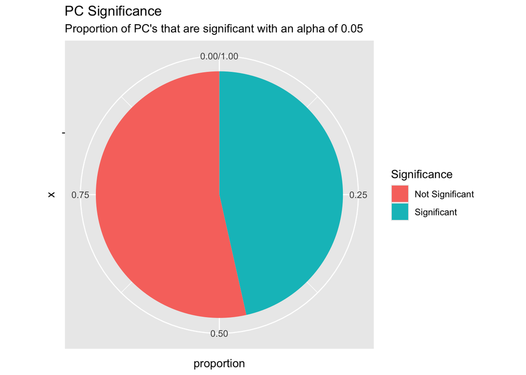

```r
#############################################################################3
pc_feedback_correlation_proportions <- pc_feedback_correlation %>%
  ungroup %>%
  mutate(trues = ifelse(Significant == TRUE, "Significant", "Not Significant")) %>%
  count(trues) %>%
  mutate(proportion = n / sum(n))

pc_feedback_correlation_proportions_chart <- ggplot(pc_feedback_correlation_proportions, aes(x = "",
                                     y = proportion,
                                     fill = factor(trues))) +
                                  geom_bar(stat = "identity", width = 1) +
                                  coord_polar(theta = "y") +
                                  labs(title = "PC Significance",
                                       subtitle= "Proportion of PC's that are significant with an alpha of 0.05",
                                       fill="Significance")

pc_feedback_correlation_proportions_chart
```

This table demonstrates that some PCs have no correlation with feedback, either positively or negatively. The column “Significant” was determined by comparing the P-value of a Pearson Correlation Test to a cutoff value of 0.05. If the p-value of the correlation test was above 0.05, then it was concluded to have no significant correlation with feedback score, and thus does not need to be in our prediction model.

I will now alter the dataframe I will be using for prediction to only have columns for PCs that have a signficant correlation with feedback, as I will only use these in my prediction model. There is no use to include PCs that have no ability to predict feedback score.

### 3.3.5 Final Aggregate Dataframe with Significant PCs

```r
# Assuming pc_feedback_correlation has your correlation results

# Get the names of PCs that are significantly correlated with feedback
significant_pcs <- pc_feedback_correlation$PC[pc_feedback_correlation$Significant == TRUE]

# Convert PC names to column names in your dataframe (adding "_score" suffix)
significant_pc_cols <- paste0(significant_pcs, "_score")

# Get names of all columns that aren't PC score columns
non_pc_cols <- colnames(results_df_allsessions)[!grepl("PC\\d+_score", colnames(results_df_allsessions))]

# Create a vector of columns to keep (non-PC columns plus significant PC columns)
cols_to_keep <- c(non_pc_cols, significant_pc_cols)

# Subset the dataframe to keep only those columns
results_df_allsessions_significant <- results_df_allsessions[, cols_to_keep]

# Check the dimensions of the new dataframe
# cat("Original dataframe dimensions:", dim(results_df_allsessions), "\n")
# cat("New dataframe with only significant PCs:", dim(results_df_allsessions_significant), "\n")
# cat("Number of significant PCs:", length(significant_pcs), "\n")
#
# # Preview the column names of the new dataframe
# cat("\nFirst few columns of the new dataframe:\n")
# print(head(colnames(results_df_allsessions_significant)))

head(results_df_allsessions_significant) %>%
  kable(caption = "First 6 rows of results_df_allsessions_significant") %>%
  kable_styling(bootstrap_options = c("striped", "hover", "condensed"),
                full_width = FALSE)
```

First 6 rows of results_df_allsessions_significant

| session | trial | feedback | leftcontrast | rightcontrast | brain_area | avg_spike_count | mousename | contrastdiff | contrastinteraction | feedback_numeric | PC107_score | PC4_score | PC112_score | PC7_score | PC1_score | PC66_score | PC40_score | PC104_score | PC35_score | PC85_score | PC41_score | PC33_score | PC96_score | PC37_score | PC108_score | PC91_score | PC76_score | PC5_score | PC102_score | … |
| --- | --- | --- | --- | --- | --- | --- | --- | --- | --- | --- | --- | --- | --- | --- | --- | --- | --- | --- | --- | --- | --- | --- | --- | --- | --- | --- | --- | --- | --- | --- |
| 1 | 1 | 1 | 0 | 0.5 | root | 0.5000000 | cori | 0.5 | 0.5_0 | 1 | 8.163191 | -4.949805 | 1.414827 | -2.716129 | 6.233143 | 12.41365 | 2.586389 | -4.853602 | 4.696209 | -45.45723 | -7.579251 | 0.6646305 | 3.112486 | 1.716569 | 2.131309 | -14.20574 | 0.2121852 | -9.257132 | 2.134628 | … |
| 1 | 1 | 1 | 0 | 0.5 | LS | 1.9352518 | cori | 0.5 | 0.5_0 | 1 | 8.163191 | -4.949805 | 1.414827 | -2.716129 | 6.233143 | 12.41365 | 2.586389 | -4.853602 | 4.696209 | -45.45723 | -7.579251 | 0.6646305 | 3.112486 | 1.716569 | 2.131309 | -14.20574 | 0.2121852 | -9.257132 | 2.134628 | … |
| 1 | 1 | 1 | 0 | 0.5 | DG | 2.3235294 | cori | 0.5 | 0.5_0 | 1 | 8.163191 | -4.949805 | 1.414827 | -2.716129 | 6.233143 | 12.41365 | 2.586389 | -4.853602 | 4.696209 | -45.45723 | -7.579251 | 0.6646305 | 3.112486 | 1.716569 | 2.131309 | -14.20574 | 0.2121852 | -9.257132 | 2.134628 | … |
| 1 | 1 | 1 | 0 | 0.5 | MOs | 0.9380531 | cori | 0.5 | 0.5_0 | 1 | 8.163191 | -4.949805 | 1.414827 | -2.716129 | 6.233143 | 12.41365 | 2.586389 | -4.853602 | 4.696209 | -45.45723 | -7.579251 | 0.6646305 | 3.112486 | 1.716569 | 2.131309 | -14.20574 | 0.2121852 | -9.257132 | 2.134628 | … |
| 1 | 1 | 1 | 0 | 0.5 | CA3 | 1.5294118 | cori | 0.5 | 0.5_0 | 1 | 8.163191 | -4.949805 | 1.414827 | -2.716129 | 6.233143 | 12.41365 | 2.586389 | -4.853602 | 4.696209 | -45.45723 | -7.579251 | 0.6646305 | 3.112486 | 1.716569 | 2.131309 | -14.20574 | 0.2121852 | -9.257132 | 2.134628 | … |
| 1 | 1 | 1 | 0 | 0.5 | SUB | 2.0800000 | cori | 0.5 | 0.5_0 | 1 | 8.163191 | -4.949805 | 1.414827 | -2.716129 | 6.233143 | 12.41365 | 2.586389 | -4.853602 | 4.696209 | -45.45723 | -7.579251 | 0.6646305 | 3.112486 | 1.716569 | 2.131309 | -14.20574 | 0.2121852 | -9.257132 | 2.134628 | … |

## 3.4 Summary of Findings from EDA: What variables will I use in my prediction model?

I have finished by EDA and data integration. From my analyses, I found that variables that correlate with feedback score are: avg_spike_count, contrastinteraction, and the PCs of the raw spike data that were deemed significantly correlated with feedback score.

Now, I am going to create testing and training datasets to train my prediction model.

I want to remove trials where both left and right contrast are equal, because these trials have a randomly assigned success or failure. This will then skew my prediction model, so I choose to remove it before doing prediction at all.

# 4 Part 2: Determining the Best Predictive Model

## 4.1 Testing different prediction models

I wanted to test different prediction models and compare their respective accuracies and precisions to determine which model to use. Some statistics I will use to determine the most ideal prediction model include Accuracy (%), AUC, etc.

### 4.1.1 Create testing and Training Datasets

To make my training and testing datasets, I will break my data into four folds, each of which will be a testing set while the rest are part of the training set. To remove any type of biases, I am going to randomly sample from the total number of trials across all sessions to create these sets.

Another thing I want to do is to have an equal number of success and failure trials within each of the training sets. I do not want the model to predict more successes incorrectly because its training dataset was skewed towards successes.

I thought about bootstrapping the data in order to have an equal distribution of feedback scores within each training set while still using all of the trials available to us. However, given the imbalance in amount between feedback = 1 (72% of total data) versus feedback = -1 (28% of total data), the bootstrapping method would need to create a large number of resampled new trials. I did not want to build a prediction model with so many “fake” trials, so I decided not to follow through with this bootstrapping plan.

Instead, I will use class weights within each prediction model.

### 4.1.2 Filtering out equal non-zero trials

Another facet about this dataset is that the trials that are equal but non-zero have a randomly assigned success or failure. I do not want to include these trials in my training datasets for my prediction model, as they may skew the prediction model by including data that cannot be predicted per say. Instead, I filtered these trials out of the data I used to make folds.

```r
rows_to_keep <- (results_df_allsessions_significant$rightcontrast != results_df_allsessions_significant$leftcontrast) |
                (results_df_allsessions_significant$rightcontrast == 0 & results_df_allsessions_significant$leftcontrast == 0)

# Create new dataframe without the matching non-zero contrast trials
results_df_allsessions_significant_filtered <- results_df_allsessions_significant[rows_to_keep, ]


# Create a stratified 4-fold split
set.seed(123) # For reproducibility
folds <- createFolds(results_df_allsessions_significant_filtered$feedback,
                     k = 4,
                     list = TRUE,
                     returnTrain = FALSE)

# Create 4 pairs of training/testing datasets
train_test_pairs <- list()

for (i in 1:4) {
  # Get test indices for this fold
  test_indices <- folds[[i]]

  # Get train indices (all rows except test_indices)
  train_indices <- setdiff(1:nrow(results_df_allsessions_significant_filtered), test_indices)

  # Create test dataset
  test_data <- results_df_allsessions_significant_filtered[test_indices, ]

  # Create train dataset
  train_data <- results_df_allsessions_significant_filtered[train_indices, ]

  # Store in list
  train_test_pairs[[i]] <- list(
    train = train_data,
    test = test_data
  )

  # Print fold information
  cat("\nFold", i, "summary:\n")
  cat("Training set size:", nrow(train_data),
      "(", round(nrow(train_data) / nrow(results_df_allsessions_significant_filtered) * 100, 1), "%)\n")
  cat("Testing set size:", nrow(test_data),
      "(", round(nrow(test_data) / nrow(results_df_allsessions_significant_filtered) * 100, 1), "%)\n")

  # Check feedback balance
  train_feedback <- table(train_data$feedback)
  test_feedback <- table(test_data$feedback)

  cat("Training feedback distribution:",
      paste0(names(train_feedback), "=", train_feedback,
             " (", round(100 * train_feedback / sum(train_feedback), 1), "%)"),
      "\n")
  cat("Testing feedback distribution:",
      paste0(names(test_feedback), "=", test_feedback,
             " (", round(100 * test_feedback / sum(test_feedback), 1), "%)"),
      "\n")
}
```

```
##
## Fold 1 summary:
## Training set size: 34602 ( 75 %)
## Testing set size: 11534 ( 25 %)
## Training feedback distribution: -1=9782 (28.3%) 1=24820 (71.7%)
## Testing feedback distribution: -1=3230 (28%) 1=8304 (72%)
##
## Fold 2 summary:
## Training set size: 34602 ( 75 %)
## Testing set size: 11534 ( 25 %)
## Training feedback distribution: -1=9719 (28.1%) 1=24883 (71.9%)
## Testing feedback distribution: -1=3293 (28.6%) 1=8241 (71.4%)
##
## Fold 3 summary:
## Training set size: 34602 ( 75 %)
## Testing set size: 11534 ( 25 %)
## Training feedback distribution: -1=9765 (28.2%) 1=24837 (71.8%)
## Testing feedback distribution: -1=3247 (28.2%) 1=8287 (71.8%)
##
## Fold 4 summary:
## Training set size: 34602 ( 75 %)
## Testing set size: 11534 ( 25 %)
## Training feedback distribution: -1=9770 (28.2%) 1=24832 (71.8%)
## Testing feedback distribution: -1=3242 (28.1%) 1=8292 (71.9%)
```

```r
# Save the specific train/test datasets you may need
# For example, to use fold 1:
train_data_1 <- train_test_pairs[[1]]$train
test_data_1 <- train_test_pairs[[1]]$test

train_data_2 <- train_test_pairs[[2]]$train
test_data_2 <- train_test_pairs[[2]]$test

train_data_3 <- train_test_pairs[[3]]$train
test_data_3 <- train_test_pairs[[3]]$test

train_data_4 <- train_test_pairs[[4]]$train
test_data_4 <- train_test_pairs[[4]]$test
```

### 4.1.3 Logistic Regression

To get a baseline, we did a simple logistic regression using the aforementioned variables on the total dataset. I first removed trials where the left and right contrasts are equal since the feedback score is randomized in these trials, which would add noise to the prediction model.

We then did a logistic regression on each testing and training data set and found the misclassification rate to assess the accuracy of the model.

```r
library(pROC)
library(knitr)
library(kableExtra)

# Function to build and evaluate the model for a single fold
evaluate_fold <- function(train_data, test_data, fold_number) {
  # Ensure feedback is correctly handled as a factor
  train_data$feedback <- factor(train_data$feedback, levels = c(-1, 1))
  test_data$feedback <- factor(test_data$feedback, levels = c(-1, 1))

  # Print unique feedback values to confirm
  # cat("Unique feedback values in training data:", levels(train_data$feedback), "\n")
  # cat("Unique feedback values in test data:", levels(test_data$feedback), "\n")
  #
  # Calculate class weights
  neg_weight <- nrow(train_data) / (2 * sum(train_data$feedback == "-1"))
  pos_weight <- nrow(train_data) / (2 * sum(train_data$feedback == "1"))
  class_weights <- c(neg_weight, pos_weight)
  names(class_weights) <- c("-1", "1")

  # cat("\nFold", fold_number, "class weights:",
  #     paste(names(class_weights), "=", round(class_weights, 2)), "\n")

  # Identify PC columns
  pc_cols <- grep("^PC\\d+_score$", colnames(train_data), value = TRUE)

  # Create formula with required variables
  # Include avg_spike_count, contrastdiff, and all PC columns
  formula_vars <- c("avg_spike_count", "contrastinteraction", pc_cols)
  formula_str <- paste("feedback ~", paste(formula_vars, collapse = " + "))
  model_formula <- as.formula(formula_str)

  # Train logistic regression model with class weights
  logistic_model <- glm(model_formula,
                        data = train_data,
                        family = binomial(),
                        weights = ifelse(train_data$feedback == "-1",
                                       class_weights["-1"],
                                       class_weights["1"]))

  # Make predictions on test data
  test_predictions_prob <- predict(logistic_model,
                                  newdata = test_data,
                                  type = "response")
  test_predictions <- ifelse(test_predictions_prob > 0.5, "1", "-1")
  test_predictions <- factor(test_predictions, levels = c("-1", "1"))

  # Add diagnostic information about the predictions
  # cat("Number of NA in predictions:", sum(is.na(test_predictions)), "\n")
  # cat("Number of NA in actual feedback:", sum(is.na(test_data$feedback)), "\n")
  # cat("Number of predictions:", length(test_predictions), "\n")
  # cat("Number of test cases:", nrow(test_data), "\n")
  #
  # # First few predictions and actual values for checking
  # cat("First 10 predictions:", as.character(head(test_predictions, 10)), "\n")
  # cat("First 10 actual values:", as.character(head(test_data$feedback, 10)), "\n")
  #
  # Calculate accuracy with na.rm=TRUE
  accuracy <- mean(test_predictions == test_data$feedback, na.rm = TRUE)

  # Create confusion matrix
  conf_matrix <- table(Predicted = test_predictions, Actual = test_data$feedback)

  # Calculate other metrics
  # Add error handling for edge cases
  precision <- tryCatch({
    conf_matrix["1","1"] / sum(conf_matrix["1",])
  }, error = function(e) NA)

  recall <- tryCatch({
    conf_matrix["1","1"] / sum(conf_matrix[,"1"])
  }, error = function(e) NA)

  f1_score <- tryCatch({
    2 * precision * recall / (precision + recall)
  }, error = function(e) NA)

  # Calculate AUC - convert feedback to numeric for ROC
  test_feedback_numeric <- as.numeric(test_data$feedback == "1")
  roc_obj <- tryCatch({
    roc(test_feedback_numeric, test_predictions_prob)
  }, error = function(e) NULL)

  auc_value <- if(!is.null(roc_obj)) auc(roc_obj) else NA

  # Return all metrics
  return(list(
    fold = fold_number,
    model = logistic_model,
    accuracy = accuracy,
    conf_matrix = conf_matrix,
    precision = precision,
    recall = recall,
    f1_score = f1_score,
    auc = auc_value,
    roc = roc_obj
  ))
}

# Run evaluation for all folds
results <- list()
for (i in 1:4) {
  # cat("\n======== Evaluating Fold", i, "========\n")
  train_data <- train_test_pairs[[i]]$train
  test_data <- train_test_pairs[[i]]$test
  results[[i]] <- evaluate_fold(train_data, test_data, i)

  # Create a data frame for metrics
  metrics_df <- data.frame(
    Metric = c("Accuracy", "Precision", "Recall", "F1 Score", "AUC"),
    Value = c(
      round(results[[i]]$accuracy * 100, 2),
      round(results[[i]]$precision, 3),
      round(results[[i]]$recall, 3),
      round(results[[i]]$f1_score, 3),
      round(results[[i]]$auc, 3)
    ),
    Units = c("%", "", "", "", "")
  )

  # Print fold header
  # cat("Fold", i, "metrics:\n")
  #
  # # Print metrics table using kable with HTML format
  # print(kable(metrics_df, format = "html",
  #             col.names = c("Metric", "Value", "Units")) %>%
  #       kable_styling(full_width = FALSE))
  #
  # # Format and print confusion matrix
  # cat("\nConfusion Matrix:\n")
  # conf_matrix_df <- as.data.frame.matrix(results[[i]]$conf_matrix)
  # print(kable(conf_matrix_df, format = "html",
  #             caption = paste("Confusion Matrix - Fold", i)) %>%
  #       kable_styling(full_width = FALSE))
  #
  # cat("\n")
}
# Calculate average metrics across all folds
avg_accuracy <- mean(sapply(results, function(x) x$accuracy), na.rm = TRUE)
avg_precision <- mean(sapply(results, function(x) x$precision), na.rm = TRUE)
avg_recall <- mean(sapply(results, function(x) x$recall), na.rm = TRUE)
avg_f1 <- mean(sapply(results, function(x) x$f1_score), na.rm = TRUE)
avg_auc <- mean(sapply(results, function(x) x$auc), na.rm = TRUE)

# Create a summary table for all folds
summary_df <- data.frame(
  Metric = c("Accuracy", "Precision", "Recall", "F1 Score", "AUC"),
  Value = c(
    round(avg_accuracy * 100, 2),
    round(avg_precision, 3),
    round(avg_recall, 3),
    round(avg_f1, 3),
    round(avg_auc, 3)
  ),
  Units = c("%", "", "", "", "")
)

# cat("\n======== CROSS-VALIDATION SUMMARY ========\n")
print(kable(summary_df, format = "html",
            col.names = c("Metric", "Value", "Units"),
            caption = "Average Metrics Across All Folds") %>%
      kable_styling(full_width = FALSE, bootstrap_options = c("striped", "hover")))
```

[output not shown]

```r
# Check which variables are most important across all folds
combined_coefficients <- data.frame()

for (i in 1:4) {
  tryCatch({
    coef_table <- summary(results[[i]]$model)$coefficients
    coef_df <- as.data.frame(coef_table)
    coef_df$Variable <- rownames(coef_table)
    coef_df$Fold <- i

    # Rename columns without special characters
    names(coef_df) <- gsub("`", "", names(coef_df))
    names(coef_df) <- gsub(" ", "_", names(coef_df))

    combined_coefficients <- rbind(combined_coefficients, coef_df)
  }, error = function(e) {
    cat("Error processing coefficients for fold", i, ":", e$message, "\n")
  })
}

# Calculate average absolute z-value for each variable
if(nrow(combined_coefficients) > 0) {
  # Make sure the z-value column exists and is named consistently
  z_col_name <- grep("z_value|z.value|zvalue", names(combined_coefficients), value = TRUE)[1]

  if(!is.na(z_col_name)) {
    # Use the correct column name in the formula
    formula_str <- paste("abs(", z_col_name, ") ~ Variable", sep="")
    variable_importance <- aggregate(as.formula(formula_str), data = combined_coefficients, FUN = mean)

    # Rename the column to a consistent name
    names(variable_importance)[2] <- "Mean_Abs_Z"

    # Sort by importance
    variable_importance <- variable_importance[order(variable_importance$Mean_Abs_Z, decreasing = TRUE), ]

    # cat("\n======== TOP 10 MOST IMPORTANT VARIABLES ========\n")
    # Format the variable importance table with kable
    print(kable(head(variable_importance, 10), format = "html",
                col.names = c("Variable", "Mean Absolute Z-Value"),
                caption = "Top 10 Most Important Variables") %>%
          kable_styling(full_width = FALSE, bootstrap_options = c("striped", "hover")))
  } else {
    cat("Could not find z-value column in coefficient table\n")
  }
} else {
  cat("No coefficient data available\n")
}
```

[output not shown]

### 4.1.4 XGBoost

Now I am running an XGboost model with the same variables.

```r
library(xgboost)
library(pROC)

# Function to evaluate XGBoost model on a single fold
evaluate_xgboost_fold <- function(train_data, test_data, fold_number) {
  # Ensure feedback is correctly handled
  train_data$feedback <- factor(train_data$feedback, levels = c(-1, 1))
  test_data$feedback <- factor(test_data$feedback, levels = c(-1, 1))

  # Convert feedback to 0/1 for XGBoost
  y_train <- as.numeric(train_data$feedback == "1")

  # Identify PC columns
  pc_cols <- grep("^PC\\d+_score$", colnames(train_data), value = TRUE)

  # Feature variables to use
  feature_vars <- c("avg_spike_count", "contrastinteraction", pc_cols)

  # Check if all feature variables exist in the data
  missing_vars <- feature_vars[!feature_vars %in% colnames(train_data)]
  if (length(missing_vars) > 0) {
    cat("Warning: The following variables are missing:", paste(missing_vars, collapse=", "), "\n")
    feature_vars <- feature_vars[feature_vars %in% colnames(train_data)]
  }

  # Check that we have features to work with
  if (length(feature_vars) == 0) {
    return(list(success = FALSE, message = "No valid features found"))
  }

  # Create feature matrices for XGBoost
  # First handle missing values and convert to numeric matrix
  x_train_df <- train_data[, feature_vars, drop=FALSE]
  x_test_df <- test_data[, feature_vars, drop=FALSE]

  # Ensure all variables are numeric
  for (col in feature_vars) {
    x_train_df[[col]] <- as.numeric(x_train_df[[col]])
    x_test_df[[col]] <- as.numeric(x_test_df[[col]])

    # Handle NAs if any
    if (any(is.na(x_train_df[[col]]))) {
      col_mean <- mean(x_train_df[[col]], na.rm = TRUE)
      x_train_df[[col]][is.na(x_train_df[[col]])] <- col_mean
    }
    if (any(is.na(x_test_df[[col]]))) {
      col_mean <- mean(x_train_df[[col]], na.rm = TRUE) # Use training mean
      x_test_df[[col]][is.na(x_test_df[[col]])] <- col_mean
    }
  }

  # Create DMatrix objects
  dtrain <- xgb.DMatrix(data = as.matrix(x_train_df), label = y_train)

  # Calculate class weight based on class distribution
  neg_count <- sum(y_train == 0)
  pos_count <- sum(y_train == 1)
  scale_pos_weight <- neg_count / pos_count

  cat("Class distribution - Negative:", neg_count, "Positive:", pos_count, "\n")
  cat("scale_pos_weight:", scale_pos_weight, "\n")

  # XGBoost parameters with class weighting
  params <- list(
    objective = "binary:logistic",
    eval_metric = "auc",
    eta = 0.1,
    max_depth = 6,
    min_child_weight = 1,
    subsample = 0.8,
    colsample_bytree = 0.8,
    scale_pos_weight = scale_pos_weight  # Add class weighting
  )

  # Run cross-validation to find optimal number of rounds
  cv_results <- xgb.cv(
    params = params,
    data = dtrain,
    nrounds = 100,
    nfold = 5,
    early_stopping_rounds = 10,
    verbose = 0
  )

  # Get optimal number of rounds
  best_nrounds <- cv_results$best_iteration
  cat("Best number of rounds from CV:", best_nrounds, "\n")

  # Train the model
  xgb_model <- xgb.train(
    params = params,
    data = dtrain,
    nrounds = best_nrounds,
    verbose = 0
  )

  # Make predictions on test set
  x_test_matrix <- as.matrix(x_test_df)
  test_predictions_prob <- predict(xgb_model, x_test_matrix)
  test_predictions <- ifelse(test_predictions_prob > 0.5, "1", "-1")
  test_predictions <- factor(test_predictions, levels = c("-1", "1"))

  # Add diagnostic information
  cat("Number of NA in predictions:", sum(is.na(test_predictions)), "\n")
  cat("Number of NA in actual feedback:", sum(is.na(test_data$feedback)), "\n")
  cat("First 10 predictions:", as.character(head(test_predictions, 10)), "\n")
  cat("First 10 actual values:", as.character(head(test_data$feedback, 10)), "\n")

  # Calculate accuracy
  accuracy <- mean(test_predictions == test_data$feedback, na.rm = TRUE)

  # Create confusion matrix
  conf_matrix <- table(Predicted = test_predictions, Actual = test_data$feedback)

  # Calculate other metrics
  precision <- tryCatch({
    conf_matrix["1","1"] / sum(conf_matrix["1",])
  }, error = function(e) NA)

  recall <- tryCatch({
    conf_matrix["1","1"] / sum(conf_matrix[,"1"])
  }, error = function(e) NA)

  f1_score <- tryCatch({
    2 * precision * recall / (precision + recall)
  }, error = function(e) NA)

  # Calculate AUC
  test_feedback_numeric <- as.numeric(test_data$feedback == "1")
  roc_obj <- tryCatch({
    roc(test_feedback_numeric, test_predictions_prob)
  }, error = function(e) NULL)

  auc_value <- if(!is.null(roc_obj)) auc(roc_obj) else NA

  # Get feature importance
  importance <- xgb.importance(feature_names = feature_vars, model = xgb_model)

  # Return all metrics
  return(list(
    success = TRUE,
    fold = fold_number,
    model = xgb_model,
    accuracy = accuracy,
    conf_matrix = conf_matrix,
    precision = precision,
    recall = recall,
    f1_score = f1_score,
    auc = auc_value,
    roc = roc_obj,
    importance = importance,
    feature_vars = feature_vars,
    scale_pos_weight = scale_pos_weight
  ))
}

# Run evaluation for all folds
xgb_results <- list()
for (i in 1:4) {
  cat("\n======== Evaluating XGBoost Model on Fold", i, "========\n")
  train_data <- train_test_pairs[[i]]$train
  test_data <- train_test_pairs[[i]]$test

  # Check if contrastinteraction exists
  if (!"contrastinteraction" %in% colnames(train_data)) {
    cat("Warning: contrastinteraction not found, creating it now\n")
    # Create contrastinteraction if it doesn't exist
    train_data$contrastinteraction <- as.numeric(train_data$leftcontrast) * as.numeric(train_data$rightcontrast)
    test_data$contrastinteraction <- as.numeric(test_data$leftcontrast) * as.numeric(test_data$rightcontrast)
  }

  result <- evaluate_xgboost_fold(train_data, test_data, i)
  xgb_results[[i]] <- result

  if (!result$success) {
    cat("Fold", i, "analysis failed:", result$message, "\n")
    next
  }

  # Print metrics for this fold
  cat("Fold", i, "metrics:\n")
  cat("Accuracy:", round(result$accuracy * 100, 2), "%\n")
  cat("Confusion Matrix:\n")
  print(result$conf_matrix)
  cat("Precision:", round(result$precision, 3), "\n")
  cat("Recall:", round(result$recall, 3), "\n")
  cat("F1 Score:", round(result$f1_score, 3), "\n")
  cat("AUC:", round(result$auc, 3), "\n\n")

  # Print feature importance
  cat("Feature Importance:\n")
  if (nrow(result$importance) > 0) {
    print(head(result$importance, 10))
  } else {
    cat("No feature importance available\n")
  }
}
```

```
##
## ======== Evaluating XGBoost Model on Fold 1 ========
## Class distribution - Negative: 9782 Positive: 24820
## scale_pos_weight: 0.3941176
## Best number of rounds from CV: 100
## Number of NA in predictions: 0
## Number of NA in actual feedback: 0
## First 10 predictions: 1 1 1 1 1 1 1 -1 -1 -1
## First 10 actual values: 1 1 1 1 1 1 1 -1 -1 -1
```

```
## Fold 1 metrics:
## Accuracy: 73.57 %
## Confusion Matrix:
##          Actual
## Predicted   -1    1
##        -1 2646 2464
##        1   584 5840
## Precision: 0.909
## Recall: 0.703
## F1 Score: 0.793
## AUC: 0.87
##
## Feature Importance:
##                 Feature       Gain      Cover  Frequency
##                  <char>      <num>      <num>      <num>
##  1: contrastinteraction 0.07406966 0.09096554 0.04669632
##  2:     avg_spike_count 0.04204780 0.04835661 0.03271919
##  3:           PC1_score 0.04070727 0.03456828 0.03303685
##  4:           PC4_score 0.03923824 0.04387315 0.03335451
##  5:          PC40_score 0.02702261 0.02583872 0.02191868
##  6:          PC22_score 0.02673731 0.04031333 0.01778907
##  7:          PC78_score 0.02492424 0.03206884 0.02382465
##  8:           PC7_score 0.02473515 0.01398443 0.02445997
##  9:          PC67_score 0.02316195 0.04012279 0.02731893
## 10:          PC33_score 0.02313268 0.01002588 0.01747141
##
## ======== Evaluating XGBoost Model on Fold 2 ========
## Class distribution - Negative: 9719 Positive: 24883
## scale_pos_weight: 0.390588
## Best number of rounds from CV: 100
## Number of NA in predictions: 0
## Number of NA in actual feedback: 0
## First 10 predictions: 1 1 1 1 1 -1 -1 -1 -1 -1
## First 10 actual values: 1 1 1 1 1 -1 -1 -1 -1 -1
```

```
## Fold 2 metrics:
## Accuracy: 74.67 %
## Confusion Matrix:
##          Actual
## Predicted   -1    1
##        -1 2581 2209
##        1   712 6032
## Precision: 0.894
## Recall: 0.732
## F1 Score: 0.805
## AUC: 0.866
##
## Feature Importance:
##                 Feature       Gain      Cover  Frequency
##                  <char>      <num>      <num>      <num>
##  1: contrastinteraction 0.07603443 0.07982636 0.04085022
##  2:           PC1_score 0.04285054 0.03735682 0.03520425
##  3:           PC4_score 0.03980895 0.04580941 0.03321156
##  4:     avg_spike_count 0.03399612 0.04152134 0.02723348
##  5:           PC7_score 0.03331410 0.01692944 0.02391232
##  6:          PC67_score 0.02588223 0.04503638 0.02789771
##  7:         PC108_score 0.02431811 0.04243769 0.02789771
##  8:         PC107_score 0.02348014 0.02282116 0.02822982
##  9:          PC91_score 0.02067467 0.01809658 0.02092328
## 10:          PC33_score 0.02065750 0.01628711 0.01760213
##
## ======== Evaluating XGBoost Model on Fold 3 ========
## Class distribution - Negative: 9765 Positive: 24837
## scale_pos_weight: 0.3931634
## Best number of rounds from CV: 100
## Number of NA in predictions: 0
## Number of NA in actual feedback: 0
## First 10 predictions: 1 -1 -1 -1 -1 1 1 1 1 1
## First 10 actual values: 1 -1 -1 -1 -1 1 1 1 1 1
```

```
## Fold 3 metrics:
## Accuracy: 72.52 %
## Confusion Matrix:
##          Actual
## Predicted   -1    1
##        -1 2659 2581
##        1   588 5706
## Precision: 0.907
## Recall: 0.689
## F1 Score: 0.783
## AUC: 0.86
##
## Feature Importance:
##                 Feature       Gain      Cover  Frequency
##                  <char>      <num>      <num>      <num>
##  1: contrastinteraction 0.08045231 0.08446992 0.04711347
##  2:           PC1_score 0.04572058 0.05020671 0.03583278
##  3:     avg_spike_count 0.04178741 0.04012171 0.02886530
##  4:           PC4_score 0.04042527 0.03728348 0.03616457
##  5:          PC40_score 0.02898967 0.02617250 0.02156603
##  6:           PC7_score 0.02564521 0.02269274 0.02090246
##  7:          PC67_score 0.02451689 0.04284537 0.02587923
##  8:         PC112_score 0.02388553 0.02235315 0.02488388
##  9:          PC91_score 0.02208663 0.02125522 0.02289317
## 10:           PC8_score 0.02136937 0.01605240 0.01924353
##
## ======== Evaluating XGBoost Model on Fold 4 ========
## Class distribution - Negative: 9770 Positive: 24832
## scale_pos_weight: 0.3934439
## Best number of rounds from CV: 100
## Number of NA in predictions: 0
## Number of NA in actual feedback: 0
## First 10 predictions: 1 1 1 -1 -1 -1 -1 -1 1 1
## First 10 actual values: 1 1 1 -1 -1 -1 -1 -1 1 1
```

```
## Fold 4 metrics:
## Accuracy: 73.04 %
## Confusion Matrix:
##          Actual
## Predicted   -1    1
##        -1 2633 2500
##        1   609 5792
## Precision: 0.905
## Recall: 0.699
## F1 Score: 0.788
## AUC: 0.862
##
## Feature Importance:
##                 Feature       Gain      Cover  Frequency
##                  <char>      <num>      <num>      <num>
##  1: contrastinteraction 0.07349408 0.08698047 0.03975827
##  2:           PC1_score 0.05000493 0.04020855 0.03880407
##  3:           PC4_score 0.04096254 0.04017023 0.03435115
##  4:     avg_spike_count 0.03998126 0.04151363 0.03021628
##  5:           PC7_score 0.03026460 0.01568561 0.02767176
##  6:          PC67_score 0.02890812 0.03974016 0.02767176
##  7:         PC108_score 0.02668542 0.04535222 0.02703562
##  8:          PC40_score 0.02490194 0.02400710 0.02099237
##  9:          PC22_score 0.02396489 0.03907234 0.02226463
## 10:           PC8_score 0.02332848 0.01272978 0.02035623
```

```r
# Calculate average metrics across successful folds
successful_folds <- which(sapply(xgb_results, function(x) isTRUE(x$success)))
if (length(successful_folds) > 0) {
  avg_accuracy <- mean(sapply(xgb_results[successful_folds], function(x) x$accuracy), na.rm = TRUE)
  avg_precision <- mean(sapply(xgb_results[successful_folds], function(x) x$precision), na.rm = TRUE)
  avg_recall <- mean(sapply(xgb_results[successful_folds], function(x) x$recall), na.rm = TRUE)
  avg_f1 <- mean(sapply(xgb_results[successful_folds], function(x) x$f1_score), na.rm = TRUE)
  avg_auc <- mean(sapply(xgb_results[successful_folds], function(x) x$auc), na.rm = TRUE)
  avg_scale_pos_weight <- mean(sapply(xgb_results[successful_folds], function(x) x$scale_pos_weight), na.rm = TRUE)

  cat("\n======== XGBOOST MODEL CROSS-VALIDATION SUMMARY ========\n")
  cat("Average Accuracy:", round(avg_accuracy * 100, 2), "%\n")
  cat("Average Precision:", round(avg_precision, 3), "\n")
  cat("Average Recall:", round(avg_recall, 3), "\n")
  cat("Average F1 Score:", round(avg_f1, 3), "\n")
  cat("Average AUC:", round(avg_auc, 3), "\n")
  cat("Average scale_pos_weight:", round(avg_scale_pos_weight, 3), "\n")

  # Aggregate feature importance across folds
  all_importance <- data.frame()

  for (i in successful_folds) {
    imp <- xgb_results[[i]]$importance
    if (nrow(imp) > 0) {
      imp$Fold <- i
      all_importance <- rbind(all_importance, imp)
    }
  }

  if (nrow(all_importance) > 0) {
    # Average importance across folds
    avg_importance <- aggregate(Gain ~ Feature, data = all_importance, FUN = mean)
    avg_importance <- avg_importance[order(-avg_importance$Gain), ]

    cat("\n======== AVERAGE FEATURE IMPORTANCE ACROSS FOLDS ========\n")
    print(avg_importance)
  }
} # This closing brace was missing
```

```
##
## ======== XGBOOST MODEL CROSS-VALIDATION SUMMARY ========
## Average Accuracy: 73.45 %
## Average Precision: 0.904
## Average Recall: 0.706
## Average F1 Score: 0.792
## Average AUC: 0.864
## Average scale_pos_weight: 0.393
##
## ======== AVERAGE FEATURE IMPORTANCE ACROSS FOLDS ========
##                Feature        Gain
## 2  contrastinteraction 0.076012617
## 3            PC1_score 0.044820831
## 27           PC4_score 0.040108749
## 1      avg_spike_count 0.039453147
```

[output cut: 51 more lines]

### 4.1.5 LDA

Now I am running an LDA model with the same variables.

```r
library(MASS)  # For LDA
library(pROC)  # For ROC analysis

# Function to evaluate LDA model with class weights on a single fold
evaluate_lda_weighted_fold <- function(train_data, test_data, fold_number) {
  # Ensure feedback is correctly handled as a factor
  train_data$feedback <- factor(train_data$feedback, levels = c("-1", "1"))
  test_data$feedback <- factor(test_data$feedback, levels = c("-1", "1"))

  # Identify PC columns
  pc_cols <- grep("^PC\\d+_score$", colnames(train_data), value = TRUE)

  # Create formula with required variables
  formula_vars <- c("avg_spike_count", "contrast_interaction", pc_cols)
  formula_vars <- formula_vars[formula_vars %in% colnames(train_data)]
  formula_str <- paste("feedback ~", paste(formula_vars, collapse = " + "))
  model_formula <- as.formula(formula_str)

  # Calculate class weights based on class distribution
  class_counts <- table(train_data$feedback)
  total_samples <- sum(class_counts)

  # Calculate prior probabilities (inverse of class frequencies)
  neg_weight <- total_samples / (2 * class_counts["-1"])
  pos_weight <- total_samples / (2 * class_counts["1"])

  # Normalize weights to sum to 1
  total_weight <- neg_weight + pos_weight
  prior_probs <- c(neg_weight/total_weight, pos_weight/total_weight)
  names(prior_probs) <- c("-1", "1")

  # Use tryCatch to handle potential errors
  lda_model <- tryCatch({
    # Before running LDA, check for constant variables within groups
    X <- model.matrix(model_formula, data = train_data)[,-1]  # Remove intercept
    y <- train_data$feedback

    # Check for variables with zero variance within each group
    constant_in_groups <- c()
    for (group in levels(y)) {
      group_data <- X[y == group,]
      var_in_group <- apply(group_data, 2, var)
      constant_in_this_group <- which(var_in_group == 0 | is.na(var_in_group))
      constant_in_groups <- union(constant_in_groups, constant_in_this_group)
    }

    if (length(constant_in_groups) > 0) {
      # Get the names of variables to keep
      all_var_names <- colnames(X)
      var_names_to_remove <- all_var_names[constant_in_groups]
      var_names_to_keep <- setdiff(all_var_names, var_names_to_remove)

      # Create new formula with only non-constant variables
      new_formula_str <- paste("feedback ~", paste(var_names_to_keep, collapse = " + "))
      model_formula <- as.formula(new_formula_str)
    }

    # Now run LDA with the modified formula
    lda(model_formula, data = train_data, prior = prior_probs)
  }, error = function(e) {
    # Fallback to simpler model
    simple_vars <- c("avg_spike_count", "contrast_interaction")
    simple_vars <- simple_vars[simple_vars %in% colnames(train_data)]

    if (length(simple_vars) == 0) {
      return(NULL)  # Return NULL if no suitable variables
    }

    simple_formula <- as.formula(paste("feedback ~", paste(simple_vars, collapse = " + ")))
    lda(simple_formula, data = train_data, prior = prior_probs)
  })

  # If model creation failed, return a list with NA values
  if (is.null(lda_model)) {
    return(list(
      fold = fold_number,
      model = NULL,
      accuracy = NA,
      conf_matrix = NA,
      precision = NA,
      recall = NA,
      specificity = NA,
      balanced_accuracy = NA,
      f1_score = NA,
      auc = NA,
      roc = NA,
      prior_probs = prior_probs
    ))
  }

  # Make predictions on test data
  lda_pred <- predict(lda_model, newdata = test_data)
  test_predictions <- lda_pred$class
  test_predictions_prob <- lda_pred$posterior[, "1"]  # Posterior probabilities for class 1

  # Calculate accuracy
  accuracy <- mean(test_predictions == test_data$feedback, na.rm = TRUE)

  # Create confusion matrix
  conf_matrix <- table(Predicted = test_predictions, Actual = test_data$feedback)

  # Calculate other metrics
  precision <- tryCatch({
    conf_matrix["1","1"] / sum(conf_matrix["1",])
  }, error = function(e) NA)

  recall <- tryCatch({
    conf_matrix["1","1"] / sum(conf_matrix[,"1"])
  }, error = function(e) NA)

  specificity <- tryCatch({
    conf_matrix["-1","-1"] / sum(conf_matrix[,"-1"])
  }, error = function(e) NA)

  f1_score <- tryCatch({
    2 * precision * recall / (precision + recall)
  }, error = function(e) NA)

  balanced_acc <- (recall + specificity) / 2

  # Calculate AUC
  test_feedback_numeric <- as.numeric(test_data$feedback == "1")
  roc_obj <- tryCatch({
    roc(test_feedback_numeric, test_predictions_prob, quiet = TRUE)
  }, error = function(e) NULL)

  auc_value <- if(!is.null(roc_obj)) auc(roc_obj) else NA

  # Return all metrics
  return(list(
    fold = fold_number,
    model = lda_model,
    accuracy = accuracy,
    conf_matrix = conf_matrix,
    precision = precision,
    recall = recall,
    specificity = specificity,
    balanced_accuracy = balanced_acc,
    f1_score = f1_score,
    auc = auc_value,
    roc = roc_obj,
    prior_probs = prior_probs
  ))
}

# Run evaluation for all folds silently
lda_weighted_results <- list()
for (i in 1:4) {
  train_data <- train_test_pairs[[i]]$train
  test_data <- train_test_pairs[[i]]$test

  # Check if contrast_interaction exists and create if needed
  if (!"contrast_interaction" %in% colnames(train_data)) {
    train_data$contrast_interaction <- as.factor(paste(train_data$leftcontrast, train_data$rightcontrast, sep = "_"))
    test_data$contrast_interaction <- as.factor(paste(test_data$leftcontrast, test_data$rightcontrast, sep = "_"))
  }

  lda_weighted_results[[i]] <- evaluate_lda_weighted_fold(train_data, test_data, i)
}

# Calculate average metrics across all folds
avg_accuracy <- mean(sapply(lda_weighted_results, function(x) x$accuracy), na.rm = TRUE)
avg_balanced_acc <- mean(sapply(lda_weighted_results, function(x) x$balanced_accuracy), na.rm = TRUE)
avg_precision <- mean(sapply(lda_weighted_results, function(x) x$precision), na.rm = TRUE)
avg_recall <- mean(sapply(lda_weighted_results, function(x) x$recall), na.rm = TRUE)
avg_specificity <- mean(sapply(lda_weighted_results, function(x) x$specificity), na.rm = TRUE)
avg_f1 <- mean(sapply(lda_weighted_results, function(x) x$f1_score), na.rm = TRUE)
avg_auc <- mean(sapply(lda_weighted_results, function(x) x$auc), na.rm = TRUE)

# Create a clean summary table without printing
lda_summary <- data.frame(
  Metric = c("Accuracy", "Balanced Accuracy", "Precision", "Recall", "Specificity", "F1 Score", "AUC"),
  Value = c(
    sprintf("%.2f%%", avg_accuracy * 100),
    sprintf("%.2f%%", avg_balanced_acc * 100),
    sprintf("%.3f", avg_precision),
    sprintf("%.3f", avg_recall),
    sprintf("%.3f", avg_specificity),
    sprintf("%.3f", avg_f1),
    sprintf("%.3f", avg_auc)
  )
)

# Extract variable importance silently
combined_coefficients <- data.frame()
for (i in 1:4) {
  if (!is.null(lda_weighted_results[[i]]$model) && !is.null(lda_weighted_results[[i]]$model$scaling)) {
    coef_vals <- lda_weighted_results[[i]]$model$scaling
    coef_df <- data.frame(
      Variable = rownames(coef_vals),
      Coefficient = coef_vals[,1],
      Abs_Coefficient = abs(coef_vals[,1]),
      Fold = i
    )
    combined_coefficients <- rbind(combined_coefficients, coef_df)
  }
}

# Calculate variable importance without printing
if (nrow(combined_coefficients) > 0) {
  variable_importance <- aggregate(Abs_Coefficient ~ Variable, data = combined_coefficients, FUN = mean)
  variable_importance <- variable_importance[order(variable_importance$Abs_Coefficient, decreasing = TRUE), ]
  top_variables <- head(variable_importance, 10)
}
```

### 4.1.6 KNN

```r
library(class)  # For knn function
library(pROC)   # For ROC analysis
library(dplyr)  # For data manipulation

# Function to evaluate weighted kNN model on a single fold
evaluate_weighted_knn_fold <- function(train_data, test_data, fold_number, k = 3) {
  # Ensure feedback is correctly handled as a factor
  train_data$feedback <- factor(train_data$feedback, levels = c("-1", "1"))
  test_data$feedback <- factor(test_data$feedback, levels = c("-1", "1"))

  # Identify PC columns
  pc_cols <- grep("^PC\\d+_score$", colnames(train_data), value = TRUE)

  # Feature variables to use
  feature_vars <- c("avg_spike_count", "contrastinteraction", pc_cols)

  # Check if all feature variables exist in the data
  missing_vars <- feature_vars[!feature_vars %in% colnames(train_data)]
  if (length(missing_vars) > 0) {
    cat("Warning: The following variables are missing:", paste(missing_vars, collapse=", "), "\n")
    feature_vars <- feature_vars[feature_vars %in% colnames(train_data)]
  }

  # Check that we have features to work with
  if (length(feature_vars) == 0) {
    return(list(success = FALSE, message = "No valid features found"))
  }

  # Extract feature matrices
  x_train <- train_data[, feature_vars, drop=FALSE]
  x_test <- test_data[, feature_vars, drop=FALSE]

  # Create numeric matrices with careful handling of NAs and non-numeric values
  x_train_numeric <- as.data.frame(matrix(NA, nrow = nrow(x_train), ncol = length(feature_vars)))
  colnames(x_train_numeric) <- feature_vars
  x_test_numeric <- as.data.frame(matrix(NA, nrow = nrow(x_test), ncol = length(feature_vars)))
  colnames(x_test_numeric) <- feature_vars

  # Process each column individually with robust error handling
  for (col in feature_vars) {
    # Safe conversion to numeric with explicit NA handling
    tryCatch({
      # For training data
      numeric_values <- suppressWarnings(as.numeric(as.character(x_train[[col]])))
      if (sum(!is.na(numeric_values)) > 0) {  # If we have some valid values
        col_mean <- mean(numeric_values, na.rm = TRUE)
        numeric_values[is.na(numeric_values)] <- col_mean
        x_train_numeric[[col]] <- numeric_values
      } else {
        cat("Warning: Column", col, "has no valid numeric values in training data, using zeros\n")
        x_train_numeric[[col]] <- 0
      }

      # For test data
      numeric_values_test <- suppressWarnings(as.numeric(as.character(x_test[[col]])))
      if (sum(!is.na(numeric_values_test)) > 0) {
        col_mean <- mean(x_train_numeric[[col]], na.rm = TRUE)  # Use training mean
        numeric_values_test[is.na(numeric_values_test)] <- col_mean
        x_test_numeric[[col]] <- numeric_values_test
      } else {
        cat("Warning: Column", col, "has no valid numeric values in test data, using zeros\n")
        x_test_numeric[[col]] <- 0
      }
    }, error = function(e) {
      cat("Error processing column", col, ":", e$message, "\n")
      x_train_numeric[[col]] <- 0
      x_test_numeric[[col]] <- 0
    })
  }

  # Check for any remaining NA values
  if (any(is.na(x_train_numeric))) {
    cat("Warning: NA values still present in training data after processing\n")
    # Replace any remaining NA values with 0
    x_train_numeric[is.na(x_train_numeric)] <- 0
  }

  if (any(is.na(x_test_numeric))) {
    cat("Warning: NA values still present in test data after processing\n")
    # Replace any remaining NA values with 0
    x_test_numeric[is.na(x_test_numeric)] <- 0
  }

  # Check for constant features safely
  feature_sds <- apply(x_train_numeric, 2, function(x) sd(x, na.rm = TRUE))

  # Identify and remove constant features
  constant_features <- names(feature_sds)[feature_sds == 0 | is.na(feature_sds)]
  if (length(constant_features) > 0) {
    cat("Removing constant features:", paste(constant_features, collapse=", "), "\n")
    x_train_numeric <- x_train_numeric[, !colnames(x_train_numeric) %in% constant_features, drop=FALSE]
    x_test_numeric <- x_test_numeric[, !colnames(x_test_numeric) %in% constant_features, drop=FALSE]
  }

  # Make sure we still have features after removing constants
  if (ncol(x_train_numeric) == 0) {
    return(list(success = FALSE, message = "No valid features remain after removing constants"))
  }

  # Scale the features
  feature_means <- colMeans(x_train_numeric)
  feature_sds <- apply(x_train_numeric, 2, sd)
  # Protect against zero standard deviations (should already be handled, but just in case)
  feature_sds[feature_sds == 0] <- 1

  # Apply scaling
  x_train_scaled <- scale(x_train_numeric, center = feature_means, scale = feature_sds)
  x_test_scaled <- scale(x_test_numeric, center = feature_means, scale = feature_sds)

  # Calculate class weights
  class_counts <- table(train_data$feedback)
  total_samples <- sum(class_counts)

  # Calculate weights (inverse of class frequencies)
  neg_weight <- total_samples / (2 * class_counts["-1"])
  pos_weight <- total_samples / (2 * class_counts["1"])

  cat("Class distribution - Negative:", class_counts["-1"], "Positive:", class_counts["1"], "\n")
  cat("Weights - Negative:", round(neg_weight, 3), "Positive:", round(pos_weight, 3), "\n")

  # Implement weighted kNN through case replication
  min_weight <- min(neg_weight, pos_weight)
  multiplier <- 1 / min_weight
  neg_replicate <- round(neg_weight * multiplier)
  pos_replicate <- round(pos_weight * multiplier)

  # Create replicated training set
  weighted_indices <- c()
  for (i in 1:nrow(train_data)) {
    if (train_data$feedback[i] == "-1") {
      weighted_indices <- c(weighted_indices, rep(i, neg_replicate))
    } else {
      weighted_indices <- c(weighted_indices, rep(i, pos_replicate))
    }
  }

  # For very large datasets, limit the size of the weighted training set
  if (length(weighted_indices) > 10000) {
    cat("Training set is large (", length(weighted_indices), "samples), sampling to 10000 samples\n")
    set.seed(123 + fold_number)  # For reproducibility
    weighted_indices <- sample(weighted_indices, 10000)
  }

  x_train_weighted <- x_train_scaled[weighted_indices, ]
  y_train_weighted <- train_data$feedback[weighted_indices]

  cat("Original training size:", nrow(x_train_scaled),
      "Weighted training size:", nrow(x_train_weighted), "\n")
  cat("Class balance after weighting - Negative:", sum(y_train_weighted == "-1"),
      "Positive:", sum(y_train_weighted == "1"), "\n")

  # Check for NAs one last time before kNN
  if (any(is.na(x_train_weighted))) {
    cat("Warning: NAs in weighted training data before kNN\n")
    x_train_weighted[is.na(x_train_weighted)] <- 0
  }

  if (any(is.na(x_test_scaled))) {
    cat("Warning: NAs in test data before kNN\n")
    x_test_scaled[is.na(x_test_scaled)] <- 0
  }

  # Implement kNN with k=3
  tryCatch({
    knn_pred <- knn(train = x_train_weighted,
                    test = x_test_scaled,
                    cl = y_train_weighted,
                    k = k,
                    prob = TRUE)  # Get probability information

    # Extract probability information
    knn_prob <- attr(knn_pred, "prob")

    # Adjust probabilities to be for the positive class
    test_predictions_prob <- ifelse(knn_pred == "1", knn_prob, 1 - knn_prob)
    test_predictions <- knn_pred

    # Calculate accuracy
    accuracy <- mean(test_predictions == test_data$feedback, na.rm = TRUE)

    # Create confusion matrix
    conf_matrix <- table(Predicted = test_predictions, Actual = test_data$feedback)

    # Calculate metrics
    TP <- ifelse("1" %in% rownames(conf_matrix) && "1" %in% colnames(conf_matrix),
                conf_matrix["1", "1"], 0)
    FP <- ifelse("1" %in% rownames(conf_matrix) && "-1" %in% colnames(conf_matrix),
                conf_matrix["1", "-1"], 0)
    TN <- ifelse("-1" %in% rownames(conf_matrix) && "-1" %in% colnames(conf_matrix),
                conf_matrix["-1", "-1"], 0)
    FN <- ifelse("-1" %in% rownames(conf_matrix) && "1" %in% colnames(conf_matrix),
                conf_matrix["-1", "1"], 0)

    precision <- ifelse(TP + FP > 0, TP / (TP + FP), NA)
    recall <- ifelse(TP + FN > 0, TP / (TP + FN), NA)
    specificity <- ifelse(TN + FP > 0, TN / (TN + FP), NA)
    f1_score <- ifelse(!is.na(precision) && !is.na(recall) && precision + recall > 0,
                      2 * precision * recall / (precision + recall), NA)
    balanced_acc <- (recall + specificity) / 2

    # Calculate AUC
    test_feedback_numeric <- as.numeric(test_data$feedback == "1")
    roc_obj <- tryCatch({
      roc(test_feedback_numeric, test_predictions_prob)
    }, error = function(e) NULL)

    auc_value <- if(!is.null(roc_obj)) auc(roc_obj) else NA

    # Return all metrics
    return(list(
      success = TRUE,
      fold = fold_number,
      k = k,
      accuracy = accuracy,
      conf_matrix = conf_matrix,
      precision = precision,
      recall = recall,
      specificity = specificity,
      balanced_accuracy = balanced_acc,
      f1_score = f1_score,
      auc = auc_value,
      roc = roc_obj,
      feature_vars = feature_vars,
      neg_weight = neg_weight,
      pos_weight = pos_weight
    ))
  }, error = function(e) {
    cat("Error in kNN prediction:", e$message, "\n")
    return(list(
      success = FALSE,
      fold = fold_number,
      message = paste("Error in kNN prediction:", e$message)
    ))
  })
}

# Run evaluation for all folds
weighted_knn_results <- list()
for (i in 1:4) {
  cat("\n======== Evaluating Weighted kNN Model (k=3) on Fold", i, "========\n")
  train_data <- train_test_pairs[[i]]$train
  test_data <- train_test_pairs[[i]]$test

  # Check if contrastinteraction exists and create if needed
  if (!"contrastinteraction" %in% colnames(train_data)) {
    cat("Creating contrastinteraction variable...\n")
    # Handle potential non-numeric values
    train_leftcontrast <- as.numeric(as.character(train_data$leftcontrast))
    train_rightcontrast <- as.numeric(as.character(train_data$rightcontrast))
    test_leftcontrast <- as.numeric(as.character(test_data$leftcontrast))
    test_rightcontrast <- as.numeric(as.character(test_data$rightcontrast))

    # Replace NAs with 0
    train_leftcontrast[is.na(train_leftcontrast)] <- 0
    train_rightcontrast[is.na(train_rightcontrast)] <- 0
    test_leftcontrast[is.na(test_leftcontrast)] <- 0
    test_rightcontrast[is.na(test_rightcontrast)] <- 0

    train_data$contrastinteraction <- train_leftcontrast * train_rightcontrast
    test_data$contrastinteraction <- test_leftcontrast * test_rightcontrast
  }

  # Run weighted kNN with k=3
  result <- evaluate_weighted_knn_fold(train_data, test_data, i, k = 3)
  weighted_knn_results[[i]] <- result

  if (!result$success) {
    cat("Fold", i, "analysis failed:", result$message, "\n")
    next
  }

  # Print metrics for this fold
  cat("Fold", i, "metrics (k=3):\n")
  cat("Accuracy:", round(result$accuracy * 100, 2), "%\n")
  cat("Balanced Accuracy:", round(result$balanced_accuracy * 100, 2), "%\n")
  cat("Confusion Matrix:\n")
  print(result$conf_matrix)
  cat("Precision:", round(result$precision, 3), "\n")
  cat("Recall (Sensitivity):", round(result$recall, 3), "\n")
  cat("Specificity:", round(result$specificity, 3), "\n")
  cat("F1 Score:", round(result$f1_score, 3), "\n")
  cat("AUC:", round(result$auc, 3), "\n\n")
}
```

```
##
## ======== Evaluating Weighted kNN Model (k=3) on Fold 1 ========
## Warning: Column contrastinteraction has no valid numeric values in training data, using zeros
## Warning: Column contrastinteraction has no valid numeric values in test data, using zeros
## Removing constant features: contrastinteraction
## Class distribution - Negative: 9782 Positive: 24820
## Weights - Negative: 1.769 Positive: 0.697
## Training set is large ( 54166 samples), sampling to 10000 samples
## Original training size: 34602 Weighted training size: 10000
## Class balance after weighting - Negative: 5406 Positive: 4594
```

```
## Fold 1 metrics (k=3):
## Accuracy: 60.12 %
## Balanced Accuracy: 63.42 %
## Confusion Matrix:
##          Actual
## Predicted   -1    1
##        -1 2291 3661
##        1   939 4643
## Precision: 0.832
## Recall (Sensitivity): 0.559
## Specificity: 0.709
## F1 Score: 0.669
## AUC: 0.712
##
##
## ======== Evaluating Weighted kNN Model (k=3) on Fold 2 ========
## Warning: Column contrastinteraction has no valid numeric values in training data, using zeros
## Warning: Column contrastinteraction has no valid numeric values in test data, using zeros
## Removing constant features: contrastinteraction
## Class distribution - Negative: 9719 Positive: 24883
## Weights - Negative: 1.78 Positive: 0.695
## Training set is large ( 54040 samples), sampling to 10000 samples
## Original training size: 34602 Weighted training size: 10000
## Class balance after weighting - Negative: 5476 Positive: 4524
```

```
## Fold 2 metrics (k=3):
## Accuracy: 59.31 %
## Balanced Accuracy: 63.85 %
## Confusion Matrix:
##          Actual
## Predicted   -1    1
##        -1 2451 3851
##        1   842 4390
## Precision: 0.839
## Recall (Sensitivity): 0.533
## Specificity: 0.744
## F1 Score: 0.652
## AUC: 0.722
##
##
## ======== Evaluating Weighted kNN Model (k=3) on Fold 3 ========
## Warning: Column contrastinteraction has no valid numeric values in training data, using zeros
## Warning: Column contrastinteraction has no valid numeric values in test data, using zeros
## Removing constant features: contrastinteraction
## Class distribution - Negative: 9765 Positive: 24837
## Weights - Negative: 1.772 Positive: 0.697
## Training set is large ( 54132 samples), sampling to 10000 samples
## Original training size: 34602 Weighted training size: 10000
## Class balance after weighting - Negative: 5428 Positive: 4572
```

```
## Fold 3 metrics (k=3):
## Accuracy: 60.34 %
## Balanced Accuracy: 63.81 %
## Confusion Matrix:
##          Actual
## Predicted   -1    1
##        -1 2330 3657
##        1   917 4630
## Precision: 0.835
## Recall (Sensitivity): 0.559
## Specificity: 0.718
## F1 Score: 0.669
## AUC: 0.716
##
##
## ======== Evaluating Weighted kNN Model (k=3) on Fold 4 ========
## Warning: Column contrastinteraction has no valid numeric values in training data, using zeros
## Warning: Column contrastinteraction has no valid numeric values in test data, using zeros
## Removing constant features: contrastinteraction
## Class distribution - Negative: 9770 Positive: 24832
## Weights - Negative: 1.771 Positive: 0.697
## Training set is large ( 54142 samples), sampling to 10000 samples
## Original training size: 34602 Weighted training size: 10000
## Class balance after weighting - Negative: 5449 Positive: 4551
```

```
## Fold 4 metrics (k=3):
## Accuracy: 59.42 %
## Balanced Accuracy: 62.89 %
## Confusion Matrix:
##          Actual
## Predicted   -1    1
##        -1 2296 3734
##        1   946 4558
## Precision: 0.828
## Recall (Sensitivity): 0.55
## Specificity: 0.708
## F1 Score: 0.661
## AUC: 0.707
```

```r
# Calculate average metrics across successful folds
successful_folds <- which(sapply(weighted_knn_results, function(x) isTRUE(x$success)))

if (length(successful_folds) > 0) {
  avg_accuracy <- mean(sapply(weighted_knn_results[successful_folds], function(x) x$accuracy), na.rm = TRUE)
  avg_balanced_acc <- mean(sapply(weighted_knn_results[successful_folds], function(x) x$balanced_accuracy), na.rm = TRUE)
  avg_precision <- mean(sapply(weighted_knn_results[successful_folds], function(x) x$precision), na.rm = TRUE)
  avg_recall <- mean(sapply(weighted_knn_results[successful_folds], function(x) x$recall), na.rm = TRUE)
  avg_specificity <- mean(sapply(weighted_knn_results[successful_folds], function(x) x$specificity), na.rm = TRUE)
  avg_f1 <- mean(sapply(weighted_knn_results[successful_folds], function(x) x$f1_score), na.rm = TRUE)
  avg_auc <- mean(sapply(weighted_knn_results[successful_folds], function(x) x$auc), na.rm = TRUE)

  cat("\n======== WEIGHTED KNN (k=3) MODEL CROSS-VALIDATION SUMMARY ========\n")
  cat("Average Accuracy:", round(avg_accuracy * 100, 2), "%\n")
  cat("Average Balanced Accuracy:", round(avg_balanced_acc * 100, 2), "%\n")
  cat("Average Precision:", round(avg_precision, 3), "\n")
  cat("Average Recall (Sensitivity):", round(avg_recall, 3), "\n")
  cat("Average Specificity:", round(avg_specificity, 3), "\n")
  cat("Average F1 Score:", round(avg_f1, 3), "\n")
  cat("Average AUC:", round(avg_auc, 3), "\n")

  # Compare with other models if they exist
  comparison_models <- c("kNN (k=3, weighted)")
  comparison_accuracy <- c(avg_accuracy)
  comparison_balanced_acc <- c(avg_balanced_acc)
  comparison_precision <- c(avg_precision)
  comparison_recall <- c(avg_recall)
  comparison_f1 <- c(avg_f1)
  comparison_auc <- c(avg_auc)

}
```

```
##
## ======== WEIGHTED KNN (k=3) MODEL CROSS-VALIDATION SUMMARY ========
## Average Accuracy: 59.8 %
## Average Balanced Accuracy: 63.5 %
## Average Precision: 0.833
## Average Recall (Sensitivity): 0.55
## Average Specificity: 0.72
## Average F1 Score: 0.663
## Average AUC: 0.715
```

```r
weighted_knn_results
```

[output not shown]

[output cut: 243 more lines]

[output not shown]

## 4.2 Summary of Findings

```r
library(kableExtra)

# Comprehensive Model Comparison Function
create_model_comparison_table <- function() {
  # Initialize empty comparison dataframe
  comparison <- data.frame(
    Model = character(),
    Accuracy = numeric(),
    Balanced_Accuracy = numeric(),
    Precision = numeric(),
    Recall = numeric(),
    Specificity = numeric(),
    F1_Score = numeric(),
    AUC = numeric(),
    OptimalThreshold = numeric()
  )

  # Add Logistic Regression results if available
  if (exists("results")) {
    # Calculate average metrics across all folds
    avg_accuracy <- mean(sapply(results, function(x) x$accuracy), na.rm = TRUE)
    avg_precision <- mean(sapply(results, function(x) x$precision), na.rm = TRUE)
    avg_recall <- mean(sapply(results, function(x) x$recall), na.rm = TRUE)
    avg_f1 <- mean(sapply(results, function(x) x$f1_score), na.rm = TRUE)
    avg_auc <- mean(sapply(results, function(x) x$auc), na.rm = TRUE)

    # Calculate specificity and balanced accuracy
    specificity_vals <- sapply(results, function(x) {
      conf <- x$conf_matrix
      TN <- conf["-1", "-1"]
      FP <- conf["1", "-1"]
      if (TN + FP > 0) return(TN / (TN + FP)) else return(NA)
    })
    avg_specificity <- mean(specificity_vals, na.rm = TRUE)
    avg_balanced_acc <- (avg_recall + avg_specificity) / 2

    # Get optimal threshold if available
    optimal_threshold <- NA
    if (exists("threshold_evaluation") &&
        "average_results" %in% names(threshold_evaluation)) {
      balanced_idx <- which.max(threshold_evaluation$average_results$Avg_Balanced_Accuracy)
      if (length(balanced_idx) > 0) {
        optimal_threshold <- threshold_evaluation$average_results$Threshold[balanced_idx]
      }
    }

    # Add to comparison dataframe
    comparison <- rbind(comparison, data.frame(
      Model = "Logistic Regression",
      Accuracy = avg_accuracy,
      Balanced_Accuracy = avg_balanced_acc,
      Precision = avg_precision,
      Recall = avg_recall,
      Specificity = avg_specificity,
      F1_Score = avg_f1,
      AUC = avg_auc,
      OptimalThreshold = optimal_threshold
    ))
  }

  # Add LDA results if available
  if (exists("lda_weighted_results")) {
    avg_accuracy <- mean(sapply(lda_weighted_results, function(x) x$accuracy), na.rm = TRUE)
    avg_balanced_acc <- mean(sapply(lda_weighted_results, function(x) x$balanced_accuracy), na.rm = TRUE)
    avg_precision <- mean(sapply(lda_weighted_results, function(x) x$precision), na.rm = TRUE)
    avg_recall <- mean(sapply(lda_weighted_results, function(x) x$recall), na.rm = TRUE)
    avg_specificity <- mean(sapply(lda_weighted_results, function(x) x$specificity), na.rm = TRUE)
    avg_f1 <- mean(sapply(lda_weighted_results, function(x) x$f1_score), na.rm = TRUE)
    avg_auc <- mean(sapply(lda_weighted_results, function(x) x$auc), na.rm = TRUE)

    comparison <- rbind(comparison, data.frame(
      Model = "LDA (weighted)",
      Accuracy = avg_accuracy,
      Balanced_Accuracy = avg_balanced_acc,
      Precision = avg_precision,
      Recall = avg_recall,
      Specificity = avg_specificity,
      F1_Score = avg_f1,
      AUC = avg_auc,
      OptimalThreshold = NA  # LDA doesn't typically use thresholds
    ))
  }

  # Add XGBoost results if available
  if (exists("xgb_results")) {
    successful_folds <- which(sapply(xgb_results, function(x) isTRUE(x$success)))

    if (length(successful_folds) > 0) {
      avg_accuracy <- mean(sapply(xgb_results[successful_folds], function(x) x$accuracy), na.rm = TRUE)
      avg_precision <- mean(sapply(xgb_results[successful_folds], function(x) x$precision), na.rm = TRUE)
      avg_recall <- mean(sapply(xgb_results[successful_folds], function(x) x$recall), na.rm = TRUE)
      avg_f1 <- mean(sapply(xgb_results[successful_folds], function(x) x$f1_score), na.rm = TRUE)
      avg_auc <- mean(sapply(xgb_results[successful_folds], function(x) x$auc), na.rm = TRUE)

      # Calculate specificity
      specificity_vals <- sapply(xgb_results[successful_folds], function(x) {
        conf <- x$conf_matrix
        TN <- conf["-1", "-1"]
        FP <- conf["1", "-1"]
        if (TN + FP > 0) return(TN / (TN + FP)) else return(NA)
      })
      avg_specificity <- mean(specificity_vals, na.rm = TRUE)
      avg_balanced_acc <- (avg_recall + avg_specificity) / 2

      comparison <- rbind(comparison, data.frame(
        Model = "XGBoost (weighted)",
        Accuracy = avg_accuracy,
        Balanced_Accuracy = avg_balanced_acc,
        Precision = avg_precision,
        Recall = avg_recall,
        Specificity = avg_specificity,
        F1_Score = avg_f1,
        AUC = avg_auc,
        OptimalThreshold = 0.5  # Default for XGBoost
      ))
    }
  }

  # Add kNN results if available
  if (exists("weighted_knn_results")) {
    successful_folds <- which(sapply(weighted_knn_results, function(x) isTRUE(x$success)))

    if (length(successful_folds) > 0) {
      avg_accuracy <- mean(sapply(weighted_knn_results[successful_folds], function(x) x$accuracy), na.rm = TRUE)
      avg_balanced_acc <- mean(sapply(weighted_knn_results[successful_folds], function(x) x$balanced_accuracy), na.rm = TRUE)
      avg_precision <- mean(sapply(weighted_knn_results[successful_folds], function(x) x$precision), na.rm = TRUE)
      avg_recall <- mean(sapply(weighted_knn_results[successful_folds], function(x) x$recall), na.rm = TRUE)
      avg_specificity <- mean(sapply(weighted_knn_results[successful_folds], function(x) x$specificity), na.rm = TRUE)
      avg_f1 <- mean(sapply(weighted_knn_results[successful_folds], function(x) x$f1_score), na.rm = TRUE)
      avg_auc <- mean(sapply(weighted_knn_results[successful_folds], function(x) x$auc), na.rm = TRUE)

      comparison <- rbind(comparison, data.frame(
        Model = "kNN (k=3, weighted)",
        Accuracy = avg_accuracy,
        Balanced_Accuracy = avg_balanced_acc,
        Precision = avg_precision,
        Recall = avg_recall,
        Specificity = avg_specificity,
        F1_Score = avg_f1,
        AUC = avg_auc,
        OptimalThreshold = NA  # kNN doesn't typically use thresholds
      ))
    }
  }

  # Create formatted version with percentages and rounded values
  formatted_comparison <- comparison
  formatted_comparison$Accuracy <- sprintf("%.2f%%", formatted_comparison$Accuracy * 100)
  formatted_comparison$Balanced_Accuracy <- sprintf("%.2f%%", formatted_comparison$Balanced_Accuracy * 100)
  formatted_comparison$Precision <- sprintf("%.3f", formatted_comparison$Precision)
  formatted_comparison$Recall <- sprintf("%.3f", formatted_comparison$Recall)
  formatted_comparison$Specificity <- sprintf("%.3f", formatted_comparison$Specificity)
  formatted_comparison$F1_Score <- sprintf("%.3f", formatted_comparison$F1_Score)
  formatted_comparison$AUC <- sprintf("%.3f", formatted_comparison$AUC)
  formatted_comparison$OptimalThreshold <- ifelse(is.na(formatted_comparison$OptimalThreshold),
                                                 "N/A",
                                                 sprintf("%.2f", formatted_comparison$OptimalThreshold))

  # Sort models by balanced accuracy (numeric version for correct sorting)
  sorted_order <- order(comparison$Balanced_Accuracy, decreasing = TRUE)
  formatted_comparison <- formatted_comparison[sorted_order, ]

  # Return both formatted and numeric versions
  return(list(formatted = formatted_comparison, numeric = comparison))
}

# Use the function to create the comparison table
result <- create_model_comparison_table()
model_comparison_table <- result$formatted
numeric_comparison <- result$numeric  # Store numeric version for later use

# Display the table with kable - simpler version without add_header_above
kable(model_comparison_table,
      caption = "Model Performance Comparison",
      col.names = c("Model", "Accuracy", "Balanced Accuracy", "Precision", "Recall",
                    "Specificity", "F1 Score", "AUC", "Optimal Threshold"),
      align = c("l", rep("c", 8))) %>%
  kable_styling(bootstrap_options = c("striped", "hover", "condensed"),
                full_width = FALSE,
                position = "center") %>%
  row_spec(0, bold = TRUE, background = "#f2f2f2") %>%
  column_spec(1, bold = TRUE)
```

Model Performance Comparison

|  | Model | Accuracy | Balanced Accuracy | Precision | Recall | Specificity | F1 Score | AUC | Optimal Threshold |
| --- | --- | --- | --- | --- | --- | --- | --- | --- | --- |
| 3 | XGBoost (weighted) | 73.45% | 75.70% | 0.904 | 0.706 | 0.809 | 0.792 | 0.864 | 0.50 |
| 4 | kNN (k=3, weighted) | 59.80% | 63.50% | 0.833 | 0.550 | 0.720 | 0.663 | 0.715 | N/A |
| 1 | Logistic Regression | 62.77% | 63.39% | 0.817 | 0.619 | 0.648 | 0.705 | 0.689 | N/A |
| 2 | LDA (weighted) | 29.13% | 50.53% | 0.911 | 0.014 | 0.996 | 0.028 | 0.615 | N/A |

```r
# Define metrics for best model analysis
metrics <- c("Accuracy", "Balanced_Accuracy", "Precision", "Recall", "Specificity", "F1_Score", "AUC")

# Create a formatted table for best model by metric
best_models_df <- data.frame(
  Metric = character(),
  Model = character(),
  Value = character(),
  stringsAsFactors = FALSE
)

# Find best model for each metric
for (metric in metrics) {
  best_idx <- which.max(numeric_comparison[[metric]])
  if (length(best_idx) > 0) {
    best_model <- numeric_comparison$Model[best_idx]
    best_value <- numeric_comparison[[metric]][best_idx]

    # Format for display
    if (metric %in% c("Accuracy", "Balanced_Accuracy")) {
      best_value <- sprintf("%.2f%%", best_value * 100)
    } else {
      best_value <- sprintf("%.3f", best_value)
    }

    # Add to dataframe
    best_models_df <- rbind(best_models_df, data.frame(
      Metric = gsub("_", " ", metric),
      Model = best_model,
      Value = best_value,
      stringsAsFactors = FALSE
    ))
  }
}

# Display best models table with kable
kable(best_models_df,
      caption = "Best Model for Each Metric",
      col.names = c("Metric", "Best Model", "Value"),
      align = c("l", "l", "c")) %>%
  kable_styling(bootstrap_options = c("striped", "hover", "condensed"),
                full_width = FALSE,
                position = "center") %>%
  row_spec(0, bold = TRUE, background = "#f2f2f2") %>%
  column_spec(1:2, bold = TRUE)
```

Best Model for Each Metric

| Metric | Best Model | Value |
| --- | --- | --- |
| Accuracy | XGBoost (weighted) | 73.45% |
| Balanced Accuracy | XGBoost (weighted) | 75.70% |
| Precision | LDA (weighted) | 0.911 |
| Recall | XGBoost (weighted) | 0.706 |
| Specificity | LDA (weighted) | 0.996 |
| F1 Score | XGBoost (weighted) | 0.792 |
| AUC | XGBoost (weighted) | 0.864 |

We also tried a lasso model, but found that there was no successful lasso model to fit to our data. If I had more time and computational power, I would have run a test to evaluate the accuracy statistics of each model with a variety of threshold values. The threshold indicates the probability threshold that needs to be met in order to deem a trial a “success”.

Given that our data is skewed towards successes, it would be a good idea to understand what threshold value would minimize the error of false negatives and false positives. Adjusting this threshold value would then increase the accuracy of our prediction.

### 4.2.1 Final Model

The results of the different prediction models suggests that a weighted XGBoost model is the best model that we should progress with. This model includes variables of average spike count, contrast interaction, and the PCs of the raw spike data that were found to be significant.

# 5 Part 3: Testing the Prediction Model with the New Test Data

To use the new test sessions to evaluate our model, we need to load in the test data, configure it into a dataframe, add a column for average spike count, a contrast interaction term, and for the PCs that we used in our model.

```r
library(kableExtra)

setwd("/Users/davisavantika")


test_session=list() # creating a list stucture w/ 18 elements
for(i in 1:2){
  test_session[[i]] = readRDS(paste("~/Code/STA141AProject/Test/test",i,'.rds',sep='')) # save each session into corresponding catagory
   #print(session[[i]]$mouse_name)
   #print(session[[i]]$date_exp)
}


n.session=length(test_session) # 18

meta <- tibble(
  mouse_name = rep('name', n.session),
  date_exp = rep('dt', n.session),
  number_brain_areas = rep(0,n.session),
  number_neurons = rep(0,n.session),
  number_trials = rep(0,n.session),
  success_rate = rep(0,n.session)
)

for(i in 1:n.session){
  tmp = test_session[[i]];
  meta[i,1]=tmp$mouse_name;
  meta[i,2]=tmp$date_exp;
  meta[i,3]=length(unique(tmp$brain_area)); # find number of unique values --> unique brain areas
  meta[i,4]=dim(tmp$spks[[1]])[1];
  meta[i,5]=length(tmp$feedback_type);
  meta[i,6]=mean(tmp$feedback_type+1)/2; # success rate

  # ADD MORE VARIABLES HERE

}

meta.df <- as.data.frame(meta)

colnames(meta.df) <- c('Mouse Name', 'Experiment Date', "Number of Brain Areas", "Number of Neurons", "Number of Trials", "Success Rate")

kable(meta.df, format = "html", table.attr = "class='table table-striped'", digits=2, align = 'c') %>%
 kableExtra::kable_styling(position = "center")
```

| Mouse Name | Experiment Date | Number of Brain Areas | Number of Neurons | Number of Trials | Success Rate |
| --- | --- | --- | --- | --- | --- |
| Cori | 2016-12-14 | 8 | 734 | 100 | 0.72 |
| Lederberg | 2017-12-11 | 10 | 1090 | 100 | 0.73 |

```r
# First, make sure the average_spike_area function is correctly defined
# This version works with your calling pattern
average_spike_area <- function(i.t, this_session) {
  spk.trial <- this_session$spks[[i.t]]
  area <- this_session$brain_area
  spk.count <- apply(spk.trial, 1, sum)
  spk.average <- tapply(spk.count, area, mean)
  return(spk.average)
}

# Process Cori test data
i.s = 1
name = 'cori'
n.trial = length(test_session[[i.s]]$feedback_type)
n.area = length(unique(test_session[[i.s]]$brain_area))
trial.summary = matrix(nrow = n.trial, ncol = n.area + 1 + 2 + 1)

for(i.t in 1:n.trial) {
  trial.summary[i.t,] = c(
    average_spike_area(i.t, this_session = test_session[[i.s]]),
    test_session[[i.s]]$feedback_type[i.t],
    test_session[[i.s]]$contrast_left[i.t],
    test_session[[i.s]]$contrast_right[i.t],
    i.t
  )
}

colnames(trial.summary) = c(
  names(average_spike_area(1, this_session = test_session[[i.s]])),
  'feedback', 'leftcontrast', 'rightcontrast', 'trial'
)

dynamic.trial.summary <- as.data.frame(tibble::as_tibble(na.omit(trial.summary)))

cori_test <- dynamic.trial.summary %>%
  pivot_longer(
    !c("feedback", 'leftcontrast', 'rightcontrast', 'trial'),
    names_to = "brain_area",
    values_to = "avg_spike_count"
  )

cori_test$test_session <- i.s
cori_test$mousename <- name

# Process Lederberg test data
i.s = 2
name = 'lederberg'
n.trial = length(test_session[[i.s]]$feedback_type)
n.area = length(unique(test_session[[i.s]]$brain_area))
trial.summary = matrix(nrow = n.trial, ncol = n.area + 1 + 2 + 1)

for(i.t in 1:n.trial) {
  trial.summary[i.t,] = c(
    average_spike_area(i.t, this_session = test_session[[i.s]]),
    test_session[[i.s]]$feedback_type[i.t],
    test_session[[i.s]]$contrast_left[i.t],
    test_session[[i.s]]$contrast_right[i.t],
    i.t
  )
}

colnames(trial.summary) = c(
  names(average_spike_area(1, this_session = test_session[[i.s]])),
  'feedback', 'leftcontrast', 'rightcontrast', 'trial'
)

dynamic.trial.summary <- as.data.frame(tibble::as_tibble(na.omit(trial.summary)))

lederberg_test <- dynamic.trial.summary %>%
  pivot_longer(
    !c("feedback", 'leftcontrast', 'rightcontrast', 'trial'),
    names_to = "brain_area",
    values_to = "avg_spike_count"
  )

lederberg_test$test_session <- i.s
lederberg_test$mousename <- name

# Combine the two test datasets
results_df_testing <- bind_rows(cori_test, lederberg_test)

# Add contrast interaction term for model prediction
results_df_testing$contrastinteraction <- paste(
  results_df_testing$leftcontrast,
  results_df_testing$rightcontrast,
  sep = "_"
)

# Also create numeric contrastdiff if your model uses it
results_df_testing$contrastdiff <-
  as.numeric(as.character(results_df_testing$rightcontrast)) -
  as.numeric(as.character(results_df_testing$leftcontrast))

# # Display summary of the processed test data
# cat("Test data dimensions:", dim(results_df_testing), "\n")
# cat("Number of trials for Cori:", length(unique(cori_test$trial)), "\n")
# cat("Number of trials for Lederberg:", length(unique(lederberg_test$trial)), "\n")
# cat("Unique contrast interaction values:\n")
# print(table(results_df_testing$contrastinteraction))

# Return the results dataframe
head(results_df_testing)
```

```
## # A tibble: 6 × 10
##   feedback leftcontrast rightcontrast trial brain_area avg_spike_count
##      <dbl>        <dbl>         <dbl> <dbl> <chr>                <dbl>
## 1       -1         0.25          0.25     1 ACA                  0.899
## 2       -1         0.25          0.25     1 CA3                  2.22
## 3       -1         0.25          0.25     1 DG                   1.79
## 4       -1         0.25          0.25     1 LS                   1.27
## 5       -1         0.25          0.25     1 MOs                  0.894
## 6       -1         0.25          0.25     1 root                 0.333
## # ℹ 4 more variables: test_session <dbl>, mousename <chr>,
## #   contrastinteraction <chr>, contrastdiff <dbl>
```

## 5.1 Bootstrapping Test Data

One problem that immediately jumps out is that we used 114 trials to conduct PCA on while building the prediction model. A subset of these 114 PCs were then used in the prediction model. However, I am not sure if the PCs that would result from conducting a PC on the 100 trials of each session of the testing data will align with the PCs conducted on the 114 trials of each session used to build the prediction model.

To circumvent this issue, I chose to boostrap the 100 trials of each test session to yield 114 trials. I then will conduct PCA on these 114 trials. I am assuming that the PCs of the test data gained from this method will align with the PCs of the prediction model.

```r
# Function to bootstrap raw spike data to reach target number of trials
bootstrap_test_session <- function(session_data, session_id, target_trials = 114) {
  # Get original number of trials
  original_trials <- length(session_data$spks)
  cat("Session", session_id, ":", original_trials, "original trials\n")

  # Check if bootstrapping is needed
  if (original_trials >= target_trials) {
    cat("No bootstrapping needed for session", session_id, "\n")
    return(session_data)
  }

  # Calculate how many bootstrap samples are needed
  n_bootstrap <- target_trials - original_trials
  cat("Adding", n_bootstrap, "bootstrapped trials for session", session_id, "\n")

  # Set seed for reproducibility
  set.seed(42 + session_id)

  # Generate bootstrap indices
  bootstrap_indices <- sample(1:original_trials, n_bootstrap, replace = TRUE)

  # Create bootstrapped session by copying the original and extending the lists
  bootstrapped_session <- session_data

  # Extend spks list with bootstrapped trials
  bootstrapped_session$spks <- c(
    bootstrapped_session$spks,
    bootstrapped_session$spks[bootstrap_indices]
  )

  # Extend other trial-specific variables
  bootstrapped_session$feedback_type <- c(
    bootstrapped_session$feedback_type,
    bootstrapped_session$feedback_type[bootstrap_indices]
  )

  bootstrapped_session$contrast_left <- c(
    bootstrapped_session$contrast_left,
    bootstrapped_session$contrast_left[bootstrap_indices]
  )

  bootstrapped_session$contrast_right <- c(
    bootstrapped_session$contrast_right,
    bootstrapped_session$contrast_right[bootstrap_indices]
  )

  # If there are any other trial-specific variables, extend them too
  if (!is.null(bootstrapped_session$time)) {
    # time is often trial-specific in some datasets
    if (is.list(bootstrapped_session$time) && length(bootstrapped_session$time) == original_trials) {
      bootstrapped_session$time <- c(
        bootstrapped_session$time,
        bootstrapped_session$time[bootstrap_indices]
      )
    }
  }

  # Add a flag to track which trials are bootstrapped
  bootstrapped_session$is_bootstrapped <- c(
    rep(FALSE, original_trials),
    rep(TRUE, n_bootstrap)
  )

  # Verify the new count
  cat("Session", session_id, "now has", length(bootstrapped_session$spks), "trials (including bootstrapped)\n")

  return(bootstrapped_session)
}

# Bootstrap both test sessions
bootstrapped_test_sessions <- list()
for (i in 1:length(test_session)) {
  bootstrapped_test_sessions[[i]] <- bootstrap_test_session(test_session[[i]], i, target_trials = 114)
}
```

```
## Session 1 : 100 original trials
## Adding 14 bootstrapped trials for session 1
## Session 1 now has 114 trials (including bootstrapped)
## Session 2 : 100 original trials
## Adding 14 bootstrapped trials for session 2
## Session 2 now has 114 trials (including bootstrapped)
```

```r
# Verify the bootstrapping was successful
for (i in 1:length(bootstrapped_test_sessions)) {
  cat("\nSession", i, "summary:\n")
  cat("Mouse name:", bootstrapped_test_sessions[[i]]$mouse_name, "\n")
  cat("Total trials:", length(bootstrapped_test_sessions[[i]]$spks), "\n")
  cat("Original trials:", sum(!bootstrapped_test_sessions[[i]]$is_bootstrapped), "\n")
  cat("Bootstrapped trials:", sum(bootstrapped_test_sessions[[i]]$is_bootstrapped), "\n")
}
```

```
##
## Session 1 summary:
## Mouse name: Cori
## Total trials: 114
## Original trials: 100
## Bootstrapped trials: 14
##
## Session 2 summary:
## Mouse name: Lederberg
## Total trials: 114
## Original trials: 100
## Bootstrapped trials: 14
```

```r
# Now that we have bootstrapped the raw data, we can use it for further processing
# For example, to create the results_df_testing dataframe with avg_spike_count

# First, make sure the average_spike_area function is correctly defined
average_spike_area <- function(i.t, this_session) {
  spk.trial <- this_session$spks[[i.t]]
  area <- this_session$brain_area
  spk.count <- apply(spk.trial, 1, sum)
  spk.average <- tapply(spk.count, area, mean)
  return(spk.average)
}

# Function to process a session into the desired dataframe format
process_session <- function(session_obj, session_id) {
  n.trial <- length(session_obj$spks)
  n.area <- length(unique(session_obj$brain_area))

  # Create matrix for trial data
  trial.summary <- matrix(nrow = n.trial, ncol = n.area + 1 + 2 + 1 + 1)  # +1 for is_bootstrapped

  # Process each trial
  for (i.t in 1:n.trial) {
    # Get average spike counts by area for this trial
    trial.summary[i.t,] <- c(
      average_spike_area(i.t, this_session = session_obj),
      session_obj$feedback_type[i.t],
      session_obj$contrast_left[i.t],
      session_obj$contrast_right[i.t],
      i.t,  # trial number
      session_obj$is_bootstrapped[i.t]  # bootstrap flag
    )
  }

  # Set column names
  colnames(trial.summary) <- c(
    names(average_spike_area(1, this_session = session_obj)),
    'feedback', 'leftcontrast', 'rightcontrast', 'trial', 'bootstrapped'
  )

  # Convert to dataframe and handle NA rows
  dynamic.trial.summary <- as.data.frame(na.omit(trial.summary))

  # Convert to long format (one row per brain area per trial)
  session_data <- dynamic.trial.summary %>%
    pivot_longer(
      !c("feedback", 'leftcontrast', 'rightcontrast', 'trial', 'bootstrapped'),
      names_to = "brain_area",
      values_to = "avg_spike_count"
    )

  # Add session and mouse information
  session_data$test_session <- session_id
  session_data$mousename <- session_obj$mouse_name

  return(session_data)
}

# Process both bootstrapped test sessions
session_data_list <- list()
for (i in 1:length(bootstrapped_test_sessions)) {
  session_data_list[[i]] <- process_session(bootstrapped_test_sessions[[i]], i)
}

# Combine all sessions
results_df_testing <- bind_rows(session_data_list)

# Add contrast interaction term
results_df_testing$contrast_interaction <- paste(
  results_df_testing$leftcontrast,
  results_df_testing$rightcontrast,
  sep = "_"
)

# Also create numeric contrastdiff if your model uses it
results_df_testing$contrastdiff <-
  as.numeric(as.character(results_df_testing$rightcontrast)) -
  as.numeric(as.character(results_df_testing$leftcontrast))

# Convert bootstrapped to logical
results_df_testing$bootstrapped <- as.logical(results_df_testing$bootstrapped)

# Display summary of the processed test data
# cat("\nTest data summary:\n")
# cat("Total rows in results dataframe:", nrow(results_df_testing), "\n")
# cat("Number of unique trials:", length(unique(paste(results_df_testing$test_session, results_df_testing$trial))), "\n")

# Show summary by session
session_summary <- results_df_testing %>%
  group_by(test_session, mousename) %>%
  summarize(
    total_trials = length(unique(trial)),
    original_trials = sum(!bootstrapped[!duplicated(trial)]),
    bootstrap_trials = sum(bootstrapped[!duplicated(trial)]),
    unique_brain_areas = length(unique(brain_area))
  )
print(session_summary)
```

```
## # A tibble: 2 × 6
## # Groups:   test_session [2]
##   test_session mousename total_trials original_trials bootstrap_trials
##          <int> <chr>            <int>           <int>            <int>
## 1            1 Cori               114             100               14
## 2            2 Lederberg          114             100               14
## # ℹ 1 more variable: unique_brain_areas <int>
```

```r
# Now you can proceed with PCA on this bootstrapped data
```

```r
analyze_session_pca <- function(session_data, session_id) {
  # First check if spks has elements
  if (length(session_data$spks) == 0) {
    cat("Session", session_id, ": The spks list is empty\n")
    return(list(success = FALSE, message = "The spks list is empty"))
  }

  # Check if any elements have length > 0
  element_lengths <- sapply(session_data$spks, length)

  if (all(element_lengths == 0)) {
    cat("Session", session_id, ": All elements in spks are empty\n")
    return(list(success = FALSE, message = "All elements in spks are empty"))
  }

  cat("Session", session_id, ": Found non-empty elements in spks. Continuing with matrix creation...\n")

  # Proceed with the original code
  n_trials <- length(session_data$spks)
  max_length <- max(element_lengths)

  cat("  Number of trials:", n_trials, "\n")
  cat("  Max length of spike vectors:", max_length, "\n")

  spike_matrix <- matrix(0, nrow = n_trials, ncol = max_length)

  # Fill the matrix with spike data - more robustly
  for (i in 1:n_trials) {
    if (length(session_data$spks[[i]]) > 0) {
      spk_data <- session_data$spks[[i]]
      spike_matrix[i, 1:length(spk_data)] <- spk_data
    }
  }

  # Check if the matrix has any non-zero values
  if (all(spike_matrix == 0)) {
    cat("  Warning: Spike matrix contains only zeros\n")
    return(list(success = FALSE, message = "Spike matrix contains only zeros"))
  }

  # Check column variances
  col_vars <- apply(spike_matrix, 2, var)
  non_zero_vars <- sum(col_vars > 0)

  cat("  Columns with non-zero variance:", non_zero_vars, "out of", ncol(spike_matrix), "\n")

  if (non_zero_vars >= 2) {
    # Keep only columns with variance
    spike_matrix_filtered <- spike_matrix[, col_vars > 0, drop = FALSE]
    cat("  Running PCA on filtered matrix with dimensions:", dim(spike_matrix_filtered), "\n")

    # Run PCA
    tryCatch({
      pca_result <- prcomp(spike_matrix_filtered, scale = TRUE)

      # Calculate variance explained
      var_explained <- pca_result$sdev^2 / sum(pca_result$sdev^2)
      cumulative_var <- cumsum(var_explained)

      # Number of PCs for different thresholds
      pcs_90 <- min(which(cumulative_var >= 0.9))
      if (is.infinite(pcs_90)) pcs_90 <- length(var_explained)

      pcs_95 <- min(which(cumulative_var >= 0.95))
      if (is.infinite(pcs_95)) pcs_95 <- length(var_explained)

      pcs_99 <- min(which(cumulative_var >= 0.99))
      if (is.infinite(pcs_99)) pcs_99 <- length(var_explained)

      pcs_100 <- length(var_explained)

      cat("  PCs for 90% variance:", pcs_90, "\n")
      cat("  PCs for 95% variance:", pcs_95, "\n")
      cat("  PCs for 99% variance:", pcs_99, "\n")
      cat("  PCs for 100% variance:", pcs_100, "\n")

      return(list(
        success = TRUE,
        session_id = session_id,
        n_trials = n_trials,
        n_features = non_zero_vars,
        pcs_90 = pcs_90,
        pcs_95 = pcs_95,
        pcs_99 = pcs_99,
        pcs_100 = pcs_100,
        var_explained = var_explained
      ))
    }, error = function(e) {
      cat("  Error in PCA:", e$message, "\n")
      return(list(success = FALSE, message = paste("Error in PCA:", e$message)))
    })
  } else {
    cat("  Not enough columns with variance for PCA\n")
    return(list(success = FALSE, message = "Not enough columns with variance for PCA"))
  }
}


results <- list()
for (i in 1:2) {
  cat("\nAnalyzing session", i, "\n")

  # Check if session exists
  if (exists(paste0("test", i)) || exists("test_session") && length(session) >= i) {
    # Get the correct session data
    if (exists(paste0("test", i))) {
      session_data <- get(paste0("session", i))
    } else {
      session_data <- test_session[[i]]
    }

    # Analyze the session
    result <- analyze_session_pca(session_data, i)
    results[[as.character(i)]] <- result
  } else {
    cat("Session", i, "data not found\n")
    results[[as.character(i)]] <- list(success = FALSE, message = "Session data not found")
  }
}
```

```
##
## Analyzing session 1
## Session 1 : Found non-empty elements in spks. Continuing with matrix creation...
##   Number of trials: 100
##   Max length of spike vectors: 29360
##   Columns with non-zero variance: 19303 out of 29360
##   Running PCA on filtered matrix with dimensions: 100 19303
##   PCs for 90% variance: 86
##   PCs for 95% variance: 92
##   PCs for 99% variance: 98
##   PCs for 100% variance: 100
##
## Analyzing session 2
## Session 2 : Found non-empty elements in spks. Continuing with matrix creation...
##   Number of trials: 100
##   Max length of spike vectors: 43600
##   Columns with non-zero variance: 23445 out of 43600
##   Running PCA on filtered matrix with dimensions: 100 23445
##   PCs for 90% variance: 85
##   PCs for 95% variance: 92
##   PCs for 99% variance: 98
##   PCs for 100% variance: 100
```

```r
# Create summary table
test_summary_table <- data.frame(
  Session = integer(),
  NumTrials = integer(),
  NumFeatures = integer(),
  PCs_90_percent = integer(),
  PCs_95_percent = integer(),
  PCs_99_percent = integer(),
  PCs_100_percent = integer()
)

for (session_id in names(results)) {
  result <- results[[session_id]]
  if (result$success) {
    test_summary_table <- rbind(test_summary_table, data.frame(
      Session = as.integer(session_id),
      NumTrials = result$n_trials,
      NumFeatures = result$n_features,
      PCs_90_percent = result$pcs_90,
      PCs_95_percent = result$pcs_95,
      PCs_99_percent = result$pcs_99,
      PCs_100_percent = result$pcs_100
    ))
  } else {
    # Add a row with NA values for failed sessions
    test_summary_table <- rbind(test_summary_table, data.frame(
      Session = as.integer(session_id),
      NumTrials = NA,
      NumFeatures = NA,
      PCs_90_percent = NA,
      PCs_95_percent = NA,
      PCs_99_percent = NA,
      PCs_100_percent = NA
    ))
  }
}

# Sort by session and print
test_summary_table <- test_summary_table[order(summary_table$Session), ]

# Calculate percentage of features needed
test_summary_table$Percent_PCs_90 <- (test_summary_table$PCs_90_percent / test_summary_table$NumFeatures) * 100
test_summary_table$Percent_PCs_95 <- (test_summary_table$PCs_95_percent / test_summary_table$NumFeatures) * 100
test_summary_table$Percent_PCs_99 <- (test_summary_table$PCs_99_percent / test_summary_table$NumFeatures) * 100
test_summary_table$Percent_PCs_100 <- (test_summary_table$PCs_100_percent / test_summary_table$NumFeatures) * 100


kable(test_summary_table, format = "html", table.attr = "class='table table-striped'", digits=2, align = 'c') %>%
 kableExtra::kable_styling(position = "center")
```

|  | Session | NumTrials | NumFeatures | PCs_90_percent | PCs_95_percent | PCs_99_percent | PCs_100_percent | Percent_PCs_90 | Percent_PCs_95 | Percent_PCs_99 | Percent_PCs_100 |
| --- | --- | --- | --- | --- | --- | --- | --- | --- | --- | --- | --- |
| 1 | 1 | 100 | 19303 | 86 | 92 | 98 | 100 | 0.45 | 0.48 | 0.51 | 0.52 |
| 2 | 2 | 100 | 23445 | 85 | 92 | 98 | 100 | 0.36 | 0.39 | 0.42 | 0.43 |
| NA | NA | NA | NA | NA | NA | NA | NA | NA | NA | NA | NA |
| NA.1 | NA | NA | NA | NA | NA | NA | NA | NA | NA | NA | NA |
| NA.2 | NA | NA | NA | NA | NA | NA | NA | NA | NA | NA | NA |
| NA.3 | NA | NA | NA | NA | NA | NA | NA | NA | NA | NA | NA |
| NA.4 | NA | NA | NA | NA | NA | NA | NA | NA | NA | NA | NA |
| NA.5 | NA | NA | NA | NA | NA | NA | NA | NA | NA | NA | NA |
| NA.6 | NA | NA | NA | NA | NA | NA | NA | NA | NA | NA | NA |
| NA.7 | NA | NA | NA | NA | NA | NA | NA | NA | NA | NA | NA |
| NA.8 | NA | NA | NA | NA | NA | NA | NA | NA | NA | NA | NA |
| NA.9 | NA | NA | NA | NA | NA | NA | NA | NA | NA | NA | NA |
| NA.10 | NA | NA | NA | NA | NA | NA | NA | NA | NA | NA | NA |
| NA.11 | NA | NA | NA | NA | NA | NA | NA | NA | NA | NA | NA |
| NA.12 | NA | NA | NA | NA | NA | NA | NA | NA | NA | NA | NA |
| NA.13 | NA | NA | NA | NA | NA | NA | NA | NA | NA | NA | NA |
| NA.14 | NA | NA | NA | NA | NA | NA | NA | NA | NA | NA | NA |
| NA.15 | NA | NA | NA | NA | NA | NA | NA | NA | NA | NA | NA |

```r
# Make sure the average_spike_area function is defined
# This is the function you used earlier to calculate average spike counts by brain area
average_spike_area <- function(trial, this_session) {
  spk.trial <- this_session$spks[[trial]]
  area <- this_session$brain_area
  spk.count <- apply(spk.trial, 1, sum)
  spk.average <- tapply(spk.count, area, mean)
  return(spk.average)
}

# Process test data sessions into a single dataframe
process_test_data <- function(test_sessions) {
  # Create an empty list to store results for each session
  all_session_data <- list()

  # Process each test session
  for (i in 1:length(test_sessions)) {
    this_session <- test_sessions[[i]]
    name <- this_session$mouse_name

    # Get the number of trials and brain areas
    n.trial <- length(this_session$feedback_type)
    n.area <- length(unique(this_session$brain_area))

    # Create a matrix to store trial data
    trial.summary <- matrix(nrow = n.trial, ncol = n.area + 1 + 2 + 1)

    # Process each trial
    for (i.t in 1:n.trial) {
      trial.summary[i.t,] <- c(
        average_spike_area(i.t, this_session = this_session),
        this_session$feedback_type[i.t],
        this_session$contrast_left[i.t],
        this_session$contrast_right[i.t],
        i.t
      )
    }

    # Set column names
    colnames(trial.summary) <- c(
      names(average_spike_area(1, this_session = this_session)),
      'feedback', 'leftcontrast', 'rightcontrast', 'trial'
    )

    # Convert to dataframe and remove NA rows
    dynamic.trial.summary <- as.data.frame(as_tibble(na.omit(trial.summary)))

    # Pivot to long format (one row per brain area per trial)
    session_data <- dynamic.trial.summary %>%
      pivot_longer(
        !c("feedback", 'leftcontrast', 'rightcontrast', 'trial'),
        names_to = "brain_area",
        values_to = "avg_spike_count"
      )

    # Add session and mouse information
    session_data$test_session <- i
    session_data$mousename <- name

    # Store in the list
    all_session_data[[i]] <- session_data
  }

  # Combine all sessions into a single dataframe
  results_df_testing <- bind_rows(all_session_data)

  # Add contrastinteraction term
  results_df_testing$contrastinteraction <- paste(
    results_df_testing$leftcontrast,
    results_df_testing$rightcontrast,
    sep = "_"
  )

  # Add contrastdiff column (if needed by your model)
  results_df_testing$contrastdiff <-
    as.numeric(results_df_testing$rightcontrast) -
    as.numeric(results_df_testing$leftcontrast)

  return(results_df_testing)
}

# Process the test sessions
results_df_testing <- process_test_data(test_session)

# Display the first few rows of the processed test data
head(results_df_testing)
```

```
## # A tibble: 6 × 10
##   feedback leftcontrast rightcontrast trial brain_area avg_spike_count
##      <dbl>        <dbl>         <dbl> <dbl> <chr>                <dbl>
## 1       -1         0.25          0.25     1 ACA                  0.899
## 2       -1         0.25          0.25     1 CA3                  2.22
## 3       -1         0.25          0.25     1 DG                   1.79
## 4       -1         0.25          0.25     1 LS                   1.27
## 5       -1         0.25          0.25     1 MOs                  0.894
## 6       -1         0.25          0.25     1 root                 0.333
## # ℹ 4 more variables: test_session <int>, mousename <chr>,
## #   contrastinteraction <chr>, contrastdiff <dbl>
```

```r
# Check dimensions and summary
# cat("Test data dimensions:", dim(results_df_testing), "\n")
# cat("Test data summary:\n")
summary(results_df_testing)
```

```
##     feedback        leftcontrast    rightcontrast        trial
##  Min.   :-1.0000   Min.   :0.0000   Min.   :0.0000   Min.   :  1.00
##  1st Qu.:-1.0000   1st Qu.:0.0000   1st Qu.:0.0000   1st Qu.: 25.75
##  Median : 1.0000   Median :0.2500   Median :0.2500   Median : 50.50
##  Mean   : 0.4511   Mean   :0.3325   Mean   :0.3322   Mean   : 50.50
##  3rd Qu.: 1.0000   3rd Qu.:0.5000   3rd Qu.:0.5000   3rd Qu.: 75.25
##  Max.   : 1.0000   Max.   :1.0000   Max.   :1.0000   Max.   :100.00
##   brain_area        avg_spike_count   test_session    mousename
##  Length:1800        Min.   :0.1538   Min.   :1.000   Length:1800
##  Class :character   1st Qu.:0.8462   1st Qu.:1.000   Class :character
##  Mode  :character   Median :1.2125   Median :2.000   Mode  :character
##                     Mean   :1.3151   Mean   :1.556
##                     3rd Qu.:1.6869   3rd Qu.:2.000
##                     Max.   :4.0000   Max.   :2.000
##  contrastinteraction  contrastdiff
##  Length:1800         Min.   :-1.0000000
##  Class :character    1st Qu.:-0.5000000
##  Mode  :character    Median : 0.0000000
##                      Mean   :-0.0002778
##                      3rd Qu.: 0.5000000
##                      Max.   : 1.0000000
```

```r
# Check unique values of important variables
# cat("\nUnique values of contrastinteraction:\n")
# print(table(results_df_testing$contrastinteraction))

cat("\nUnique values of feedback:\n")
```

```
##
## Unique values of feedback:
```

```r
print(table(results_df_testing$feedback))
```

```
##
##   -1    1
##  494 1306
```

```r
# Use this dataframe for your XGBoost predictions
# If you need PC scores, you'll need to calculate those using a similar approach
# to what you did with the training data
```

This is the table I will use to input into my XGBoost final prediction model to assess prediction power.

### 5.1.1 Testing Prediction Model

```r
# Function to perform PCA on a single bootstrapped session
analyze_session_pca <- function(session_data, session_id) {
  # First check if spks has elements
  if (length(session_data$spks) == 0) {
    cat("Session", session_id, ": The spks list is empty\n")
    return(list(success = FALSE, message = "The spks list is empty"))
  }

  # Check if any elements have length > 0
  element_lengths <- sapply(session_data$spks, length)

  if (all(element_lengths == 0)) {
    cat("Session", session_id, ": All elements in spks are empty\n")
    return(list(success = FALSE, message = "All elements in spks are empty"))
  }

  cat("Session", session_id, ": Found non-empty elements in spks. Continuing with matrix creation...\n")

  # Get the number of trials and features
  n_trials <- length(session_data$spks)
  max_length <- max(element_lengths)

  cat("  Number of trials:", n_trials, "\n")
  cat("  Max length of spike vectors:", max_length, "\n")

  # Create spike matrix
  spike_matrix <- matrix(0, nrow = n_trials, ncol = max_length)

  # Fill the matrix with spike data
  for (i in 1:n_trials) {
    if (length(session_data$spks[[i]]) > 0) {
      spk_data <- session_data$spks[[i]]
      spike_matrix[i, 1:length(spk_data)] <- spk_data
    }
  }

  # Check for zero values
  if (all(spike_matrix == 0)) {
    cat("  Warning: Spike matrix contains only zeros\n")
    return(list(success = FALSE, message = "Spike matrix contains only zeros"))
  }

  # Check column variances
  col_vars <- apply(spike_matrix, 2, var)
  non_zero_vars <- sum(col_vars > 0)

  cat("  Columns with non-zero variance:", non_zero_vars, "out of", ncol(spike_matrix), "\n")

  if (non_zero_vars >= 2) {
    # Keep only columns with variance
    spike_matrix_filtered <- spike_matrix[, col_vars > 0, drop = FALSE]
    cat("  Running PCA on filtered matrix with dimensions:", dim(spike_matrix_filtered), "\n")

    # Run PCA
    tryCatch({
      pca_result <- prcomp(spike_matrix_filtered, scale = TRUE)

      # Calculate variance explained
      var_explained <- pca_result$sdev^2 / sum(pca_result$sdev^2)
      cumulative_var <- cumsum(var_explained)

      # Number of PCs for different thresholds
      pcs_90 <- min(which(cumulative_var >= 0.9))
      if (is.infinite(pcs_90)) pcs_90 <- length(var_explained)

      pcs_95 <- min(which(cumulative_var >= 0.95))
      if (is.infinite(pcs_95)) pcs_95 <- length(var_explained)

      pcs_99 <- min(which(cumulative_var >= 0.99))
      if (is.infinite(pcs_99)) pcs_99 <- length(var_explained)

      pcs_100 <- length(var_explained)

      cat("  PCs for 90% variance:", pcs_90, "\n")
      cat("  PCs for 95% variance:", pcs_95, "\n")
      cat("  PCs for 99% variance:", pcs_99, "\n")
      cat("  PCs for 100% variance:", pcs_100, "\n")

      # Extract PC scores for each trial
      pc_scores <- as.data.frame(pca_result$x)

      # We want to create a dataframe with 114 PCs
      max_pcs <- 114

      # If we have fewer than 114 PCs, pad with NAs
      if (ncol(pc_scores) < max_pcs) {
        for (i in (ncol(pc_scores) + 1):max_pcs) {
          pc_scores[[paste0("PC", i)]] <- NA
        }
      }

      # Rename columns to match your model's expected format
      colnames(pc_scores) <- paste0("PC", 1:ncol(pc_scores), "_score")

      # Add trial identifiers
      pc_scores$test_session <- session_id
      pc_scores$trial <- 1:nrow(pc_scores)

      # Add bootstrap flag if available
      if (!is.null(session_data$is_bootstrapped)) {
        pc_scores$bootstrapped <- session_data$is_bootstrapped
      }

      # Return both PCA summary and PC scores
      return(list(
        success = TRUE,
        session_id = session_id,
        n_trials = n_trials,
        n_features = non_zero_vars,
        pcs_90 = pcs_90,
        pcs_95 = pcs_95,
        pcs_99 = pcs_99,
        pcs_100 = pcs_100,
        var_explained = var_explained,
        pc_scores = pc_scores
      ))
    }, error = function(e) {
      cat("  Error in PCA:", e$message, "\n")
      return(list(success = FALSE, message = paste("Error in PCA:", e$message)))
    })
  } else {
    cat("  Not enough columns with variance for PCA\n")
    return(list(success = FALSE, message = "Not enough columns with variance for PCA"))
  }
}

# Perform PCA on each bootstrapped test session
pca_results <- list()
all_pc_scores <- list()

for (i in 1:length(bootstrapped_test_sessions)) {
  cat("\nPerforming PCA on bootstrapped test session", i, "\n")

  pca_result <- analyze_session_pca(bootstrapped_test_sessions[[i]], i)
  pca_results[[i]] <- pca_result

  if (pca_result$success) {
    all_pc_scores[[i]] <- pca_result$pc_scores
    cat("Successfully extracted PC scores for session", i, "\n")
  } else {
    cat("Failed to extract PC scores for session", i, ":", pca_result$message, "\n")
  }
}
```

```
##
## Performing PCA on bootstrapped test session 1
## Session 1 : Found non-empty elements in spks. Continuing with matrix creation...
##   Number of trials: 114
##   Max length of spike vectors: 29360
##   Columns with non-zero variance: 19303 out of 29360
##   Running PCA on filtered matrix with dimensions: 114 19303
##   PCs for 90% variance: 85
##   PCs for 95% variance: 92
##   PCs for 99% variance: 98
##   PCs for 100% variance: 114
## Successfully extracted PC scores for session 1
##
## Performing PCA on bootstrapped test session 2
## Session 2 : Found non-empty elements in spks. Continuing with matrix creation...
##   Number of trials: 114
##   Max length of spike vectors: 43600
##   Columns with non-zero variance: 23445 out of 43600
##   Running PCA on filtered matrix with dimensions: 114 23445
##   PCs for 90% variance: 85
##   PCs for 95% variance: 92
##   PCs for 99% variance: 98
##   PCs for 100% variance: 114
## Successfully extracted PC scores for session 2
```

```r
# Create a summary table of PCA results
pca_summary <- data.frame(
  Session = integer(),
  Mouse = character(),
  NumTrials = integer(),
  NumFeatures = integer(),
  PCs_90_percent = integer(),
  PCs_95_percent = integer(),
  PCs_99_percent = integer()
)

for (i in 1:length(pca_results)) {
  if (pca_results[[i]]$success) {
    pca_summary <- rbind(pca_summary, data.frame(
      Session = i,
      Mouse = bootstrapped_test_sessions[[i]]$mouse_name,
      NumTrials = pca_results[[i]]$n_trials,
      NumFeatures = pca_results[[i]]$n_features,
      PCs_90_percent = pca_results[[i]]$pcs_90,
      PCs_95_percent = pca_results[[i]]$pcs_95,
      PCs_99_percent = pca_results[[i]]$pcs_99
    ))
  }
}

# Display PCA summary
print(pca_summary)
```

```
##   Session     Mouse NumTrials NumFeatures PCs_90_percent PCs_95_percent
## 1       1      Cori       114       19303             85             92
## 2       2 Lederberg       114       23445             85             92
##   PCs_99_percent
## 1             98
## 2             98
```

```r
# Combine all PC scores
if (length(all_pc_scores) > 0) {
  combined_pc_scores <- bind_rows(all_pc_scores)

  # Merge PC scores with the results_df_testing dataframe
  results_df_testing_with_pcs <- results_df_testing %>%
    left_join(combined_pc_scores, by = c("test_session", "trial"))

  # Check dimensions
  cat("\nDimensions of results_df_testing_with_pcs:", dim(results_df_testing_with_pcs), "\n")

  # Keep only PC columns that were significantly correlated with feedback in your original analysis
  # (This is a placeholder - you'll need to replace with your actual significant PCs)
  if (exists("significant_pcs")) {
    significant_pc_cols <- paste0(significant_pcs, "_score")

    # Check which significant PCs exist in our data
    available_sig_pcs <- significant_pc_cols[significant_pc_cols %in% colnames(results_df_testing_with_pcs)]
    cat("Number of significant PCs available in test data:", length(available_sig_pcs), "\n")

    # Keep non-PC columns and significant PC columns
    non_pc_cols <- colnames(results_df_testing_with_pcs)[!grepl("^PC\\d+_score$", colnames(results_df_testing_with_pcs))]
    cols_to_keep <- c(non_pc_cols, available_sig_pcs)

    results_df_testing_with_pcs <- results_df_testing_with_pcs[, cols_to_keep]
  }

  # Update results_df_testing to include PCs
  results_df_testing <- results_df_testing_with_pcs

  # Display first few rows and columns to verify
  cat("\nFirst few columns of results_df_testing with PCs:\n")
  print(head(results_df_testing[, 1:min(10, ncol(results_df_testing))]))
} else {
  cat("Warning: No PC scores were successfully extracted\n")
}
```

```
##
## Dimensions of results_df_testing_with_pcs: 1800 125
## Number of significant PCs available in test data: 53
##
## First few columns of results_df_testing with PCs:
## # A tibble: 6 × 10
##   feedback leftcontrast rightcontrast trial brain_area avg_spike_count
##      <dbl>        <dbl>         <dbl> <dbl> <chr>                <dbl>
## 1       -1         0.25          0.25     1 ACA                  0.899
## 2       -1         0.25          0.25     1 CA3                  2.22
## 3       -1         0.25          0.25     1 DG                   1.79
## 4       -1         0.25          0.25     1 LS                   1.27
## 5       -1         0.25          0.25     1 MOs                  0.894
## 6       -1         0.25          0.25     1 root                 0.333
## # ℹ 4 more variables: test_session <int>, mousename <chr>,
## #   contrastinteraction <chr>, contrastdiff <dbl>
```

```r
# Return the updated results dataframe with PC scores
cat("\nFinal dimensions of test data with PCs:", dim(results_df_testing), "\n")
```

```
##
## Final dimensions of test data with PCs: 1800 64
```

```r
# Get feature variables used in your XGBoost model
model_feature_vars <- xgb_results[[1]]$feature_vars  # Assuming the first fold's model

# Filter PC columns to keep only those used by the model
pc_cols_in_model <- model_feature_vars[grepl("^PC\\d+_score$", model_feature_vars)]
non_pc_cols <- colnames(results_df_testing)[!grepl("^PC\\d+_score$", colnames(results_df_testing))]

# Keep only relevant columns
cols_to_keep <- c(non_pc_cols, pc_cols_in_model)
results_df_testing <- results_df_testing[, cols_to_keep]
```

### 5.1.2 Results of Prediction using model on Test Data

```r
# Function to predict using a single XGBoost model
predict_with_xgboost_model <- function(model, test_data, feature_vars) {
  # Check which feature variables exist in test data
  missing_vars <- feature_vars[!feature_vars %in% colnames(test_data)]
  if (length(missing_vars) > 0) {
    cat("Warning: The following features are missing from test data:",
        paste(missing_vars, collapse=", "), "\n")
    # Continue with available features
    feature_vars <- feature_vars[feature_vars %in% colnames(test_data)]
  }

  # Ensure we have at least some features to work with
  if (length(feature_vars) == 0) {
    stop("No valid features found in test data for prediction")
  }

  # Extract feature matrix
  x_test <- test_data[, feature_vars, drop=FALSE]

  # Convert all values to numeric and handle NAs
  for (col in feature_vars) {
    x_test[[col]] <- as.numeric(as.character(x_test[[col]]))

    # Replace NAs with column mean
    if (any(is.na(x_test[[col]]))) {
      col_mean <- mean(x_test[[col]], na.rm = TRUE)
      x_test[[col]][is.na(x_test[[col]])] <- col_mean
      cat("Replaced NAs in", col, "with mean:", col_mean, "\n")
    }
  }

  # Convert to matrix for XGBoost
  x_test_matrix <- as.matrix(x_test)

  # Make predictions
  pred_probs <- predict(model, x_test_matrix)
  pred_class <- ifelse(pred_probs > 0.5, "1", "-1")

  return(list(
    probabilities = pred_probs,
    predicted_class = pred_class,
    feature_vars = feature_vars
  ))
}

# Function to make predictions using an ensemble of XGBoost models
predict_with_xgboost_ensemble <- function(xgb_results, test_data) {
  # Identify successful models
  successful_models <- which(sapply(xgb_results, function(x) isTRUE(x$success)))

  if (length(successful_models) == 0) {
    stop("No successful XGBoost models found in xgb_results")
  }

  cat("Found", length(successful_models), "successful XGBoost models for ensemble prediction\n")

  # Initialize arrays for ensemble predictions
  all_probs <- matrix(0, nrow = nrow(test_data), ncol = length(successful_models))
  all_classes <- matrix("", nrow = nrow(test_data), ncol = length(successful_models))

  # Make predictions with each model
  for (i in 1:length(successful_models)) {
    model_idx <- successful_models[i]
    model <- xgb_results[[model_idx]]$model
    feature_vars <- xgb_results[[model_idx]]$feature_vars

    cat("\nMaking predictions with model from fold", model_idx, "using", length(feature_vars), "features\n")

    # Get predictions
    preds <- predict_with_xgboost_model(model, test_data, feature_vars)

    # Store predictions
    all_probs[, i] <- preds$probabilities
    all_classes[, i] <- preds$predicted_class
  }

  # Calculate ensemble predictions (averaging probabilities)
  ensemble_probs <- rowMeans(all_probs)
  ensemble_classes <- ifelse(ensemble_probs > 0.5, "1", "-1")

  # Calculate agreement rate among models
  agreement_rates <- numeric(nrow(test_data))
  for (i in 1:nrow(test_data)) {
    majority_vote <- names(which.max(table(all_classes[i, ])))
    agreement_rates[i] <- sum(all_classes[i, ] == majority_vote) / length(successful_models)
  }

  return(list(
    probabilities = ensemble_probs,
    predicted_class = ensemble_classes,
    individual_probs = all_probs,
    individual_classes = all_classes,
    agreement_rates = agreement_rates
  ))
}

# Check if the XGBoost model exists
if (!exists("xgb_results")) {
  stop("XGBoost model results not found. Run the model training first.")
}

# Check if the test data with PCs exists
if (!exists("results_df_testing")) {
  stop("Test data not found. Process test data with PCs first.")
}

# Make predictions using the ensemble
cat("\nMaking predictions on test data with XGBoost ensemble...\n")
```

```
##
## Making predictions on test data with XGBoost ensemble...
```

```r
predictions <- predict_with_xgboost_ensemble(xgb_results, results_df_testing)
```

```
## Found 4 successful XGBoost models for ensemble prediction
##
## Making predictions with model from fold 1 using 55 features
```

```
## Replaced NAs in contrastinteraction with mean: NaN
##
## Making predictions with model from fold 2 using 55 features
```

```
## Replaced NAs in contrastinteraction with mean: NaN
##
## Making predictions with model from fold 3 using 55 features
```

```
## Replaced NAs in contrastinteraction with mean: NaN
##
## Making predictions with model from fold 4 using 55 features
```

```
## Replaced NAs in contrastinteraction with mean: NaN
```

```r
# Add predictions to the test data
results_df_testing$predicted_probability <- predictions$probabilities
results_df_testing$predicted_class <- predictions$predicted_class
results_df_testing$model_agreement <- predictions$agreement_rates

# Convert to proper factors for comparison
results_df_testing$feedback <- factor(results_df_testing$feedback, levels = c("-1", "1"))
results_df_testing$predicted_class <- factor(results_df_testing$predicted_class, levels = c("-1", "1"))

# Calculate overall accuracy
accuracy <- mean(results_df_testing$predicted_class == results_df_testing$feedback, na.rm = TRUE)
cat("\nOverall accuracy on test data:", round(accuracy * 100, 2), "%\n")
```

```
##
## Overall accuracy on test data: 54.11 %
```

```r
# Create confusion matrix
conf_matrix <- table(Predicted = results_df_testing$predicted_class,
                    Actual = results_df_testing$feedback)
cat("\nConfusion Matrix:\n")
```

```
##
## Confusion Matrix:
```

```r
print(conf_matrix)
```

```
##          Actual
## Predicted  -1   1
##        -1 210 542
##        1  284 764
```

```r
# Calculate various metrics
precision <- conf_matrix["1","1"] / sum(conf_matrix["1",])
recall <- conf_matrix["1","1"] / sum(conf_matrix[,"1"])
specificity <- conf_matrix["-1","-1"] / sum(conf_matrix[,"-1"])
f1_score <- 2 * precision * recall / (precision + recall)
balanced_acc <- (recall + specificity) / 2

# Calculate AUC
test_feedback_numeric <- as.numeric(results_df_testing$feedback == "1")
roc_obj <- roc(test_feedback_numeric, predictions$probabilities)
auc_value <- auc(roc_obj)

# Display all metrics
cat("\nTest Data Metrics:\n")
```

```
##
## Test Data Metrics:
```

```r
cat("Accuracy:", round(accuracy * 100, 2), "%\n")
```

```
## Accuracy: 54.11 %
```

```r
cat("Balanced Accuracy:", round(balanced_acc * 100, 2), "%\n")
```

```
## Balanced Accuracy: 50.5 %
```

```r
cat("Precision:", round(precision, 3), "\n")
```

```
## Precision: 0.729
```

```r
cat("Recall (Sensitivity):", round(recall, 3), "\n")
```

```
## Recall (Sensitivity): 0.585
```

```r
cat("Specificity:", round(specificity, 3), "\n")
```

```
## Specificity: 0.425
```

```r
cat("F1 Score:", round(f1_score, 3), "\n")
```

```
## F1 Score: 0.649
```

```r
cat("AUC:", round(auc_value, 3), "\n")
```

```
## AUC: 0.522
```

```r
# Check performance by session/mouse
by_session <- results_df_testing %>%
  group_by(test_session, mousename) %>%
  summarize(
    Trials = n_distinct(trial),
    Accuracy = mean(predicted_class == feedback, na.rm = TRUE),
    Precision = sum(predicted_class == "1" & feedback == "1") / sum(predicted_class == "1"),
    Recall = sum(predicted_class == "1" & feedback == "1") / sum(feedback == "1"),
    .groups = "drop"
  )

cat("\nPerformance by session:\n")
```

```
##
## Performance by session:
```

```r
print(by_session)
```

```
## # A tibble: 2 × 6
##   test_session mousename Trials Accuracy Precision Recall
##          <int> <chr>      <int>    <dbl>     <dbl>  <dbl>
## 1            1 Cori         100    0.526     0.715  0.569
## 2            2 Lederberg    100    0.553     0.740  0.597
```

```r
# Performance by contrast interaction
by_contrast <- results_df_testing %>%
  group_by(contrastinteraction) %>%
  summarize(
    Trials = n_distinct(paste(test_session, trial)),
    Accuracy = mean(predicted_class == feedback, na.rm = TRUE),
    .groups = "drop"
  ) %>%
  arrange(desc(Trials))

cat("\nPerformance by contrast interaction:\n")
```

```
##
## Performance by contrast interaction:
```

```r
print(by_contrast)
```

```
## # A tibble: 16 × 3
##    contrastinteraction Trials Accuracy
##    <chr>                <int>    <dbl>
##  1 0_0                     53    0.459
##  2 0.25_1                  22    0.485
##  3 1_0                     19    0.593
##  4 0.5_0                   18    0.45
##  5 0_1                     17    0.610
##  6 0_0.5                   15    0.727
##  7 1_0.25                  11    0.779
##  8 0.5_0.25                 8    0.730
##  9 1_0.5                    8    0.611
## 10 0.25_0                   6    0.536
## 11 0.25_0.5                 5    0.239
## 12 0_0.25                   5    0.591
## 13 0.5_0.5                  4    0.235
## 14 0.5_1                    4    0.722
## 15 0.25_0.25                3    0.308
## 16 1_1                      2    0.556
```

```r
# Check if bootstrapped trials perform differently from original trials
if ("bootstrapped" %in% colnames(results_df_testing)) {
  by_bootstrap <- results_df_testing %>%
    group_by(bootstrapped) %>%
    summarize(
      Trials = n_distinct(paste(test_session, trial)),
      Accuracy = mean(predicted_class == feedback, na.rm = TRUE),
      .groups = "drop"
    )

  cat("\nPerformance by trial type (original vs bootstrapped):\n")
  print(by_bootstrap)
}
```

```
##
## Performance by trial type (original vs bootstrapped):
## # A tibble: 1 × 3
##   bootstrapped Trials Accuracy
##   <lgl>         <int>    <dbl>
## 1 FALSE           200    0.541
```

```r
# Return the test data with predictions
head(results_df_testing[, c("test_session", "mousename", "trial", "feedback",
                           "predicted_class", "predicted_probability", "model_agreement")])
```

```
## # A tibble: 6 × 7
##   test_session mousename trial feedback predicted_class predicted_probability
##          <int> <chr>     <dbl> <fct>    <fct>                           <dbl>
## 1            1 Cori          1 -1       -1                              0.489
## 2            1 Cori          1 -1       -1                              0.471
## 3            1 Cori          1 -1       -1                              0.476
## 4            1 Cori          1 -1       -1                              0.476
## 5            1 Cori          1 -1       -1                              0.489
## 6            1 Cori          1 -1       -1                              0.493
## # ℹ 1 more variable: model_agreement <dbl>
```

```r
final.table <- as.data.frame(matrix(nrow = 1, ncol =5))
colnames(final.table) <- c("Accuracy", "AUC", "Precision", "Recall", "F1 Score")

final.table[,1] <- round(accuracy, 2)
final.table[,2] <- round(balanced_acc, 3)
final.table[,3] <- round(precision, 3)
final.table[,4] <- round(recall, 3)
final.table[,5] <- round(f1_score, 3)
```

```r
kable(final.table, caption = "Final Prediction Quality Metrics", format = "html", table.attr = "class='table table-striped'", digits=3, align = 'c') %>%
 kableExtra::kable_styling(position = "center")
```

Final Prediction Quality Metrics

[output not shown]

*I would like to note that I tried several other prediction models, and got a significantly higher accuracy when I didn’t use class weights in my prediction model. The accuracy was around 10% higher in the overall dataset than what it is now. However, I chose to progress with class weights because I felt that this method is more statistically rigorous.*

# 6 Discussion

Several key insights emerged from our analysis. First, we found significant differences in neural activity between successful and unsuccessful trials, confirmed by statistical testing (p < 0.001). Second, contrast differences between stimuli strongly influenced behavioral outcomes, with larger differences leading to higher success rates. This suggests that the clarity of sensory input plays a crucial role in decision accuracy. Third, while brain areas varied across sessions and mice, our dimensionality reduction approach using PCA successfully captured the essential neural patterns that predict behavior.

Our study faced several limitations. The class imbalance in the dataset (72% success vs. 28% failure trials) required careful handling through class weighting and balanced evaluation metrics. Additionally, sessions with contrast combinations where outcomes were randomly assigned (about 6% of trials) introduced noise that potentially limited model performance. The variability in recorded neurons across sessions also presented challenges for creating a unified predictive framework.

Future work could explore more sophisticated time features from the spike data beyond average counts, potentially capturing the dynamics of neural processing during decision formation. Additionally, investigating the brain areas that make up each PC may identify neural circuitry patterns underlying visual discrimination decisions. Our final XGBoost model can be improved by evaluating the accuracy statistics of different threshold values used in the model. Given the imbalance of successes and failures within the dataset, this could be a viable way to increase the prediction power of the model.

In conclusion, our findings demonstrate the feasibility of predicting behavioral outcomes from neural activity and contrast interactions, contributing to our understanding of the neural basis of decision-making. While our model had low predictive power, further exploration of the dataset and models in the way described can increase and improve our initial model.

If we had more time, we would compare the accuracy statistics for different threshold scores for each prediction model. Given that most feedback scores are successes, it may be important to accurately predict failures (true negatives). With this mindset, we might want to change the threshold score to be higher than what we are currently using (0.5). This would result in more likelihood of something being classified as a failure than with a threshold score of 0.5. The prediction model would have to have a high probability that a trial is a success before it can classify it as a success.

Appendix

Bootstrapping:

```r
# Load required libraries
library(boot)

# Function to calculate PCs needed for 90% variance in bootstrap samples
bootstrap_pca <- function(session_data, session_id, n_bootstrap = 1000) {
  # First check if spks has elements
  if (length(session_data$spks) == 0 || all(sapply(session_data$spks, length) == 0)) {
    return(list(success = FALSE, message = "No valid spike data"))
  }

  # Create spike matrix as before
  element_lengths <- sapply(session_data$spks, length)
  n_trials <- length(session_data$spks)
  max_length <- max(element_lengths)

  spike_matrix <- matrix(0, nrow = n_trials, ncol = max_length)

  for (i in 1:n_trials) {
    if (length(session_data$spks[[i]]) > 0) {
      spk_data <- session_data$spks[[i]]
      spike_matrix[i, 1:length(spk_data)] <- spk_data
    }
  }

  # Check for constant columns
  col_vars <- apply(spike_matrix, 2, var)
  non_zero_vars <- col_vars > 0

  if (sum(non_zero_vars) < 2) {
    return(list(success = FALSE, message = "Not enough variable columns for PCA"))
  }

  # Keep only columns with variance
  spike_matrix_filtered <- spike_matrix[, non_zero_vars, drop = FALSE]

  # Define bootstrap function to calculate PCs for 90% variance
  calc_pcs_90 <- function(data, indices) {
    # Resample data
    resampled_data <- data[indices, ]

    # Run PCA
    pca_result <- tryCatch({
      prcomp(resampled_data, scale = TRUE)
    }, error = function(e) {
      return(NULL)
    })

    if (is.null(pca_result)) {
      return(NA)
    }

    # Calculate variance explained
    var_explained <- pca_result$sdev^2 / sum(pca_result$sdev^2)
    cumulative_var <- cumsum(var_explained)

    # PCs for 90% variance
    pcs_90 <- min(which(cumulative_var >= 0.9))
    if (is.infinite(pcs_90)) pcs_90 <- length(var_explained)

    return(pcs_90)
  }

  # Perform bootstrap
  boot_results <- boot(data = spike_matrix_filtered,
                       statistic = calc_pcs_90,
                       R = n_bootstrap)

  # Calculate statistics
  mean_pcs <- mean(boot_results$t, na.rm = TRUE)
  median_pcs <- median(boot_results$t, na.rm = TRUE)
  ci_pcs <- boot.ci(boot_results, type = "perc", conf = 0.95)

  # Return results
  return(list(
    success = TRUE,
    session_id = session_id,
    n_trials = n_trials,
    n_features = sum(non_zero_vars),
    mean_pcs_90 = mean_pcs,
    median_pcs_90 = median_pcs,
    ci_low = if (!is.null(ci_pcs)) ci_pcs$percent[4] else NA,
    ci_high = if (!is.null(ci_pcs)) ci_pcs$percent[5] else NA,
    boot_samples = boot_results$t
  ))
}

# Process all sessions
bootstrap_results <- list()
for (i in 1:18) {
  cat("\nBootstrapping session", i, "\n")

  # Check if session exists
  if (exists(paste0("session", i)) || exists("session") && length(session) >= i) {
    # Get the correct session data
    if (exists(paste0("session", i))) {
      session_data <- get(paste0("session", i))
    } else {
      session_data <- session[[i]]
    }

    # Bootstrap the session
    result <- bootstrap_pca(session_data, i)
    bootstrap_results[[as.character(i)]] <- result

    if (result$success) {
      cat("  Success! For session", i, ":\n")
      cat("  Mean PCs for 90% variance:", result$mean_pcs_90, "\n")
      cat("  Median PCs for 90% variance:", result$median_pcs_90, "\n")
      cat("  95% CI:", result$ci_low, "-", result$ci_high, "\n")
    } else {
      cat("  Failed:", result$message, "\n")
    }
  } else {
    cat("Session", i, "data not found\n")
    bootstrap_results[[as.character(i)]] <- list(success = FALSE, message = "Session data not found")
  }
}

# Create summary table
bootstrap_summary <- data.frame(
  Session = integer(),
  NumTrials = integer(),
  NumFeatures = integer(),
  Mean_PCs_90 = numeric(),
  Median_PCs_90 = numeric(),
  CI_Low = numeric(),
  CI_High = numeric()
)

for (session_id in names(bootstrap_results)) {
  result <- bootstrap_results[[session_id]]
  if (result$success) {
    bootstrap_summary <- rbind(bootstrap_summary, data.frame(
      Session = as.integer(session_id),
      NumTrials = result$n_trials,
      NumFeatures = result$n_features,
      Mean_PCs_90 = result$mean_pcs_90,
      Median_PCs_90 = result$median_pcs_90,
      CI_Low = result$ci_low,
      CI_High = result$ci_high
    ))
  } else {
    # Add a row with NA values for failed sessions
    bootstrap_summary <- rbind(bootstrap_summary, data.frame(
      Session = as.integer(session_id),
      NumTrials = NA,
      NumFeatures = NA,
      Mean_PCs_90 = NA,
      Median_PCs_90 = NA,
      CI_Low = NA,
      CI_High = NA
    ))
  }
}

# Sort by session and print
bootstrap_summary <- bootstrap_summary[order(bootstrap_summary$Session), ]
print(bootstrap_summary)

# Calculate an optimal PC count across all sessions
successful_sessions <- bootstrap_summary[!is.na(bootstrap_summary$Mean_PCs_90), ]

if (nrow(successful_sessions) > 0) {
  # Find the maximum of the upper CI bounds
  max_ci_high <- max(successful_sessions$CI_High, na.rm = TRUE)

  # Find the median of the median PC counts
  median_of_medians <- median(successful_sessions$Median_PCs_90, na.rm = TRUE)

  # Calculate a robust number that works for all sessions
  robust_pc_count <- ceiling(max_ci_high)

  cat("\nRecommended consistent PC count for all sessions:", robust_pc_count, "\n")
  cat("This covers the 95% confidence interval upper bound for all sessions\n")
  cat("Median of median PC counts across sessions:", median_of_medians, "\n")

  # Calculate what percentage of features this represents for each session
  bootstrap_summary$Percent_Features <- (robust_pc_count / bootstrap_summary$NumFeatures) * 100

  cat("\nVariance explained with", robust_pc_count, "PCs for each session:\n")

  # Calculate variance explained by the robust PC count for each session
  for (i in 1:nrow(bootstrap_summary)) {
    session_id <- bootstrap_summary$Session[i]
    if (exists(paste0("session", session_id)) || exists("session") && length(session) >= session_id) {
      # Get correct session data
      if (exists(paste0("session", session_id))) {
        session_data <- get(paste0("session", session_id))
      } else {
        session_data <- session[[session_id]]
      }

      # Skip if no valid data
      if (length(session_data$spks) == 0 || all(sapply(session_data$spks, length) == 0)) {
        cat("  Session", session_id, ": No valid data\n")
        next
      }

      # Create spike matrix
      element_lengths <- sapply(session_data$spks, length)
      spike_matrix <- matrix(0, nrow = length(session_data$spks), ncol = max(element_lengths))

      for (j in 1:length(session_data$spks)) {
        if (length(session_data$spks[[j]]) > 0) {
          spk_data <- session_data$spks[[j]]
          spike_matrix[j, 1:length(spk_data)] <- spk_data
        }
      }

      # Filter columns
      col_vars <- apply(spike_matrix, 2, var)
      non_zero_vars <- col_vars > 0

      if (sum(non_zero_vars) < 2) {
        cat("  Session", session_id, ": Not enough variable columns\n")
        next
      }

      spike_matrix_filtered <- spike_matrix[, non_zero_vars, drop = FALSE]

      # Run PCA
      tryCatch({
        pca_result <- prcomp(spike_matrix_filtered, scale = TRUE)
        var_explained <- pca_result$sdev^2 / sum(pca_result$sdev^2)
        cumulative_var <- cumsum(var_explained)

        # Get variance explained by robust PC count
        pc_count <- min(robust_pc_count, length(cumulative_var))
        var_explained_robust <- cumulative_var[pc_count] * 100

        cat("  Session", session_id, ": ", round(var_explained_robust, 2), "% variance explained with", pc_count, "PCs\n")

        # Update the variance explained in the summary
        bootstrap_summary$Variance_Explained[i] <- var_explained_robust
      }, error = function(e) {
        cat("  Session", session_id, ": Error in PCA:", e$message, "\n")
      })
    }
  }
}
```

Lasso model:

```r
library(glmnet)
library(pROC)

# Function to evaluate LASSO model on a single fold
evaluate_lasso_fold <- function(train_data, test_data, fold_number) {
  # Ensure feedback is correctly handled
  train_data$feedback <- factor(train_data$feedback, levels = c(-1, 1))
  test_data$feedback <- factor(test_data$feedback, levels = c(-1, 1))

  # Convert feedback to numeric (0/1) for LASSO
  y_train <- as.numeric(train_data$feedback == "1")

  # Calculate class weights
  n_samples <- length(y_train)
  n_neg <- sum(y_train == 0)
  n_pos <- sum(y_train == 1)

  # Class weights (inverting class frequencies)
  w_neg <- n_samples / (2 * n_neg)
  w_pos <- n_samples / (2 * n_pos)

  # Assign weights to observations
  weights <- ifelse(y_train == 0, w_neg, w_pos)

  cat("Class distribution - Negative:", n_neg, "Positive:", n_pos, "\n")
  cat("Class weights - Negative:", w_neg, "Positive:", w_pos, "\n")

  # Identify PC columns
  pc_cols <- grep("^PC\\d+_score$", colnames(train_data), value = TRUE)

  # Feature variables to use
  feature_vars <- c("avg_spike_count", "contrastinteraction", pc_cols)

  # Check if all feature variables exist in the data
  missing_vars <- feature_vars[!feature_vars %in% colnames(train_data)]
  if (length(missing_vars) > 0) {
    cat("Warning: The following variables are missing:", paste(missing_vars, collapse=", "), "\n")
    feature_vars <- feature_vars[feature_vars %in% colnames(train_data)]
  }

  # Check that we have features to work with
  if (length(feature_vars) == 0) {
    return(list(success = FALSE, message = "No valid features found"))
  }

  # Create feature matrices
  x_train_df <- train_data[, feature_vars, drop=FALSE]
  x_test_df <- test_data[, feature_vars, drop=FALSE]

  # Ensure all variables are numeric and handle NAs
  for (col in feature_vars) {
    # Convert to numeric
    x_train_df[[col]] <- as.numeric(x_train_df[[col]])
    x_test_df[[col]] <- as.numeric(x_test_df[[col]])

    # Handle NAs
    if (any(is.na(x_train_df[[col]]))) {
      col_mean <- mean(x_train_df[[col]], na.rm = TRUE)
      x_train_df[[col]][is.na(x_train_df[[col]])] <- col_mean
    }
    if (any(is.na(x_test_df[[col]]))) {
      col_mean <- mean(x_train_df[[col]], na.rm = TRUE) # Use training mean
      x_test_df[[col]][is.na(x_test_df[[col]])] <- col_mean
    }
  }

  # Convert to matrices
  x_train <- as.matrix(x_train_df)
  x_test <- as.matrix(x_test_df)

  # Run cross-validation to find optimal lambda
  set.seed(123)
  cv_lasso <- tryCatch({
    cv.glmnet(x_train, y_train,
              alpha = 1,           # LASSO regression
              family = "binomial", # For binary classification
              weights = weights,   # Apply class weights
              type.measure = "auc",
              nfolds = 5)
  }, error = function(e) {
    cat("Error in cv.glmnet:", e$message, "\n")
    return(NULL)
  })

  if (is.null(cv_lasso)) {
    return(list(success = FALSE, message = "LASSO cross-validation failed"))
  }

  # Get the best lambda values
  lambda_min <- cv_lasso$lambda.min  # Lambda that gives minimum mean CV error
  lambda_1se <- cv_lasso$lambda.1se  # Largest lambda such that error is within 1 SE of the minimum

  cat("Lambda min:", lambda_min, "\n")
  cat("Lambda 1se:", lambda_1se, "\n")

  # Train LASSO model with the optimal lambda (1se is more parsimonious)
  lasso_model <- glmnet(x_train, y_train,
                        alpha = 1,
                        family = "binomial",
                        weights = weights,
                        lambda = lambda_1se)

  # Make predictions on test data
  test_predictions_prob <- predict(lasso_model, newx = x_test, type = "response")
  test_predictions <- ifelse(test_predictions_prob > 0.5, "1", "-1")
  test_predictions <- factor(test_predictions, levels = c("-1", "1"))

  # Calculate accuracy
  accuracy <- mean(test_predictions == test_data$feedback, na.rm = TRUE)

  # Create confusion matrix
  conf_matrix <- table(Predicted = test_predictions, Actual = test_data$feedback)

  # Calculate other metrics
  precision <- tryCatch({
    conf_matrix["1","1"] / sum(conf_matrix["1",])
  }, error = function(e) NA)

  recall <- tryCatch({
    conf_matrix["1","1"] / sum(conf_matrix[,"1"])
  }, error = function(e) NA)

  f1_score <- tryCatch({
    2 * precision * recall / (precision + recall)
  }, error = function(e) NA)

  # Calculate AUC
  test_feedback_numeric <- as.numeric(test_data$feedback == "1")
  roc_obj <- tryCatch({
    roc(test_feedback_numeric, as.vector(test_predictions_prob))
  }, error = function(e) NULL)

  auc_value <- if(!is.null(roc_obj)) auc(roc_obj) else NA

  # Get non-zero coefficients (selected features)
  coef_matrix <- as.matrix(coef(lasso_model))
  nonzero_coefs <- coef_matrix[coef_matrix != 0, , drop = FALSE]

  return(list(
    success = TRUE,
    fold = fold_number,
    model = lasso_model,
    cv_model = cv_lasso,
    accuracy = accuracy,
    conf_matrix = conf_matrix,
    precision = precision,
    recall = recall,
    f1_score = f1_score,
    auc = auc_value,
    roc = roc_obj,
    nonzero_coefs = nonzero_coefs,
    feature_vars = feature_vars,
    class_weights = c(negative = w_neg, positive = w_pos)
  ))
}

# Run evaluation for all folds
lasso_results <- list()
for (i in 1:4) {
  cat("\n======== Evaluating LASSO Model on Fold", i, "========\n")
  train_data <- train_test_pairs[[i]]$train
  test_data <- train_test_pairs[[i]]$test

  # Check if contrastinteraction exists
  if (!"contrastinteraction" %in% colnames(train_data)) {
    cat("Warning: contrastinteraction not found, creating it now\n")
    train_data$contrastinteraction <- as.numeric(train_data$leftcontrast) * as.numeric(train_data$rightcontrast)
    test_data$contrastinteraction <- as.numeric(test_data$leftcontrast) * as.numeric(test_data$rightcontrast)
  }

  result <- evaluate_lasso_fold(train_data, test_data, i)
  lasso_results[[i]] <- result

  if (!result$success) {
    cat("Fold", i, "analysis failed:", result$message, "\n")
    next
  }

  # Print metrics for this fold
  cat("Fold", i, "metrics:\n")
  cat("Accuracy:", round(result$accuracy * 100, 2), "%\n")
  cat("Confusion Matrix:\n")
  print(result$conf_matrix)
  cat("Precision:", round(result$precision, 3), "\n")
  cat("Recall:", round(result$recall, 3), "\n")
  cat("F1 Score:", round(result$f1_score, 3), "\n")
  cat("AUC:", round(result$auc, 3), "\n\n")
```

```r
  # Print selected features (non-zero coefficients)
  cat("Selected Features (non-zero coefficients):\n")
  print(result$nonzero_coefs)
  cat("Number of features selected:", nrow(result$nonzero_coefs) - 1, "\n\n")  # -1 for intercept
}

# Calculate average metrics across successful folds
successful_folds <- which(sapply(lasso_results, function(x) isTRUE(x$success)))

if (length(successful_folds) > 0) {
  avg_accuracy <- mean(sapply(lasso_results[successful_folds], function(x) x$accuracy), na.rm = TRUE)
  avg_precision <- mean(sapply(lasso_results[successful_folds], function(x) x$precision), na.rm = TRUE)
  avg_recall <- mean(sapply(lasso_results[successful_folds], function(x) x$recall), na.rm = TRUE)
  avg_f1 <- mean(sapply(lasso_results[successful_folds], function(x) x$f1_score), na.rm = TRUE)
  avg_auc <- mean(sapply(lasso_results[successful_folds], function(x) x$auc), na.rm = TRUE)

  cat("\n======== LASSO MODEL CROSS-VALIDATION SUMMARY ========\n")
  cat("Average Accuracy:", round(avg_accuracy * 100, 2), "%\n")
  cat("Average Precision:", round(avg_precision, 3), "\n")
  cat("Average Recall:", round(avg_recall, 3), "\n")
  cat("Average F1 Score:", round(avg_f1, 3), "\n")
  cat("Average AUC:", round(avg_auc, 3), "\n")

  # Aggregate feature importance across folds
  feature_importance <- data.frame(Feature = character(), Count = integer(), Mean_Coef = numeric())

  for (i in successful_folds) {
    # Get non-zero coefficients
    coefs <- lasso_results[[i]]$nonzero_coefs

    # Add each feature to the importance dataframe
    for (j in 1:nrow(coefs)) {
      feature_name <- rownames(coefs)[j]
      coef_value <- coefs[j, 1]

      # If feature exists, increment count and update mean
      if (feature_name %in% feature_importance$Feature) {
        idx <- which(feature_importance$Feature == feature_name)
        feature_importance$Count[idx] <- feature_importance$Count[idx] + 1
        feature_importance$Mean_Coef[idx] <- (feature_importance$Mean_Coef[idx] * (feature_importance$Count[idx] - 1) + coef_value) / feature_importance$Count[idx]
      } else {
        # Add new feature
        feature_importance <- rbind(feature_importance, data.frame(
          Feature = feature_name,
          Count = 1,
          Mean_Coef = coef_value
        ))
      }
    }
  }

  # Sort by frequency and then by absolute coefficient
  feature_importance$Abs_Coef <- abs(feature_importance$Mean_Coef)
  feature_importance <- feature_importance[order(-feature_importance$Count, -feature_importance$Abs_Coef), ]

  cat("\n======== FEATURE IMPORTANCE ACROSS FOLDS ========\n")
  cat("Features selected in at least 2 folds:\n")
  print(feature_importance[feature_importance$Count >= 2, ])

  # Compare with other models if they exist
  models_to_compare <- c("LASSO (with class weights)")
  accuracy_values <- c(avg_accuracy)
  precision_values <- c(avg_precision)
  recall_values <- c(avg_recall)
  f1_values <- c(avg_f1)
  auc_values <- c(avg_auc)

  if (exists("xgb_results")) {
    models_to_compare <- c(models_to_compare, "XGBoost")
    xgb_successful <- which(sapply(xgb_results, function(x) isTRUE(x$success)))
    if (length(xgb_successful) > 0) {
      accuracy_values <- c(accuracy_values, mean(sapply(xgb_results[xgb_successful], function(x) x$accuracy), na.rm = TRUE))
      precision_values <- c(precision_values, mean(sapply(xgb_results[xgb_successful], function(x) x$precision), na.rm = TRUE))
      recall_values <- c(recall_values, mean(sapply(xgb_results[xgb_successful], function(x) x$recall), na.rm = TRUE))
      f1_values <- c(f1_values, mean(sapply(xgb_results[xgb_successful], function(x) x$f1_score), na.rm = TRUE))
      auc_values <- c(auc_values, mean(sapply(xgb_results[xgb_successful], function(x) x$auc), na.rm = TRUE))
    }
  }

  if (exists("lda_results")) {
    models_to_compare <- c(models_to_compare, "LDA")
    accuracy_values <- c(accuracy_values, mean(sapply(lda_results, function(x) x$accuracy), na.rm = TRUE))
    precision_values <- c(precision_values, mean(sapply(lda_results, function(x) x$precision), na.rm = TRUE))
    recall_values <- c(recall_values, mean(sapply(lda_results, function(x) x$recall), na.rm = TRUE))
    f1_values <- c(f1_values, mean(sapply(lda_results, function(x) x$f1_score), na.rm = TRUE))
    auc_values <- c(auc_values, mean(sapply(lda_results, function(x) x$auc), na.rm = TRUE))
  }

  if (exists("knn_results")) {
    models_to_compare <- c(models_to_compare, "kNN")
    knn_successful <- which(sapply(knn_results, function(x) isTRUE(x$success)))
    if (length(knn_successful) > 0) {
      accuracy_values <- c(accuracy_values, mean(sapply(knn_results[knn_successful], function(x) x$accuracy), na.rm = TRUE))
      precision_values <- c(precision_values, mean(sapply(knn_results[knn_successful], function(x) x$precision), na.rm = TRUE))
      recall_values <- c(recall_values, mean(sapply(knn_results[knn_successful], function(x) x$recall), na.rm = TRUE))
      f1_values <- c(f1_values, mean(sapply(knn_results[knn_successful], function(x) x$f1_score), na.rm = TRUE))
      auc_values <- c(auc_values, mean(sapply(knn_results[knn_successful], function(x) x$auc), na.rm = TRUE))
    }
  }

  if (exists("results")) {  # Logistic regression results
    models_to_compare <- c(models_to_compare, "Logistic Regression")
    accuracy_values <- c(accuracy_values, mean(sapply(results, function(x) x$accuracy), na.rm = TRUE))
    precision_values <- c(precision_values, mean(sapply(results, function(x) x$precision), na.rm = TRUE))
    recall_values <- c(recall_values, mean(sapply(results, function(x) x$recall), na.rm = TRUE))
    f1_values <- c(f1_values, mean(sapply(results, function(x) x$f1_score), na.rm = TRUE))
    auc_values <- c(auc_values, mean(sapply(results, function(x) x$auc), na.rm = TRUE))
  }

  comparison <- data.frame(
    Model = models_to_compare,
    Accuracy = accuracy_values,
    Precision = precision_values,
    Recall = recall_values,
    F1_Score = f1_values,
    AUC = auc_values
  )
```

```r
  cat("\n======== MODEL COMPARISON ========\n")
  print(comparison)
} else {
  cat("\nNo successful LASSO model fits to report\n")
}
```

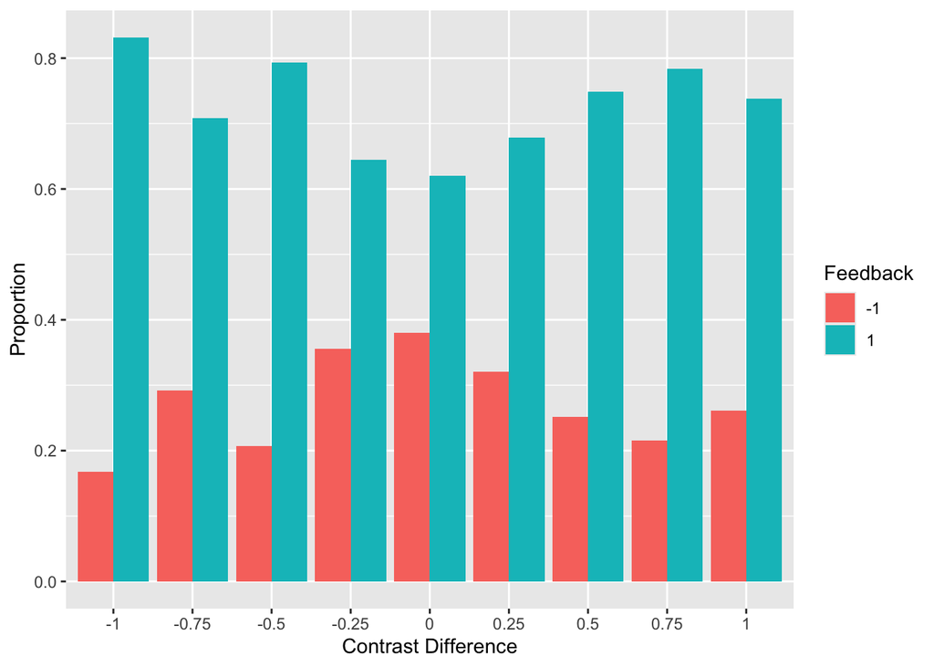

```r
results_df_allsessions$feedback <- as.factor(results_df_allsessions$feedback)
results_df_allsessions$contrastdiff <- as.factor(results_df_allsessions$contrastdiff)

# Compute proportions
results_allsessions_summary <- results_df_allsessions %>%
  group_by(contrastdiff, feedback) %>%
  summarise(count = n(), .groups = "drop") %>%
  group_by(contrastdiff) %>%
  mutate(prop = count / sum(count))  # Normalize by contrastdiff

# Plot using proportions
ggplot(results_allsessions_summary, aes(x = contrastdiff, y = prop, fill = feedback)) +
  geom_bar(stat = "identity", position = "dodge") +
  labs(x = "Contrast Difference", y = "Proportion", fill = "Feedback")
```

```r
results_brainarea_summary <- results_df_allsessions %>%
  group_by(contrastdiff, feedback, brain_area) %>%
  summarise(count = n(), .groups = "drop") %>%
  group_by(contrastdiff, brain_area) %>%
  mutate(prop = count / sum(count))  # Normalize by contrastdiff

results_allsessions_summary
```

```
## # A tibble: 18 × 4
## # Groups:   contrastdiff [9]
##    contrastdiff feedback count  prop
##    <fct>        <fct>    <int> <dbl>
##  1 -1           -1         752 0.168
##  2 -1           1         3719 0.832
##  3 -0.75        -1        1214 0.291
##  4 -0.75        1         2951 0.709
##  5 -0.5         -1        1127 0.207
##  6 -0.5         1         4316 0.793
##  7 -0.25        -1        1165 0.356
##  8 -0.25        1         2111 0.644
##  9 0            -1        6152 0.380
## 10 0            1        10024 0.620
## 11 0.25         -1        1159 0.321
## 12 0.25         1         2450 0.679
## 13 0.5          -1        1167 0.252
## 14 0.5          1         3472 0.748
## 15 0.75         -1         647 0.216
## 16 0.75         1         2350 0.784
## 17 1            -1        1150 0.262
## 18 1            1         3247 0.738
```

```r
results_brainarea_summary
```

```
## # A tibble: 1,078 × 5
## # Groups:   contrastdiff, brain_area [558]
##    contrastdiff feedback brain_area count   prop
##    <fct>        <fct>    <chr>      <int>  <dbl>
##  1 -1           -1       ACA           12 0.154
##  2 -1           -1       ACB            3 0.136
##  3 -1           -1       AUD            4 0.211
##  4 -1           -1       BLA            1 0.0333
##  5 -1           -1       CA1           63 0.209
##  6 -1           -1       CA3           23 0.135
##  7 -1           -1       CP             4 0.0615
##  8 -1           -1       DG            36 0.182
##  9 -1           -1       GPe           22 0.210
## 10 -1           -1       ILA            3 0.0909
## # ℹ 1,068 more rows
```

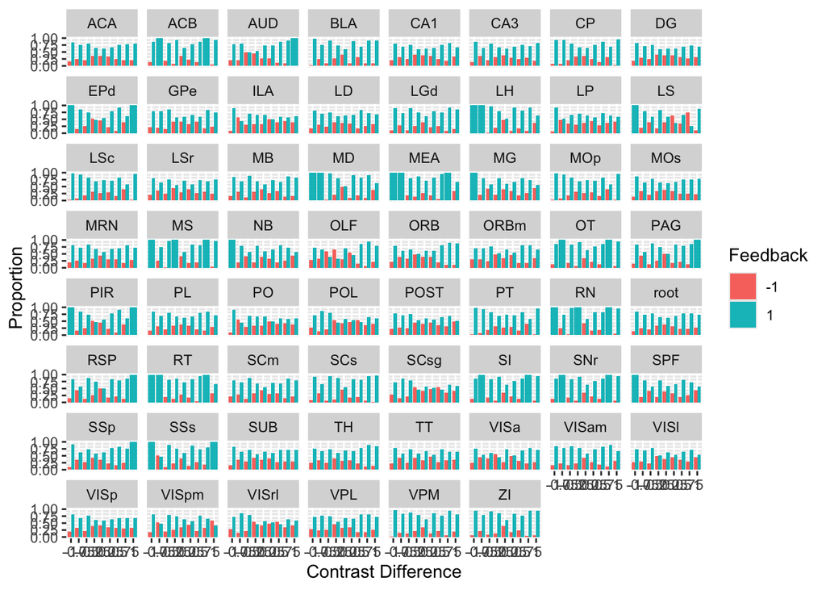

```r
ggplot(results_brainarea_summary, aes(x = contrastdiff, y = prop, fill = feedback)) +
  geom_bar(stat = "identity", position = "dodge") + facet_wrap(~brain_area) +
  labs(x = "Contrast Difference", y = "Proportion", fill = "Feedback")
```

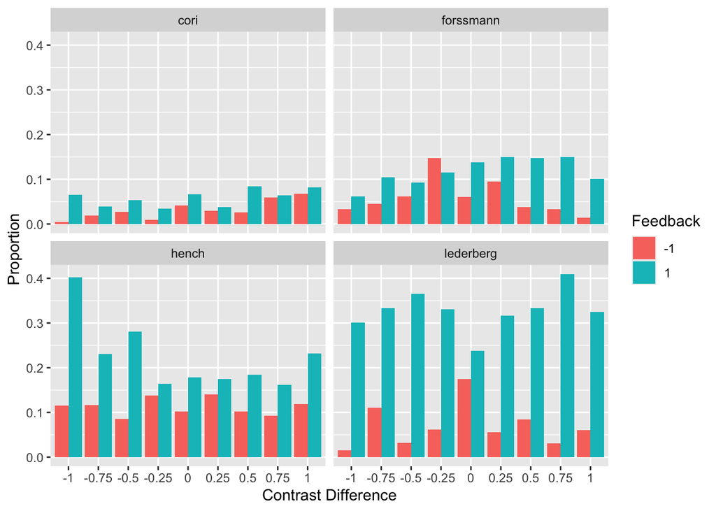

```r
results_mouse_summary <- results_df_allsessions %>%
  group_by(contrastdiff, feedback, mousename) %>%
  summarise(count = n(), .groups = "drop") %>%
  group_by(contrastdiff) %>%
  mutate(prop = count / sum(count))  # Normalize by contrastdiff

ggplot(results_mouse_summary, aes(x = contrastdiff, y = prop, fill = feedback)) +
  geom_bar(stat = "identity", position = "dodge") + facet_wrap(~mousename) +
  labs(x = "Contrast Difference", y = "Proportion", fill = "Feedback")
```

```r
df_diff <- results_allsessions_summary %>%
  group_by(contrastdiff) %>%
  summarise(prop_diff = diff(prop))  # Calculates difference between the two proportions

# Print the new dataframe
print(df_diff)
```

```
## # A tibble: 9 × 2
##   contrastdiff prop_diff
##   <fct>            <dbl>
## 1 -1               0.664
## 2 -0.75            0.417
## 3 -0.5             0.586
## 4 -0.25            0.289
## 5 0                0.239
## 6 0.25             0.358
## 7 0.5              0.497
## 8 0.75             0.568
## 9 1                0.477
```

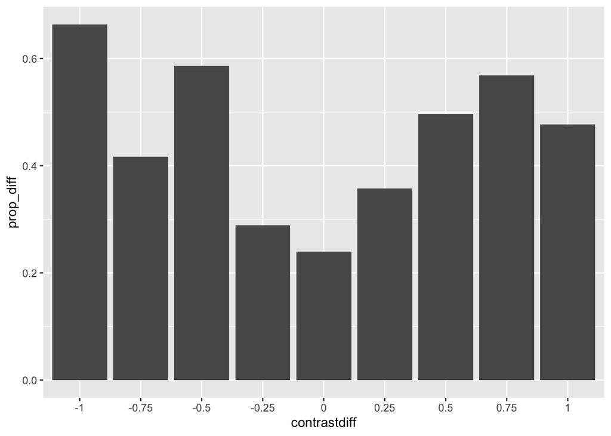

```r
ggplot(df_diff, mapping=aes(x=contrastdiff, y=prop_diff)) + geom_col()
```

This graph demonstrates there is a larger difference between the proportion of successes (1) versus proportion of failures (-1) in groups whith higher absolute contrastdiff values (such as -1 or 1) than ones with low absolute contrastdiff values (0). This shows us that contrast values within a trial seem to be correlated with mouse success. I will plan on including contrast values within my prediction model.

#AI Help Link to conversation with Claude AI, that assisted us in building and debugging the code for this project:

https://claude.ai/share/4e49ce8d-b92e-4672-96a1-979c87d995fe

https://claude.ai/share/c26b155b-ddd6-4916-bea2-add1a3e2bc6d

https://claude.ai/share/c71010bc-bd5d-4ebd-8b91-e1b6316d4fe4

https://claude.ai/share/ed884d0a-217e-487c-8c38-845e05797fc3